# Introdução ao R

# Exercícios 2

O *Internet Movie Database*, conhecido popularmente como IMDb, é uma base de dados de informação sobre cinema TV, música e games pertencente à Amazon. Vamos trabalhar com um arquivo que apresenta diversas informações de 1000 filmes. Para isso, temos que seguir dois passos: 1) salvar o arquivo em nosso computador e 2) importar o arquivo para dentro do R. Então vamos lá…

Baixe o arquivo imdb1000.rds e **salve-o na pasta que você está utilizando para as aulas do R**.

Agora é necessário importar o arquivo `imdb.rds` para dentro do R, salvando-o como imdb. Para isso, use o código de importação abaixo:

```r
imdb1000 <- readRDS("imdb1000.rds")
# OBS: Esse código só irá funcionar se o arquivo estiver salvo na pasta em que vc está trabalhando.
```

Quantas linhas e colunas tem o dataframe imdb?

```r
str(imdb1000)
```

```
## 'data.frame':    1000 obs. of  18 variables:
##  $ Poster_Link  : chr  "https://m.media-amazon.com/images/M/MV5BMDFkYTc0MGEtZmNhMC00ZDIzLWFmNTEtODM1ZmRlYWMwMWFmXkEyXkFqcGdeQXVyMTMxODk"| __truncated__ "https://m.media-amazon.com/images/M/MV5BM2MyNjYxNmUtYTAwNi00MTYxLWJmNWYtYzZlODY3ZTk3OTFlXkEyXkFqcGdeQXVyNzkwMjQ"| __truncated__ "https://m.media…
##  $ Series_Title : chr  "The Shawshank Redemption" "The Godfather" "The Dark Knight" "The Godfather: Part II" ...
##  $ Released_Year: chr  "1994" "1972" "2008" "1974" ...
##  $ Certificate  : chr  "A" "A" "UA" "A" ...
##  $ Runtime      : chr  "142 min" "175 min" "152 min" "202 min" ...
##  $ Genre1       : chr  "Drama" "Crime" "Action" "Crime" ...
##  $ Genre2       : chr  NA " Drama" " Crime" " Drama" ...
##  $ Genre3       : chr  NA NA " Drama" NA ...
##  $ IMDB_Rating  : num  9.3 9.2 9 9 9 8.9 8.9 8.9 8.8 8.8 ...
##  $ Overview     : chr  "Two imprisoned men bond over a number of years, finding solace and eventual redemption through acts of common decency." "An organized crime dynasty's aging patriarch transfers control of his clandestine empire to his reluctant son." "When the menace known as the Joker wrea…
##  $ Meta_score   : int  80 100 84 90 96 94 94 94 74 66 ...
##  $ Director     : chr  "Frank Darabont" "Francis Ford Coppola" "Christopher Nolan" "Francis Ford Coppola" ...
##  $ Star1        : chr  "Tim Robbins" "Marlon Brando" "Christian Bale" "Al Pacino" ...
##  $ Star2        : chr  "Morgan Freeman" "Al Pacino" "Heath Ledger" "Robert De Niro" ...
##  $ Star3        : chr  "Bob Gunton" "James Caan" "Aaron Eckhart" "Robert Duvall" ...
##  $ Star4        : chr  "William Sadler" "Diane Keaton" "Michael Caine" "Diane Keaton" ...
##  $ No_of_Votes  : int  2343110 1620367 2303232 1129952 689845 1642758 1826188 1213505 2067042 1854740 ...
##  $ Gross        : chr  "28,341,469" "134,966,411" "534,858,444" "57,300,000" ...
```

```r
nrow(imdb1000)
```

```
## [1] 1000
```

```r
ncol(imdb1000)
```

```
## [1] 18
```

Mostre os filmes desse banco de dados foram dirigidos por Woody Allen?

```r
imdb1000[imdb1000$Director == "Woody Allen",c("Series_Title","Director")]
```

```
##                 Series_Title    Director
## 415               Annie Hall Woody Allen
## 527  Crimes and Misdemeanors Woody Allen
## 529   Hannah and Her Sisters Woody Allen
## 534                Manhattan Woody Allen
## 744        Midnight in Paris Woody Allen
## 836 The Purple Rose of Cairo Woody Allen
## 838                    Zelig Woody Allen
## 847           Love and Death Woody Allen
## 930              Match Point Woody Allen
```

Exiba um dataframe que mostra os títulos dos filmes dirigidos por Steven Spielberg que foram lançados até o ano 2000?

```r
imdb1000[imdb1000$Director == "Steven Spielberg" & imdb1000$Released_Year <= 2000,
     c("Released_Year","Director","Series_Title")]
```

```
##     Released_Year         Director                       Series_Title
## 8            1993 Steven Spielberg                   Schindler's List
## 25           1998 Steven Spielberg                Saving Private Ryan
## 73           1981 Steven Spielberg            Raiders of the Lost Ark
## 169          1989 Steven Spielberg Indiana Jones and the Last Crusade
## 263          1993 Steven Spielberg                      Jurassic Park
## 416          1975 Steven Spielberg                               Jaws
## 683          1985 Steven Spielberg                   The Color Purple
## 689          1982 Steven Spielberg         E.T. the Extra-Terrestrial
## 833          1987 Steven Spielberg                  Empire of the Sun
## 989          1977 Steven Spielberg Close Encounters of the Third Kind
```

Exiba um dataframe que mostre os titulos dos filmes dirigidos por Steven Spielberg ou James Cameron, que são do gênero drama ou ação **(Somente em Genre1)**.

```r
imdb1000[(imdb1000$Director == "James Cameron" | imdb1000$Director == "Steven Spielberg") & (imdb1000$Genre1 == "Drama" | imdb1000$Genre1 == "Action"), c("Series_Title","Genre1","Director")]
```

```
##                           Series_Title Genre1         Director
## 25                 Saving Private Ryan  Drama Steven Spielberg
## 45          Terminator 2: Judgment Day Action    James Cameron
## 73             Raiders of the Lost Ark Action Steven Spielberg
## 107                             Aliens Action    James Cameron
## 169 Indiana Jones and the Last Crusade Action Steven Spielberg
## 263                      Jurassic Park Action Steven Spielberg
## 411                     The Terminator Action    James Cameron
## 624                             Avatar Action    James Cameron
## 653                            Titanic  Drama    James Cameron
## 683                   The Color Purple  Drama Steven Spielberg
## 833                  Empire of the Sun Action Steven Spielberg
## 891                    Bridge of Spies  Drama Steven Spielberg
## 952                    Minority Report Action Steven Spielberg
## 989 Close Encounters of the Third Kind  Drama Steven Spielberg
```

Renomeie as variáveis, traduzindo-as para o português.

```r
imdb1000 <-
rename(imdb1000,c(título = "Series_Title",
              lançamento = "Released_Year",
              certificado = "Certificate",
              duração = "Runtime",
              gênero1 = "Genre1",
              gênero2 = "Genre2",
              gênero3 = "Genre3",
              imdb = "IMDB_Rating",
              meta_escore = "Meta_score",
              diretor = "Director",
              ator1 = "Star1",
              ator2 = "Star2",
              ator3 = "Star3",
              ator4 = "Star4",
              votos = "No_of_Votes",
              custo = "Gross"))
```

Vamos fazer mais alguns exercícios com um banco de dados sobre a população mundial. Salve o arquivo [world_populations.csv](https://1drv.ms/u/s!ApvtT9NG4aYok61vBm-Wnr5PWATIWA?e=Skesjw) no diretório que você está utilizando para esta disciplina. Em seguida, importe esse banco de dados para dentro do R usando o código abaixo:

```r
# Importar banco de dados de um arquivo .csv para um dataframe no R chamado world_population

# Note que, neste caso, estamos usando a função read.csv() porque o arquivo está no formato .csv (informações separadas por vírgulas)
wp <- read.csv("world_population.csv", encoding = "UTF-8")
# wp_copia <- wp
```

Crie um dataframe chamado `wp1` que permita identificar as capitais de todos os países da América do Sul (países e capitais)

```r
wp1 <- wp[wp$Continent == "South America",3:4]
```

Para colocar a coluna “Country” em ordem alfabética, podemos usar a função `order()` dentro dos colchetes. Veja:

```r
wp1[order(wp1$Country),]
```

```
##              Country      Capital
## 9          Argentina Buenos Aires
## 25           Bolivia        Sucre
## 28            Brazil     Brasilia
## 41             Chile     Santiago
## 43          Colombia       Bogota
## 57           Ecuador        Quito
## 65  Falkland Islands      Stanley
## 70     French Guiana      Cayenne
## 87            Guyana   Georgetown
## 162         Paraguay     Asunción
## 163             Peru         Lima
## 200         Suriname   Paramaribo
## 224          Uruguay   Montevideo
## 228        Venezuela      Caracas
```

Selecione informações do dataframe wp que permita comparar os casos de Brazil, China, Rússia e Índia quanto às seguintes variáveis: população em 2020, densidade por km<sup>2</sup>, taxa de crescimento e porcentagem da população mundial. Salve essa seleção em um novo objeto chamado wp2.

```r
names(wp)
```

```
##  [1] "Rank"                        "CCA3"
##  [3] "Country"                     "Capital"
##  [5] "Continent"                   "X2022.Population"
##  [7] "X2020.Population"            "X2015.Population"
##  [9] "X2010.Population"            "X2000.Population"
## [11] "X1990.Population"            "X1980.Population"
## [13] "X1970.Population"            "Area..km²."
## [15] "Density..per.km²."           "Growth.Rate"
## [17] "World.Population.Percentage"
```

```r
wp2 <-
wp[wp$Country == "Brazil" | wp$Country == "China" | wp$Country == "Russia" | wp$Country == "India",c(3,7,15:17)]
```

Ordene o dataframe wp2 pelas suas variáveis. Dica, você pode usar o argumento `decreasing = TRUE` dentro da função `order()` para ordenar a coluna de forma decrescente. Teste essa possibilidade.

```r
wp2[order(wp2$Country),]
```

```
##     Country X2020.Population Density..per.km². Growth.Rate
## 28   Brazil        213196304           25.2841      1.0046
## 42    China       1424929781          146.8933      1.0000
## 93    India       1396387127          431.0675      1.0068
## 172  Russia        145617329            8.4636      0.9973
##     World.Population.Percentage
## 28                         2.70
## 42                        17.88
## 93                        17.77
## 172                        1.81
```

```r
wp2[order(wp2$X2020.Population, decreasing = TRUE),]
```

```
##     Country X2020.Population Density..per.km². Growth.Rate
## 42    China       1424929781          146.8933      1.0000
## 93    India       1396387127          431.0675      1.0068
## 28   Brazil        213196304           25.2841      1.0046
## 172  Russia        145617329            8.4636      0.9973
##     World.Population.Percentage
## 42                        17.88
## 93                        17.77
## 28                         2.70
## 172                        1.81
```

```r
wp2[order(wp2$`Density..per.km².`, decreasing = TRUE),]
```

```
##     Country X2020.Population Density..per.km². Growth.Rate
## 93    India       1396387127          431.0675      1.0068
## 42    China       1424929781          146.8933      1.0000
## 28   Brazil        213196304           25.2841      1.0046
## 172  Russia        145617329            8.4636      0.9973
##     World.Population.Percentage
## 93                        17.77
## 42                        17.88
## 28                         2.70
## 172                        1.81
```

```r
wp2[order(wp2$Growth.Rate, decreasing = TRUE),]
```

```
##     Country X2020.Population Density..per.km². Growth.Rate
## 93    India       1396387127          431.0675      1.0068
## 28   Brazil        213196304           25.2841      1.0046
## 42    China       1424929781          146.8933      1.0000
## 172  Russia        145617329            8.4636      0.9973
##     World.Population.Percentage
## 93                        17.77
## 28                         2.70
## 42                        17.88
## 172                        1.81
```

```r
wp2[order(wp2$World.Population.Percentage, decreasing = TRUE),]
```

```
##     Country X2020.Population Density..per.km². Growth.Rate
## 42    China       1424929781          146.8933      1.0000
## 93    India       1396387127          431.0675      1.0068
## 28   Brazil        213196304           25.2841      1.0046
## 172  Russia        145617329            8.4636      0.9973
##     World.Population.Percentage
## 42                        17.88
## 93                        17.77
## 28                         2.70
## 172                        1.81
```

## Importar e Combinar dataframes

```r
# Juntar a planilha importada no dataframe df
saveRDS(df,"df.rds")
df <- cbind(df,variables)
```

## Lidando com dados ausentes

A função `na.omit` deleta as informações de uma linha inteira que contenha ao menos uma informação ausente.

```r
na.omit(df)
```

```
##   id      sexo idade escolaridade estado_civil renda bonus renda_total v1 v2 v3
## 1 s1 masculino    25     superior     casado/a  1000   500        1500  2  4  1
## 2 s2  feminino    32        médio   solteiro/a  1500   500        2000  4  5  3
## 3 s3 masculino    78  fundamental      viúvo/a  2000   500        2500  3  3  2
## 4 s4 masculino    12  fundamental   solteiro/a  2500   500        3000  5  5  4
## 6 s6 masculino    34     superior     casado/a  3500   500        4000  2  1  3
##   v4 v5
## 1  5  3
## 2  1  2
## 3  3  4
## 4  2  1
## 6  1  3
```

```r
na.exclude(df)
```

```
##   id      sexo idade escolaridade estado_civil renda bonus renda_total v1 v2 v3
## 1 s1 masculino    25     superior     casado/a  1000   500        1500  2  4  1
## 2 s2  feminino    32        médio   solteiro/a  1500   500        2000  4  5  3
## 3 s3 masculino    78  fundamental      viúvo/a  2000   500        2500  3  3  2
## 4 s4 masculino    12  fundamental   solteiro/a  2500   500        3000  5  5  4
## 6 s6 masculino    34     superior     casado/a  3500   500        4000  2  1  3
##   v4 v5
## 1  5  3
## 2  1  2
## 3  3  4
## 4  2  1
## 6  1  3
```

Uma outra forma de lidar com dados ausentes (NA) é através de um argumento que geralmente é utilizado dentro de funções estatísticas ou gráficos para sinalizar que os valores NA devem ser ignorados. Esse argumento é o `na.rm`, que é um argumento lógico, ou seja deve ser apresentado como `na.rm = TRUE` ou `na.rm = FALSE`. Veja a aplicação desse argumento na função `mean()`, utilizada para calcular médias.

```r
# mean(df$idade)    # essa função acaba não rodando, porque entre os dados de idade existe um NA
mean(df$idade, na.rm = TRUE) # dessa forma, conseguimos rodar a análise.
```

```
## [1] 36.2
```

# Função `ifelse()`

A função `ifelse()` é bastante útil para a manipulação de dados. Ela deve ser escrita da seguinte forma: `ifelse("condição", "se sim", "se não")` Traduzindo: observe a condição… se ela ocorrer, faça isso… se ela não ocorrer, faça aquilo. Exemplos:

```r
# se quisermos classificar a renda em dois grupos: menor igual a R$2000 e maior que R$2000, podemos usar a função ifelse()
# ifelse(condição,se sim, se não)
# traduzindo....
# observe se, na variável renda, o valor é menor ou igual a 2000
# se for, então atribua 1
# se não for, então atribua 2.

ifelse(df$renda <= 2000,1,2)
```

```
## [1] 1 1 1 2 2 2
```

```r
# Se quisermos salvar esses dados como uma coluna do df...
df$renda_cod <- ifelse(df$renda <= 2000,1,2)

# se quisermos criar uma coluna atribuindo 1 para homens e 0 para os demais.
ifelse(df$sexo == "masculino",1,0)
```

```
## [1] 1 0 1 1 0 1
```

```r
# se quisermos identificar homens com escolaridade fundamental
ifelse(df$sexo == "masculino" & df$escolaridade == "fundamental",1,0)
```

```
## [1] 0 0 1 1 0 0
```

```r
# se quisermos identificar homens com escolaridade fundamental OU pessoa casadas.
ifelse(df$sexo == "masculino" & df$escolaridade == "fundamental" | df$estado_civil == "casado/a",1,0)
```

```
## [1] 1 0 1 1 1 1
```

```r
# se quisermos criar uma nova variável atribuindo 1 para solteiro, 2 para casado e 3 para viúvo... tínhamos visto o formato

#df$escolaridade[df$escolaridade == "fundamental"] <- 1
#df$escolaridade[df$escolaridade == "médio"] <- 2
#df$escolaridade[df$escolaridade == "superior"] <- 3

df$escola_cod <- ifelse(df$escolaridade == "fundamental",1,
                        ifelse(df$escolaridade == "médio",2,3))

ifelse(df$v1 == 1,5,
       ifelse(df$v1 == 2,4,
              ifelse(df$v1 == 3,3,
                     ifelse(df$v1 == 4,2,1))))
```

```
## [1] 4 2 3 1 5 4
```

```r
# Também é possível recodificar variáveis de jeito mais fácil, usando uma função do pacote expss.
# Note que há questões no sentido de uma boa adaptação aos estudos e frases no sentido contrário. Nesses casos, não podemos somar os itens diretamente porque um valor 5 em v1 significa má adaptação, enquanto o mesmo valor 5  significa boa adaptação em v2. Então, não podemos somar coisas que têm significados diferentes.
# Para lidar com isso, geralmente, fazemos a inversão de itens que estão na direção contrária do que queremos avaliar. Por exemplo, se queremos avaliar "adaptação escolar", então invertemos os itens v1 e v5, que estão na direção contrária.
# Inverter significa transformar 1 em 5, 2 em 4, 3 em 3, 4 em 2 e 5 em 1.
# Para isso, usamos a função recode() do expss.

recode(df[ ,c("v1","v2","v3","v4","v5")]) <- c(1~5,2~4,3~3,4~2,5~1)
recode(df[ ,c("v1","v5")]) <- c(1~5,2~4,3~3,4~2,5~1)
```

# Exercícios 3

### Importar arquivo do Excel para o R

Nesta atividade, nós vamos um banco de dados público, que contém algumas informações sobre os respondentes e 50 itens de um teste de personalidade.

Os itens estão na seguinte ordem: extroversão (E), neuroticismo (N), amabilidade (A), conscienciosidade (C) e Abertura (O).

Copie o arquivo big_five.xlsx para a pasta de trabalho que você está usando para esta disciplina.

Esse é um banco de dados estrangeiro, está codificado no sistema europeu.

Use a função `read_excel()` do pacote `readxl` para importá-lo e salve-o como um objeto do R chamado `big_five`.

Dentro dos parênteses informamos o nome do arquivo, entre aspas e com a extensão. Veja…

```r
# Você deve ter instalado o pacote readxl em nossa última aula.
# se ainda não instalou, instale-o utilizando o comando install.packages("readxl")
# Depois, não se esqueça de ativar o pacote com a função library(readxl)

big_five <- read_excel("big_five.xlsx")

# ao rodar o comando, o arquivo será importando e salvo como dataframe no R. Você verá um objeto com esse nome, no quadro superior à direita.
```

### Informações sobre o banco de dados

O banco de dados utilizado neste exercício (baixado da internet) foram coletados (c. 2012) por meio de um teste de personalidade online interativo. Os itens foram avaliados em uma escala de cinco pontos, em que 1 = Discordo, 3 = Neutro, 5 = Concordo (0 = não respondido). Os itens foram os seguintes:

E1 - I am the life of the party.

E2 - I don’t talk a lot.

E3 - I feel comfortable around people.

E4 - I keep in the background.

E5 - I start conversations.

E6 - I have little to say.

E7 - I talk to a lot of different people at parties.

E8 - I don’t like to draw attention to myself.

E9 - I don’t mind being the center of attention.

E10 - I am quiet around strangers.

N1 - I get stressed out easily.

N2 - I am relaxed most of the time.

N3 - I worry about things.

N4 - I seldom feel blue.

N5 - I am easily disturbed.

N6 - I get upset easily.

N7 - I change my mood a lot.

N8 - I have frequent mood swings.

N9 - I get irritated easily.

N10 - I often feel blue.

A1 - I feel little concern for others.

A2 - I am interested in people.

A3 - I insult people.

A4 - I sympathize with others’ feelings.

A5 - I am not interested in other people’s problems.

A6 - I have a soft heart.

A7 - I am not really interested in others.

A8 - I take time out for others.

A9 - I feel others’ emotions.

A10 - I make people feel at ease.

C1 - I am always prepared.

C2 - I leave my belongings around.

C3 - I pay attention to details.

C4 - I make a mess of things.

C5 - I get chores done right away.

C6 - I often forget to put things back in their proper place.

C7 - I like order.

C8 - I shirk my duties.

C9 - I follow a schedule.

C10 - I am exacting in my work.

O1 - I have a rich vocabulary.

O2 - I have difficulty understanding abstract ideas.

O3 - I have a vivid imagination.

O4 - I am not interested in abstract ideas.

O5 - I have excellent ideas.

O6 - I do not have a good imagination.

O7 - I am quick to understand things.

O8 - I use difficult words.

O9 - I spend time reflecting on things.

O10 - I am full of ideas.

**race** (raça): Foi escolhida pelos participantes em um menu suspenso.

0 = Dados perdidos

1 = Raça Mista

2 = Ártico (Siberiano, Esquimó)

3 = Caucasiano (Europeu)

4 = Caucasiano (Indiano)

5 = Caucasiano (Médio Leste)

6 = Caucasiano (Norte Africano, Outro)

7 = Indígena Australiano

8 = Nativo Americano

9 = Nordeste Asiático (Mongol, Tibetano, Japonês Coreano, etc)

10 = Pacífico (Polinésia, Micronésia, etc.)

11 = Sudeste Asiático (Chinês, Tailandês, Malaio, Filipino, etc.)

12 = Oeste da África, Bosquímanos, Etíope

13 = Outro

**age**: inserida como texto (indivíduos que relataram idade <13 anos não foram registrados)

**engnat**: Resposta a “o inglês é sua língua nativa?”: 0 = dados perdidos, 1 = sim, 2 = não

**gender**: Escolhido em um menu suspenso. 0 = dados perdidos, 1 = Masculino, 2 = Feminino, 3 = Outro

**hand**: “Com que mão você escreve?”. 0 = dados perdidos, 1 = Direita, 2 = Esquerda, 3 = Ambos

**country**: Código ISO do país.

**source**: Como o participante soube do teste. 1 = de outra página no site de teste 2 = do google 3 = do facebook 4 = de qualquer url com “.edu” em seu nome de domínio (por exemplo, xxx.edu, xxx.edu.au), 5 = não informado no arquivo 6 = outra fonte ou HTTP Referer não fornecido.

1. Visualise o banco de dados com as funções names() e view() para checar se tudo foi importado corretamente.

```r
big_five_cópia <- big_five
names(big_five)
```

```
##  [1] "race"    "age"     "engnat"  "gender"  "hand"    "source"  "country"
##  [8] "E1"      "E2"      "E3"      "E4"      "E5"      "E6"      "E7"
## [15] "E8"      "E9"      "E10"     "N1"      "N2"      "N3"      "N4"
## [22] "N5"      "N6"      "N7"      "N8"      "N9"      "N10"     "A1"
## [29] "A2"      "A3"      "A4"      "A5"      "A6"      "A7"      "A8"
## [36] "A9"      "A10"     "C1"      "C2"      "C3"      "C4"      "C5"
## [43] "C6"      "C7"      "C8"      "C9"      "C10"     "O1"      "O2"
## [50] "O3"      "O4"      "O5"      "O6"      "O7"      "O8"      "O9"
## [57] "O10"
```

```r
str(big_five)
```

```
## tibble [19,719 x 57] (S3: tbl_df/tbl/data.frame)
##  $ race   : num [1:19719] 3 13 1 3 11 13 5 4 5 3 ...
##  $ age    : num [1:19719] 53 46 14 19 25 31 20 23 39 18 ...
##  $ engnat : num [1:19719] 1 1 2 2 2 1 1 2 1 1 ...
##  $ gender : num [1:19719] 1 2 2 2 2 2 2 1 2 2 ...
##  $ hand   : num [1:19719] 1 1 1 1 1 1 1 1 3 1 ...
##  $ source : num [1:19719] 1 1 1 1 2 2 5 2 4 5 ...
##  $ country: chr [1:19719] "US" "US" "PK" "RO" ...
##  $ E1     : num [1:19719] 4 2 5 2 3 1 5 4 3 1 ...
##  $ E2     : num [1:19719] 2 2 1 5 1 5 1 3 1 4 ...
##  $ E3     : num [1:19719] 5 3 1 2 3 2 5 5 5 2 ...
##  $ E4     : num [1:19719] 2 3 4 4 3 4 1 3 1 5 ...
##  $ E5     : num [1:19719] 5 3 5 3 3 1 5 5 5 2 ...
##  $ E6     : num [1:19719] 1 3 1 4 1 3 1 1 1 4 ...
##  $ E7     : num [1:19719] 4 1 1 3 3 2 5 4 5 1 ...
```

[output cut: 43 more lines]

2. Quantas variáveis existem no banco de dados?

```r
ncol(big_five)
```

```
## [1] 57
```

3. Quantos sujeitos constam no banco de dados?

```r
nrow(big_five)
```

```
## [1] 19719
```

4. Como as variáveis estão codificadas no banco de dados (character, numeric, factor, etc…)? Obs: uma variável numérica pode estar como número inteiro (int) ou como número decimal (dbl).

```r
str(big_five)
```

```
## tibble [19,719 x 57] (S3: tbl_df/tbl/data.frame)
##  $ race   : num [1:19719] 3 13 1 3 11 13 5 4 5 3 ...
##  $ age    : num [1:19719] 53 46 14 19 25 31 20 23 39 18 ...
##  $ engnat : num [1:19719] 1 1 2 2 2 1 1 2 1 1 ...
##  $ gender : num [1:19719] 1 2 2 2 2 2 2 1 2 2 ...
##  $ hand   : num [1:19719] 1 1 1 1 1 1 1 1 3 1 ...
##  $ source : num [1:19719] 1 1 1 1 2 2 5 2 4 5 ...
##  $ country: chr [1:19719] "US" "US" "PK" "RO" ...
##  $ E1     : num [1:19719] 4 2 5 2 3 1 5 4 3 1 ...
##  $ E2     : num [1:19719] 2 2 1 5 1 5 1 3 1 4 ...
##  $ E3     : num [1:19719] 5 3 1 2 3 2 5 5 5 2 ...
##  $ E4     : num [1:19719] 2 3 4 4 3 4 1 3 1 5 ...
##  $ E5     : num [1:19719] 5 3 5 3 3 1 5 5 5 2 ...
##  $ E6     : num [1:19719] 1 3 1 4 1 3 1 1 1 4 ...
##  $ E7     : num [1:19719] 4 1 1 3 3 2 5 4 5 1 ...
```

[output cut: 43 more lines]

5. Renomeie as variáveis, traduzindo-as para o português: raça = race, idade = age, ing_nat = engnat, gênero = gender, mão_dom = hand, fonte = source, país = country. Salve essa modificação no dataframe *big_five*.

```r
big_five <- rename(big_five,c(raça = race, idade = age, ing_nat = engnat, gênero = gender, mão_dom = hand, fonte = source, país = country))
```

6. Crie uma coluna **id** para identificar os sujeitos com um “s” seguido do número do sujeito. Por exemplo, s1, s2, s3… sn. Posicione essa coluna como a primeira do banco de dados.

```r
# para não ter que reordenar as variáveis depois que id estiver no final do dataframe, pode-se criar um vetor com os ids e depois fazer um cbind com o big_five.

id <- paste("s",1:nrow(big_five),sep = "")
big_five <- cbind(id,big_five)

# essa função do dplyr reloca colunas para o início do dataframe
# big_five %>% relocate(id) %>% names()
```

```r
str(big_five)
```

```
## 'data.frame':    19719 obs. of  58 variables:
##  $ id     : chr  "s1" "s2" "s3" "s4" ...
##  $ raça   : num  3 13 1 3 11 13 5 4 5 3 ...
##  $ idade  : num  53 46 14 19 25 31 20 23 39 18 ...
##  $ ing_nat: num  1 1 2 2 2 1 1 2 1 1 ...
##  $ gênero : num  1 2 2 2 2 2 2 1 2 2 ...
##  $ mão_dom: num  1 1 1 1 1 1 1 1 3 1 ...
##  $ fonte  : num  1 1 1 1 2 2 5 2 4 5 ...
##  $ país   : chr  "US" "US" "PK" "RO" ...
##  $ E1     : num  4 2 5 2 3 1 5 4 3 1 ...
##  $ E2     : num  2 2 1 5 1 5 1 3 1 4 ...
##  $ E3     : num  5 3 1 2 3 2 5 5 5 2 ...
##  $ E4     : num  2 3 4 4 3 4 1 3 1 5 ...
##  $ E5     : num  5 3 5 3 3 1 5 5 5 2 ...
##  $ E6     : num  1 3 1 4 1 3 1 1 1 4 ...
```

[output cut: 44 more lines]

```r
big_five$raça <- as.factor(big_five$raça)
big_five$ing_nat <- as.factor(big_five$ing_nat)
big_five$gênero <- as.factor(big_five$gênero)
big_five$mão_dom <- as.factor(big_five$mão_dom)
big_five$"país" <- as.factor(big_five$"país")
```

8. Agora é necessário atribuir os níveis de cada variável que foi transformada em fator. Os níveis para cada variável estão descritos no início deste documento. Lembrete: os níveis têm que ser atribuídos na mesma ordem dos valores. Por exemplo, na variável *gênero* o número 1 foi atribuído a *Masculino*, 2 a *Feminino* e 3 a *Outros.* Além disso, o valor 0 foi atribuído a respostas faltantes. Essas precisam ser transformadas em NA no R. Portanto, temos 0, 1, 2 e 3 no banco de dados, e os nomes desses níveis devem aparecer nessa ordem na linha de comando dessa variável.

```r
levels(big_five$raça) <- c(NA,
                           "Raça Mista",
                           "Ártico (Siberiano, Esquimó)",
                           "Caucasiano (Europeu)",
                           "Caucasiano (Indiano)",
                           "Caucasiano (Médio Leste)",
                           "Caucasiano (Norte Africano, Outro)",
                           "Indígena Australiano",
                           "Nativo Americano",
                           "Nordeste Asiático (Mongol, Tibetano, Japonês Coreano, etc)",
                           "Pacífico (Polinésia, Micronésia, etc.)",
                           "Sudeste Asiático (Chinês, Tailandês, Malaio, Filipino, etc.)",
                           "Oeste da África, Bosquímanos, Etíope",
                           "Outro"
                           )
```

```r
levels(big_five$ing_nat) <- c(NA,"Sim","Não")
#factor(big_five$ing_nat, levels = c(0,1,2), labels = c(NA,"Sim","Não"))
```

```r
levels(big_five$gênero) <- c(NA,"Masculino","Feminino","Outro")
```

```r
levels(big_five$mão_dom) <- c(NA,"Direita","Esquerda","Ambas")
```

9. Rode a função `count(big_five,idade)` para contar quantas pessoas de cada idade há no banco de dados. Observe se há algo estranho.
10. Selecione apenas os participantes com idades até 80 anos (inclusive) e provenientes dos Estados Unidos (US). Salve esses participantes em um novo dataframe chamado **bf80us**.

```r
bf80us <- big_five[c(big_five$idade <= 80 & big_five$país == "US"), ]
```

11. Quantos sujeitos compõem esse novo banco de dados?

```r
nrow(bf80us)
```

```
## [1] 8730
```

12. Exporte o scritp deste exercício no formato `.rds` usando a função `saveRDS(nome_do_dataframe,"nome_do_arquivo.rds")` e envie o arquivo pelo google classroom para cumprir a atividade desta semana.

```r
saveRDS(bf80us,"bf80us.rds")
```

13. Voltando a trabalhar com o dataframe `big_five`, criar uma nova variável chamada faixa_etária com as seguintes faixas: até 20 anos (1), de 21 a 30 (2), 31 a 40 (3), 41 a 50 (4), 51 a 60 (5), 61 a 70 (6), 71 a 80 (7) e atribua NA para valores superiores a 80. Salve essa nova variável no dataframe big_five.

```r
big_five$faixa_etária <- ifelse(big_five$idade <= 20, 1,
                         ifelse(big_five$idade > 20 & big_five$idade <= 30,2,
                         ifelse(big_five$idade > 30 & big_five$idade <= 40,3,
                         ifelse(big_five$idade > 40 & big_five$idade <= 50,4,
                         ifelse(big_five$idade > 50 & big_five$idade <= 60,5,
                         ifelse(big_five$idade > 60 & big_five$idade <= 70,6,
                         ifelse(big_five$idade > 70 & big_five$idade <= 80,7,NA)))))))
str(big_five)
```

```
## 'data.frame':    19719 obs. of  59 variables:
##  $ id          : chr  "s1" "s2" "s3" "s4" ...
##  $ raça        : Factor w/ 13 levels "Raça Mista","Ártico (Siberiano, Esquimó)",..: 3 13 1 3 11 13 5 4 5 3 ...
##  $ idade       : num  53 46 14 19 25 31 20 23 39 18 ...
##  $ ing_nat     : Factor w/ 2 levels "Sim","Não": 1 1 2 2 2 1 1 2 1 1 ...
##  $ gênero      : Factor w/ 3 levels "Masculino","Feminino",..: 1 2 2 2 2 2 2 1 2 2 ...
##  $ mão_dom     : Factor w/ 3 levels "Direita","Esquerda",..: 1 1 1 1 1 1 1 1 3 1 ...
##  $ fonte       : num  1 1 1 1 2 2 5 2 4 5 ...
##  $ país        : Factor w/ 159 levels "(nu","A1","A2",..: 150 150 121 128 150 150 150 72 150 150 ...
##  $ E1          : num  4 2 5 2 3 1 5 4 3 1 ...
##  $ E2          : num  2 2 1 5 1 5 1 3 1 4 ...
##  $ E3          : num  5 3 1 2 3 2 5 5 5 2 ...
##  $ E4          : num  2 3 4 4 3 4 1 3 1 5 ...
##  $ E5          : num  5 3 5 3 3 1 5 5 5 2 ...
##  $ E6          : num  1 3 1 4 1 3 1 1 1 4 ...
```

[output cut: 45 more lines]

14. Nos cinco fatores desse instrumento, há itens na direção do fator e itens no sentido inverso. Por exemplo, na escala de extroversão há itens como *“I am the life of the party”*, que descreve uma pessoa extrovertida, e itens como *“I don’t talk a lot”*, que descreve uma pessoa introvertida. Esse problema precisa ser resolvido antes de calcularmos os escores das pessoas nesse fator. Se as pessoas responderam esses itens usando uma escala Likert de 5 pontos, não podemos somar os valores desses itens diretamente porque eles têm significados diferentes. Por exemplo, se uma pessoa atribuiu valor 5 ao item *“I am the life of the party”*, esse 5 indica que ela é muito **ex**trovertida. Mas o mesmo valor 5 atribuído ao item *“I don’t talk a lot”* indica que a pessoa é muito **in**trovertida. Portanto, temos um problema porque o mesmo valor (5) significa coisas diferentes em itens diferentes. Para evitarmos esse problema temos que inverter os valores dos itens que vão na direção da introversão, mudar o 1 para 5, o 2 para 4, o 3 permanece 3, o 4 para 2 e o 5 para 1.

Faça essas alterações usando a função `ifelse()` para os itens invertidos do fator Exgtroversão e a `recode()` para os itens invertidos dos demais fatores ()

```r
library(expss)

# uma solução seria usar ifelse
#big_five$E2_mod <-
ifelse(big_five$E2 == 1,5,ifelse(big_five$E2 == 2,4,ifelse(big_five$E2 == 3,3,ifelse(big_five$E2 == 4,2,ifelse(big_five$E2 == 5,1,NA)))))
```

[output not shown]

[output cut: 807 more lines]

```r
ifelse(big_five$E4 == 1,5,ifelse(big_five$E4 == 2,4,ifelse(big_five$E4 == 3,3,ifelse(big_five$E4 == 4,2,ifelse(big_five$E4 == 5,1,NA)))))
```

[output not shown]

[output cut: 807 more lines]

```r
ifelse(big_five$E6 == 1,5,ifelse(big_five$E6 == 2,4,ifelse(big_five$E6 == 3,3,ifelse(big_five$E6 == 4,2,ifelse(big_five$E6 == 5,1,NA)))))
```

[output not shown]

[output cut: 807 more lines]

```r
ifelse(big_five$E8 == 1,5,ifelse(big_five$E8 == 2,4,ifelse(big_five$E8 == 3,3,ifelse(big_five$E8 == 4,2,ifelse(big_five$E8 == 5,1,NA)))))
```

[output not shown]

[output cut: 807 more lines]

```r
# no entanto, essa solução exigiria criar um código desse para cada variável.
# a função recode() do expss facilita a modificação de variáveis em bloco.

recode(big_five[ ,c('E2','E4','E6','E8','E10','N2','N4','A1','A3','A5','A7','C2','C4','C6','C8','O2','O4','O6')]) <- c(1~5,2~4,3~3,4~2,5~1,NA~NA)
```

# Importar e exportar arquivos de/para outros formatos

Há vários pacotes para importação de arquivos elaborados em outros programas, como o Excel e o SPSS, por exemplo, que são muito comuns em pesquisas em Psicologia. De forma semelhante, às vezes, analisamos os dados no R/RStudio, salvamos a planilha em um dataframe, mas gostaríamos de exportar essa planilha para outros formatos, para serem lidos por outros programas, por exemplo. A seguir, veremos como fazer isso, começando pela **exportação de arquivos**.

## Exportação de arquivos usando função da base

```r
saveRDS(df,"df.rds") # formato reconhecido pelo R
```

### Usando funções do pacote utils

```r
 write.csv(df,               # dataframe a ser exportado
           "df1.csv",         # nome a ser dado ao dataframe exportado
           sep = ",",         # caractere que separa as colunas
           na = "NA",         # como codificar dados faltantes
           dec = ".",         # que caractere usar para separar casas decimais
           col.names = TRUE)  # informar se Há (TRUE) ou não (FALSE) nome das colunas no dataframe

 write.csv2(df,              # semelhante ao comando anterior, mas assumindo sep = ";" e dec = ","
           "df1.csv",
           sep = ";",
           na = "NA",
           dec = ",",
           col.names = TRUE)

### OBS.: Essas funções acima podem ser resumidas para...
write.csv(df, "df.csv")
write.csv2(df, "df.csv")
```

### Usando funções do pacote readr

```r
# Carregar os pacotes readr
# install.packages("readr")
library(readr)

write_csv(
  df,
  "df.csv",
  na = "NA",
  col_names = TRUE)

write_csv2(
  df,
  "df.csv",
  na = "NA",
  col_names = TRUE)

write_excel_csv(
  df,
  "df.csv",
  na = "NA",
  col_names = TRUE,
  delim = ",")

write_excel_csv2(
  df,
  "df.csv",
  na = "NA",
  col_names = TRUE,
  delim = ";")
```

## Importação de arquivos

### Importando arquivos em `.csv` com o pacote `utils`

```r
# Importando arquivos em .csv

## Usando o pacote utils

#### read.csv(df.csv, header = TRUE, sep = ",", dec = ".", encoding = "UTF-8")
read.csv2("df.csv",             # nome do arquivo a ser importado (OBS. deve estar no diretório de trabalho)
          header = TRUE,        # TRUE, para arquivos com nomes das colunas
          sep = ";",            # caractere separador das colunas
          dec = ",",            # caractere separador de casas decimais.
          encoding = "UTF-8")   # usar codificação UTF-8 para que os acentos, etc. venham de forma correta.
```

```
##   X.U.FEFF.id      sexo idade escolaridade estado_civil renda bonus renda_total
## 1          s1 masculino    25     superior     casado/a  1000   500        1500
## 2          s2  feminino    32        médio   solteiro/a  1500   500        2000
## 3          s3 masculino    78  fundamental      viúvo/a  2000   500        2500
## 4          s4 masculino    12  fundamental   solteiro/a  2500   500        3000
## 5          s5  feminino    NA        médio     casado/a  3000   500        3500
## 6          s6 masculino    34     superior     casado/a  3500   500        4000
##   v1 v2 v3 v4 v5 renda_cod escola_cod
## 1  2  2  5  1  3         1          3
## 2  4  1  3  5  2         1          2
## 3  3  3  4  3  4         1          1
## 4  5  1  2  4  1         2          1
## 5  1  4  4  2  5         2          2
## 6  2  5  3  5  3         2          3
```

### Importando arquivos em `.csv` com o pacote `readr`

```r
## Usando o pacote readr

# read_csv2("df.csv", col_names = TRUE, na = "NA", skip_empty_rows = TRUE)

# OBS: essa função não estava funcionando em 17/09/2022. Não consegui descobrir porque. Então desliguei a função para poder prosseguir.
```

### Importando arquivos em `.xls` e `.xlsx` (Excel) com o pacote `readxl`

```r
## Usando o pacote readxl para importar arquivos em excel
library(readxl)
read_excel("df.xlsx", col_names = TRUE)
```

```
## # A tibble: 6 x 13
##   id    sexo      idade escolaridade estado_civil renda bonus renda_total    v1
##   <chr> <chr>     <dbl> <chr>        <chr>        <dbl> <dbl>       <dbl> <dbl>
## 1 s1    masculino    25 superior     casado/a      1000   500        1500     2
## 2 s2    feminino     32 médio        solteiro/a    1500   500        2000     4
## 3 s3    masculino    78 fundamental  viúvo/a       2000   500        2500     3
## 4 s4    masculino    12 fundamental  solteiro/a    2500   500        3000     5
## 5 s5    feminino     NA médio        casado/a      3000   500        3500     1
## 6 s6    masculino    34 superior     casado/a      3500   500        4000     2
## # ... with 4 more variables: v2 <dbl>, v3 <dbl>, v4 <dbl>, v5 <dbl>
```

### Importando arquivos em `.sav` (SPSS) com o pacote `haven`

```r
## Usando o pacote haven para importar arquivos do SPSS

# install.packages("haven")
library(haven)

read_sav("df.sav")
```

```
## # A tibble: 6 x 13
##   id    sexo      idade escolaridade estado_civil renda bonus renda_total    v1
##   <chr> <chr>     <dbl> <chr>        <chr>        <dbl> <dbl>       <dbl> <dbl>
## 1 s1    masculino    25 superior     casado/a      1000   500        1500     2
## 2 s2    feminino     32 médio        solteiro/a    1500   500        2000     4
## 3 s3    masculino    78 fundamental  viúvo/a       2000   500        2500     3
## 4 s4    masculino    12 fundamental  solteiro/a    2500   500        3000     5
## 5 s5    feminino     NA médio        casado/a      3000   500        3500     1
## 6 s6    masculino    34 superior     casado/a      3500   500        4000     2
## # ... with 4 more variables: v2 <dbl>, v3 <dbl>, v4 <dbl>, v5 <dbl>
```

# Pacote `tidyverse`

O `tidyverse` é uma família de pacotes que compartilham a mesma filosofia e linguagem de programação. Fazem parte dessa família pacotes como o `dplyr`, o `tidyr`, o `readr` e o `ggplot2`, entre outros. O `dplyr` e o `tidyr` são pacotes com funções para a **manipulação de dados**, O `ggplot2` é um pacote poderoso para fazer **gráficos** e o `readr` permite a importação e exportação de dados.

Uma função básica do Tidyverse é a **função pipe** `%>%`, que se obtém pressionando as teclas `CTRL+SHIFT+M`. Essa função pode ser interpretada como “então” e permite escrever códigos na sequência em que ocorrem. Por exemplo:

```r
# para criar e inserir uma variável no banco de dados, ao invés de usar o sistema tradicional, podemos usar a linguagem tidy.

df %>% group_by(sexo) %>% summarise(média = mean(idade))
```

```
## # A tibble: 2 x 2
##   sexo      média
##   <fct>     <dbl>
## 1 feminino   NA
## 2 masculino  37.2
```

```r
df %>% group_by(sexo) %>% summarise(média = mean(idade, na.rm = TRUE))
```

```
## # A tibble: 2 x 2
##   sexo      média
##   <fct>     <dbl>
## 1 feminino   32
## 2 masculino  37.2
```

```r
str(df)
```

```
## 'data.frame':    6 obs. of  15 variables:
##  $ id          : chr  "s1" "s2" "s3" "s4" ...
##  $ sexo        : Factor w/ 2 levels "feminino","masculino": 2 1 2 2 1 2
##  $ idade       : num  25 32 78 12 NA 34
##  $ escolaridade: Factor w/ 3 levels "fundamental",..: 3 2 1 1 2 3
##  $ estado_civil: chr  "casado/a" "solteiro/a" "viúvo/a" "solteiro/a" ...
##  $ renda       : num  1000 1500 2000 2500 3000 3500
##  $ bonus       : num  500 500 500 500 500 500
##  $ renda_total : num  1500 2000 2500 3000 3500 4000
##  $ v1          : num  2 4 3 5 1 2
##  $ v2          : num  2 1 3 1 4 5
##  $ v3          : num  5 3 4 2 4 3
##  $ v4          : num  1 5 3 4 2 5
##  $ v5          : num  3 2 4 1 5 3
##  $ renda_cod   : num  1 1 1 2 2 2
##  $ escola_cod  : num  3 2 1 1 2 3
```

Na sintaxe acima, usamos algumas funções que serão discutidas a seguir, mas é possível ver como escrevemos os códigos usando o pipe.

Em português, esse código ficaria assim: pegue o dataframe df, **então** agrupe pela variável sexo, **então** calcule as médias de idade.

Esse comando ajuda bastante a escrever códigos mais complexos.

## Operador `%in%`

O operador `%in%` pode ser traduzido como *está contido em*. Então, se quiser saber se a opção “não-binário” está contida numa variável sexo, pode-se usar o seguinte comando:

```r
"Não-binário" %in% df$sexo
```

```
## [1] FALSE
```

```r
# se quisermos saber quais sujeitos são casados ou solteiros...

df$estado_civil %in% c("casado/a","solteiro/a")
```

```
## [1]  TRUE  TRUE FALSE  TRUE  TRUE  TRUE
```

```r
# se quisermos saber se as opções casado/a e solteiro/a foram assinaladas na variável estado_civil...

c("casado/a","solteiro/a") %in% df$estado_civil
```

```
## [1] TRUE TRUE
```

```r
# se quisermos saber se há menores de 18 anos na amostra

df$idade %in% 0:17
```

```
## [1] FALSE FALSE FALSE  TRUE FALSE FALSE
```

Mais a frente veremos uma combinação do operador `%in%` com a função `filter()`.

## Pacote `dplyr`

Esse pacote da família `tidyverse` apresenta um conjunto de funções que permite selecionar variáveis, filtrar observações, selecionar linhas, organizar apresentação de resultados, criar e/ou modificar variáveis, agrupar variáveis, entre outras. Esses comandos são conhecidos como os **verbos do dplyr**.

| Funções.tidyverse.dplyer. | O.que.faz |
| --- | --- |
| select() | seleciona colunas do dataframe |
| filter() | filtra linhas por categoria de variável |
| slice() | filtra linhas inteiras do dataframe |
| arrange() | reordena as linhas do dataframe |
| mutate() | cria novas colunas no dataframe |
| group_by() | realiza os comandos que vierem a seguir pelas variáveis selecionadas |

Vamos testar uma por uma, com o nosso dataframe df, começando pela função `select()`, que seleciona **colunas** do dataframe.

### select()

```r
# SELECT

names(df) # visualisar número das colunas
```

```
##  [1] "id"           "sexo"         "idade"        "escolaridade" "estado_civil"
##  [6] "renda"        "bonus"        "renda_total"  "v1"           "v2"
## [11] "v3"           "v4"           "v5"           "renda_cod"    "escola_cod"
```

```r
df %>% names() %>% as.data.frame()
```

```
##               .
## 1            id
## 2          sexo
## 3         idade
## 4  escolaridade
## 5  estado_civil
## 6         renda
## 7         bonus
## 8   renda_total
## 9            v1
## 10           v2
## 11           v3
## 12           v4
## 13           v5
## 14    renda_cod
## 15   escola_cod
```

```r
# pegar df e selecionar as colunas 1,2,4,5 e de 9 a 13

## Antes a gente fazia assim...
df[ ,c("id","sexo","escolaridade","estado_civil","v1","v2","v3","v4","v5")]
```

```
##   id      sexo escolaridade estado_civil v1 v2 v3 v4 v5
## 1 s1 masculino     superior     casado/a  2  2  5  1  3
## 2 s2  feminino        médio   solteiro/a  4  1  3  5  2
## 3 s3 masculino  fundamental      viúvo/a  3  3  4  3  4
## 4 s4 masculino  fundamental   solteiro/a  5  1  2  4  1
## 5 s5  feminino        médio     casado/a  1  4  4  2  5
## 6 s6 masculino     superior     casado/a  2  5  3  5  3
```

```r
## Agora usando a função select()

df %>% select(1,2,4,5,9:13) # o comando pipe diz o que é pra fazer com o dataframe
```

```
##   id      sexo escolaridade estado_civil v1 v2 v3 v4 v5
## 1 s1 masculino     superior     casado/a  2  2  5  1  3
## 2 s2  feminino        médio   solteiro/a  4  1  3  5  2
## 3 s3 masculino  fundamental      viúvo/a  3  3  4  3  4
## 4 s4 masculino  fundamental   solteiro/a  5  1  2  4  1
## 5 s5  feminino        médio     casado/a  1  4  4  2  5
## 6 s6 masculino     superior     casado/a  2  5  3  5  3
```

```r
df %>% select(id, sexo, escolaridade, estado_civil,v1,v2,v3,v4,v5)
```

```
##   id      sexo escolaridade estado_civil v1 v2 v3 v4 v5
## 1 s1 masculino     superior     casado/a  2  2  5  1  3
## 2 s2  feminino        médio   solteiro/a  4  1  3  5  2
## 3 s3 masculino  fundamental      viúvo/a  3  3  4  3  4
## 4 s4 masculino  fundamental   solteiro/a  5  1  2  4  1
## 5 s5  feminino        médio     casado/a  1  4  4  2  5
## 6 s6 masculino     superior     casado/a  2  5  3  5  3
```

```r
### note que o dplyr não requer aspas para o nome das colunas.


# podemos salvar esse novo dataframe com um novo nome. Ao rodar o código abaixo, será criado um objeto df1 no Global Environment

df1 <- df %>% select(1,2,4,5,9:13)

# usar select para deletar uma coluna

df1 %>% select(-4) # deletar a coluna estado_civil
```

```
##   id      sexo escolaridade v1 v2 v3 v4 v5
## 1 s1 masculino     superior  2  2  5  1  3
## 2 s2  feminino        médio  4  1  3  5  2
## 3 s3 masculino  fundamental  3  3  4  3  4
## 4 s4 masculino  fundamental  5  1  2  4  1
## 5 s5  feminino        médio  1  4  4  2  5
## 6 s6 masculino     superior  2  5  3  5  3
```

```r
# usar select para reordenar as colunas

df1 %>% select(5:9,1,3,2,4)
```

```
##   v1 v2 v3 v4 v5 id escolaridade      sexo estado_civil
## 1  2  2  5  1  3 s1     superior masculino     casado/a
## 2  4  1  3  5  2 s2        médio  feminino   solteiro/a
## 3  3  3  4  3  4 s3  fundamental masculino      viúvo/a
## 4  5  1  2  4  1 s4  fundamental masculino   solteiro/a
## 5  1  4  4  2  5 s5        médio  feminino     casado/a
## 6  2  5  3  5  3 s6     superior masculino     casado/a
```

```r
## OU

df1 %>% select(5:9,everything())
```

```
##   v1 v2 v3 v4 v5 id      sexo escolaridade estado_civil
## 1  2  2  5  1  3 s1 masculino     superior     casado/a
## 2  4  1  3  5  2 s2  feminino        médio   solteiro/a
## 3  3  3  4  3  4 s3 masculino  fundamental      viúvo/a
## 4  5  1  2  4  1 s4 masculino  fundamental   solteiro/a
## 5  1  4  4  2  5 s5  feminino        médio     casado/a
## 6  2  5  3  5  3 s6 masculino     superior     casado/a
```

```r
# Outras possibilidades

df %>% select(contains("cola"))
```

```
##   escolaridade escola_cod
## 1     superior          3
## 2        médio          2
## 3  fundamental          1
## 4  fundamental          1
## 5        médio          2
## 6     superior          3
```

```r
df %>% select(ends_with("dade"))
```

```
##   idade escolaridade
## 1    25     superior
## 2    32        médio
## 3    78  fundamental
## 4    12  fundamental
## 5    NA        médio
## 6    34     superior
```

```r
df %>% select(starts_with("v"))
```

```
##   v1 v2 v3 v4 v5
## 1  2  2  5  1  3
## 2  4  1  3  5  2
## 3  3  3  4  3  4
## 4  5  1  2  4  1
## 5  1  4  4  2  5
## 6  2  5  3  5  3
```

```r
# vamos aproveitar e deletar as duas últimas colunas do df, colunas 14 e 15

df %>% select(-14,-15)
```

```
##   id      sexo idade escolaridade estado_civil renda bonus renda_total v1 v2 v3
## 1 s1 masculino    25     superior     casado/a  1000   500        1500  2  2  5
## 2 s2  feminino    32        médio   solteiro/a  1500   500        2000  4  1  3
## 3 s3 masculino    78  fundamental      viúvo/a  2000   500        2500  3  3  4
## 4 s4 masculino    12  fundamental   solteiro/a  2500   500        3000  5  1  2
## 5 s5  feminino    NA        médio     casado/a  3000   500        3500  1  4  4
## 6 s6 masculino    34     superior     casado/a  3500   500        4000  2  5  3
##   v4 v5
## 1  1  3
## 2  5  2
## 3  3  4
## 4  4  1
## 5  2  5
## 6  5  3
```

```r
df %>% select(-c(14,15))
```

```
##   id      sexo idade escolaridade estado_civil renda bonus renda_total v1 v2 v3
## 1 s1 masculino    25     superior     casado/a  1000   500        1500  2  2  5
## 2 s2  feminino    32        médio   solteiro/a  1500   500        2000  4  1  3
## 3 s3 masculino    78  fundamental      viúvo/a  2000   500        2500  3  3  4
## 4 s4 masculino    12  fundamental   solteiro/a  2500   500        3000  5  1  2
## 5 s5  feminino    NA        médio     casado/a  3000   500        3500  1  4  4
## 6 s6 masculino    34     superior     casado/a  3500   500        4000  2  5  3
##   v4 v5
## 1  1  3
## 2  5  2
## 3  3  4
## 4  4  1
## 5  2  5
## 6  5  3
```

```r
df %>% select(-c(renda_cod,escola_cod))
```

```
##   id      sexo idade escolaridade estado_civil renda bonus renda_total v1 v2 v3
## 1 s1 masculino    25     superior     casado/a  1000   500        1500  2  2  5
## 2 s2  feminino    32        médio   solteiro/a  1500   500        2000  4  1  3
## 3 s3 masculino    78  fundamental      viúvo/a  2000   500        2500  3  3  4
## 4 s4 masculino    12  fundamental   solteiro/a  2500   500        3000  5  1  2
## 5 s5  feminino    NA        médio     casado/a  3000   500        3500  1  4  4
## 6 s6 masculino    34     superior     casado/a  3500   500        4000  2  5  3
##   v4 v5
## 1  1  3
## 2  5  2
## 3  3  4
## 4  4  1
## 5  2  5
## 6  5  3
```

```r
df <- df %>% select(-c(renda_cod,escola_cod))

# se quiser selecionar um grupo de variáveis que começam com as mesmas letras

df %>% select(starts_with("v"))
```

```
##   v1 v2 v3 v4 v5
## 1  2  2  5  1  3
## 2  4  1  3  5  2
## 3  3  3  4  3  4
## 4  5  1  2  4  1
## 5  1  4  4  2  5
## 6  2  5  3  5  3
```

```r
df %>% select(starts_with(c("v","sum","mean")))
```

```
##   v1 v2 v3 v4 v5
## 1  2  2  5  1  3
## 2  4  1  3  5  2
## 3  3  3  4  3  4
## 4  5  1  2  4  1
## 5  1  4  4  2  5
## 6  2  5  3  5  3
```

```r
# ou selecionar variáveis que terminam com as mesmas letras (ou números)

df %>% select(ends_with("dade"))
```

```
##   idade escolaridade
## 1    25     superior
## 2    32        médio
## 3    78  fundamental
## 4    12  fundamental
## 5    NA        médio
## 6    34     superior
```

```r
# seleção de variáveis usando operadores booleanos

df %>% select(!ends_with("dade"))
```

```
##   id      sexo estado_civil renda bonus renda_total v1 v2 v3 v4 v5
## 1 s1 masculino     casado/a  1000   500        1500  2  2  5  1  3
## 2 s2  feminino   solteiro/a  1500   500        2000  4  1  3  5  2
## 3 s3 masculino      viúvo/a  2000   500        2500  3  3  4  3  4
## 4 s4 masculino   solteiro/a  2500   500        3000  5  1  2  4  1
## 5 s5  feminino     casado/a  3000   500        3500  1  4  4  2  5
## 6 s6 masculino     casado/a  3500   500        4000  2  5  3  5  3
```

```r
df %>% select(where(is.factor))
```

```
##        sexo escolaridade
## 1 masculino     superior
## 2  feminino        médio
## 3 masculino  fundamental
## 4 masculino  fundamental
## 5  feminino        médio
## 6 masculino     superior
```

```r
df %>% select(where(is.numeric) & starts_with(c("i")))
```

```
##   idade
## 1    25
## 2    32
## 3    78
## 4    12
## 5    NA
## 6    34
```

```r
df %>% select(where(is.numeric) & starts_with(c("i","v")))
```

```
##   idade v1 v2 v3 v4 v5
## 1    25  2  2  5  1  3
## 2    32  4  1  3  5  2
## 3    78  3  3  4  3  4
## 4    12  5  1  2  4  1
## 5    NA  1  4  4  2  5
## 6    34  2  5  3  5  3
```

### filter()

Se a função `select()` permite a seleção de colunas de um dataframe, a função `filter()` permite a seleção de **linhas**.

```r
## se quisermos filtrar somente os participantes do sexo masculino

df %>% filter(sexo == "masculino")
```

```
##   id      sexo idade escolaridade estado_civil renda bonus renda_total v1 v2 v3
## 1 s1 masculino    25     superior     casado/a  1000   500        1500  2  2  5
## 2 s3 masculino    78  fundamental      viúvo/a  2000   500        2500  3  3  4
## 3 s4 masculino    12  fundamental   solteiro/a  2500   500        3000  5  1  2
## 4 s6 masculino    34     superior     casado/a  3500   500        4000  2  5  3
##   v4 v5
## 1  1  3
## 2  3  4
## 3  4  1
## 4  5  3
```

```r
## pode-se acrescentar outras variáveis para filtrar
## por exemplo, filtrar participantes do sexo masculino, com nivel fundamental de escolaridade

df %>% filter(sexo == "masculino",escolaridade == "fundamental")
```

```
##   id      sexo idade escolaridade estado_civil renda bonus renda_total v1 v2 v3
## 1 s3 masculino    78  fundamental      viúvo/a  2000   500        2500  3  3  4
## 2 s4 masculino    12  fundamental   solteiro/a  2500   500        3000  5  1  2
##   v4 v5
## 1  3  4
## 2  4  1
```

```r
## ou ainda participantes do sexo masculino, do esnisno fundamental e solteiro/a
df %>% filter(sexo == "masculino",escolaridade == "fundamental",estado_civil == "solteiro/a")
```

```
##   id      sexo idade escolaridade estado_civil renda bonus renda_total v1 v2 v3
## 1 s4 masculino    12  fundamental   solteiro/a  2500   500        3000  5  1  2
##   v4 v5
## 1  4  1
```

```r
## se quisermos retirar do banco todos os participantes com ensino fundamental.
## observe que o ponto de exclamação no código é uma espécie de "tudo, menos..."
df %>% filter(!escolaridade == "fundamental")
```

```
##   id      sexo idade escolaridade estado_civil renda bonus renda_total v1 v2 v3
## 1 s1 masculino    25     superior     casado/a  1000   500        1500  2  2  5
## 2 s2  feminino    32        médio   solteiro/a  1500   500        2000  4  1  3
## 3 s5  feminino    NA        médio     casado/a  3000   500        3500  1  4  4
## 4 s6 masculino    34     superior     casado/a  3500   500        4000  2  5  3
##   v4 v5
## 1  1  3
## 2  5  2
## 3  2  5
## 4  5  3
```

```r
df %>% filter(!escolaridade == "fundamental",renda>=3000)
```

```
##   id      sexo idade escolaridade estado_civil renda bonus renda_total v1 v2 v3
## 1 s5  feminino    NA        médio     casado/a  3000   500        3500  1  4  4
## 2 s6 masculino    34     superior     casado/a  3500   500        4000  2  5  3
##   v4 v5
## 1  2  5
## 2  5  3
```

```r
## ou, se quiser selecionar participantes com renda_total superior ou igual a R$ 2000,00.
df %>% filter(renda_total >= 2000)
```

```
##   id      sexo idade escolaridade estado_civil renda bonus renda_total v1 v2 v3
## 1 s2  feminino    32        médio   solteiro/a  1500   500        2000  4  1  3
## 2 s3 masculino    78  fundamental      viúvo/a  2000   500        2500  3  3  4
## 3 s4 masculino    12  fundamental   solteiro/a  2500   500        3000  5  1  2
## 4 s5  feminino    NA        médio     casado/a  3000   500        3500  1  4  4
## 5 s6 masculino    34     superior     casado/a  3500   500        4000  2  5  3
##   v4 v5
## 1  5  2
## 2  3  4
## 3  4  1
## 4  2  5
## 5  5  3
```

```r
## se quisermos selecionar uma subamostra com base em duas ou mais informações DE UMA MESMA VARIÁVEL, podemos usar a função %in%

df %>% filter(escolaridade == "fundamental", escolaridade == "superior")
```

```
##  [1] id           sexo         idade        escolaridade estado_civil
##  [6] renda        bonus        renda_total  v1           v2
## [11] v3           v4           v5
## <0 rows> (or 0-length row.names)
```

```r
# Esse comando acima NÃO FUNCIONA porque estamos tentando selecionar duas condições dentro da mesma variável. Aí, nesse caso precisamos combinar a função filter com o operador %in%

df %>% filter(escolaridade %in% c("fundamental", "médio")) # FUNCIONA
```

```
##   id      sexo idade escolaridade estado_civil renda bonus renda_total v1 v2 v3
## 1 s2  feminino    32        médio   solteiro/a  1500   500        2000  4  1  3
## 2 s3 masculino    78  fundamental      viúvo/a  2000   500        2500  3  3  4
## 3 s4 masculino    12  fundamental   solteiro/a  2500   500        3000  5  1  2
## 4 s5  feminino    NA        médio     casado/a  3000   500        3500  1  4  4
##   v4 v5
## 1  5  2
## 2  3  4
## 3  4  1
## 4  2  5
```

```r
## OBS.: lembrando que se quisermos salvar a filtragem em um novo dataframe...
df_renda_maior2000 <- df %>% filter(renda_total >= 2000)
```

As funções `select()` e `filter()` são muito úteis para limpeza do banco de dados. Por exemplo, quando baixamos um banco de dados do google formulário, ele vem com as informações de data e hora que o participante respondeu o questionário, com as respoostas ao TCLE, que normalmente não iremos utilizar nas análises. Então, podemos deletá-las usando a função `select()`. Outra aplicação muito comum é para criar um *subset* do arquivo base, que contenha somente os itens de um dos instrumentos, para análise de suas propriedades psicométrias.

De forma semelhante, podemos usar a função `filter()` para eliminar sujeitos que não atendem aos critérios de inclusão da pesquisa. Ou selecionar um *subset* do banco de dados, que contenha os sujeitos de interesse.

### slice()

Uma opção para selecionar casos com base na linha inteira é a função `slice()`.

```r
# selecionar linhas inteiras
df %>% slice(1:3)
```

```
##   id      sexo idade escolaridade estado_civil renda bonus renda_total v1 v2 v3
## 1 s1 masculino    25     superior     casado/a  1000   500        1500  2  2  5
## 2 s2  feminino    32        médio   solteiro/a  1500   500        2000  4  1  3
## 3 s3 masculino    78  fundamental      viúvo/a  2000   500        2500  3  3  4
##   v4 v5
## 1  1  3
## 2  5  2
## 3  3  4
```

```r
df %>% slice(1,4,6)
```

```
##   id      sexo idade escolaridade estado_civil renda bonus renda_total v1 v2 v3
## 1 s1 masculino    25     superior     casado/a  1000   500        1500  2  2  5
## 2 s4 masculino    12  fundamental   solteiro/a  2500   500        3000  5  1  2
## 3 s6 masculino    34     superior     casado/a  3500   500        4000  2  5  3
##   v4 v5
## 1  1  3
## 2  4  1
## 3  5  3
```

```r
# selecionar por exclusão
df %>% slice(-1)
```

```
##   id      sexo idade escolaridade estado_civil renda bonus renda_total v1 v2 v3
## 1 s2  feminino    32        médio   solteiro/a  1500   500        2000  4  1  3
## 2 s3 masculino    78  fundamental      viúvo/a  2000   500        2500  3  3  4
## 3 s4 masculino    12  fundamental   solteiro/a  2500   500        3000  5  1  2
## 4 s5  feminino    NA        médio     casado/a  3000   500        3500  1  4  4
## 5 s6 masculino    34     superior     casado/a  3500   500        4000  2  5  3
##   v4 v5
## 1  5  2
## 2  3  4
## 3  4  1
## 4  2  5
## 5  5  3
```

```r
df %>% slice(-c(1,6))
```

```
##   id      sexo idade escolaridade estado_civil renda bonus renda_total v1 v2 v3
## 1 s2  feminino    32        médio   solteiro/a  1500   500        2000  4  1  3
## 2 s3 masculino    78  fundamental      viúvo/a  2000   500        2500  3  3  4
## 3 s4 masculino    12  fundamental   solteiro/a  2500   500        3000  5  1  2
## 4 s5  feminino    NA        médio     casado/a  3000   500        3500  1  4  4
##   v4 v5
## 1  5  2
## 2  3  4
## 3  4  1
## 4  2  5
```

```r
df %>% slice(-1,-6)
```

```
##   id      sexo idade escolaridade estado_civil renda bonus renda_total v1 v2 v3
## 1 s2  feminino    32        médio   solteiro/a  1500   500        2000  4  1  3
## 2 s3 masculino    78  fundamental      viúvo/a  2000   500        2500  3  3  4
## 3 s4 masculino    12  fundamental   solteiro/a  2500   500        3000  5  1  2
## 4 s5  feminino    NA        médio     casado/a  3000   500        3500  1  4  4
##   v4 v5
## 1  5  2
## 2  3  4
## 3  4  1
## 4  2  5
```

```r
# sortear uma proporção do banco de dados
df %>% slice_sample(prop = .35)
```

```
##   id      sexo idade escolaridade estado_civil renda bonus renda_total v1 v2 v3
## 1 s1 masculino    25     superior     casado/a  1000   500        1500  2  2  5
## 2 s5  feminino    NA        médio     casado/a  3000   500        3500  1  4  4
##   v4 v5
## 1  1  3
## 2  2  5
```

```r
df %>% slice_sample(n=3)
```

```
##   id      sexo idade escolaridade estado_civil renda bonus renda_total v1 v2 v3
## 1 s3 masculino    78  fundamental      viúvo/a  2000   500        2500  3  3  4
## 2 s4 masculino    12  fundamental   solteiro/a  2500   500        3000  5  1  2
## 3 s2  feminino    32        médio   solteiro/a  1500   500        2000  4  1  3
##   v4 v5
## 1  3  4
## 2  4  1
## 3  5  2
```

### arrange()

Por sua vez, a função `arrange()`, ordena os dados por um critério.

```r
# Ordenar df por idade
df %>% arrange(idade)
```

```
##   id      sexo idade escolaridade estado_civil renda bonus renda_total v1 v2 v3
## 1 s4 masculino    12  fundamental   solteiro/a  2500   500        3000  5  1  2
## 2 s1 masculino    25     superior     casado/a  1000   500        1500  2  2  5
## 3 s2  feminino    32        médio   solteiro/a  1500   500        2000  4  1  3
## 4 s6 masculino    34     superior     casado/a  3500   500        4000  2  5  3
## 5 s3 masculino    78  fundamental      viúvo/a  2000   500        2500  3  3  4
## 6 s5  feminino    NA        médio     casado/a  3000   500        3500  1  4  4
##   v4 v5
## 1  4  1
## 2  1  3
## 3  5  2
## 4  5  3
## 5  3  4
## 6  2  5
```

```r
# Ordenar df por ordem decrescente de renda_total
df %>% arrange(desc(renda_total))
```

```
##   id      sexo idade escolaridade estado_civil renda bonus renda_total v1 v2 v3
## 1 s6 masculino    34     superior     casado/a  3500   500        4000  2  5  3
## 2 s5  feminino    NA        médio     casado/a  3000   500        3500  1  4  4
## 3 s4 masculino    12  fundamental   solteiro/a  2500   500        3000  5  1  2
## 4 s3 masculino    78  fundamental      viúvo/a  2000   500        2500  3  3  4
## 5 s2  feminino    32        médio   solteiro/a  1500   500        2000  4  1  3
## 6 s1 masculino    25     superior     casado/a  1000   500        1500  2  2  5
##   v4 v5
## 1  5  3
## 2  2  5
## 3  4  1
## 4  3  4
## 5  5  2
## 6  1  3
```

```r
# É possível inserir mais de uma variável, por exemplo, sexo e renda_total
df %>% arrange(sexo,desc(renda_total))
```

```
##   id      sexo idade escolaridade estado_civil renda bonus renda_total v1 v2 v3
## 1 s5  feminino    NA        médio     casado/a  3000   500        3500  1  4  4
## 2 s2  feminino    32        médio   solteiro/a  1500   500        2000  4  1  3
## 3 s6 masculino    34     superior     casado/a  3500   500        4000  2  5  3
## 4 s4 masculino    12  fundamental   solteiro/a  2500   500        3000  5  1  2
## 5 s3 masculino    78  fundamental      viúvo/a  2000   500        2500  3  3  4
## 6 s1 masculino    25     superior     casado/a  1000   500        1500  2  2  5
##   v4 v5
## 1  2  5
## 2  5  2
## 3  5  3
## 4  4  1
## 5  3  4
## 6  1  3
```

A função `mutate()` permite criar variáveis dentro de um dataframe. É muito útil para calcular pontuações a partir de itens, por exemplo, ou para fazer transformações de outras variáveis.

### mutate

```r
# calcular as pontuações das pessoas nos itens de v1 a v5.
df %>% mutate(escore = v1+v2+v3+v4+v5)
```

```
##   id      sexo idade escolaridade estado_civil renda bonus renda_total v1 v2 v3
## 1 s1 masculino    25     superior     casado/a  1000   500        1500  2  2  5
## 2 s2  feminino    32        médio   solteiro/a  1500   500        2000  4  1  3
## 3 s3 masculino    78  fundamental      viúvo/a  2000   500        2500  3  3  4
## 4 s4 masculino    12  fundamental   solteiro/a  2500   500        3000  5  1  2
## 5 s5  feminino    NA        médio     casado/a  3000   500        3500  1  4  4
## 6 s6 masculino    34     superior     casado/a  3500   500        4000  2  5  3
##   v4 v5 escore
## 1  1  3     13
## 2  5  2     15
## 3  3  4     17
## 4  4  1     13
## 5  2  5     16
## 6  5  3     18
```

```r
df %>% mutate(escore = (v1+v2+v3+v4+v5)/5)
```

```
##   id      sexo idade escolaridade estado_civil renda bonus renda_total v1 v2 v3
## 1 s1 masculino    25     superior     casado/a  1000   500        1500  2  2  5
## 2 s2  feminino    32        médio   solteiro/a  1500   500        2000  4  1  3
## 3 s3 masculino    78  fundamental      viúvo/a  2000   500        2500  3  3  4
## 4 s4 masculino    12  fundamental   solteiro/a  2500   500        3000  5  1  2
## 5 s5  feminino    NA        médio     casado/a  3000   500        3500  1  4  4
## 6 s6 masculino    34     superior     casado/a  3500   500        4000  2  5  3
##   v4 v5 escore
## 1  1  3    2.6
## 2  5  2    3.0
## 3  3  4    3.4
## 4  4  1    2.6
## 5  2  5    3.2
## 6  5  3    3.6
```

```r
# se quisermos salvar a nova variável, então o código seria...
df <- df %>% mutate(escore = v1+v2+v3+v4+v5)

# remover label da variável escore
# escore <- unvr(df$escore)
# df$escore <- escore
# glimpse(df)
```

### group_by

A função `group_by` agrupa os resultados de uma operação e, geralmente, é usada juntamente com alguma outra operação, como por exemplo, a função `summarise()`.

```r
# calcular as médias da variável escore, por sexo (grupo_by(sexo))
df %>% group_by(sexo) %>% count(escolaridade)
```

```
## # A tibble: 3 x 3
## # Groups:   sexo [2]
##   sexo      escolaridade     n
##   <fct>     <fct>        <int>
## 1 feminino  médio            2
## 2 masculino fundamental      2
## 3 masculino superior         2
```

```r
df %>% group_by(sexo) %>% summarise(mean(escore))
```

```
## # A tibble: 2 x 2
##   sexo      `mean(escore)`
##   <fct>              <dbl>
## 1 feminino            15.5
## 2 masculino           15.2
```

```r
df %>% group_by(sexo,escolaridade) %>% summarise(mean(escore))
```

```
## # A tibble: 3 x 3
## # Groups:   sexo [2]
##   sexo      escolaridade `mean(escore)`
##   <fct>     <fct>                 <dbl>
## 1 feminino  médio                  15.5
## 2 masculino fundamental            15
## 3 masculino superior               15.5
```

### rename

Às vezes, é necessário renomear uma ou mais variáveis de um dataframe. Para isso, podemos usar a função `rename()` do dyplr.

```r
df %>% rename(item1 = v1,
              item2 = v2,
              item3 = v3,
              item4 = v4,
              item5 = v5)
```

```
##   id      sexo idade escolaridade estado_civil renda bonus renda_total item1
## 1 s1 masculino    25     superior     casado/a  1000   500        1500     2
## 2 s2  feminino    32        médio   solteiro/a  1500   500        2000     4
## 3 s3 masculino    78  fundamental      viúvo/a  2000   500        2500     3
## 4 s4 masculino    12  fundamental   solteiro/a  2500   500        3000     5
## 5 s5  feminino    NA        médio     casado/a  3000   500        3500     1
## 6 s6 masculino    34     superior     casado/a  3500   500        4000     2
##   item2 item3 item4 item5 escore
## 1     2     5     1     3     13
## 2     1     3     5     2     15
## 3     3     4     3     4     17
## 4     1     2     4     1     13
## 5     4     4     2     5     16
## 6     5     3     5     3     18
```

# Exercícios 4

Nos próximos exercícios vamos trabalhar com a base de dados imdb, que apresenta uma série de informações sobre filmes disponibilizados pela Amazon. Baixe o dataframe [aqui](https://github.com/jmhbueno/IntroR_aula/blob/ffbe19d8adba0acd6012413cc9031cd56ceeb5d4/imdb.rds) e importe-o para dentro do RStudio e use as funções do tidyverse para resolver os próximos exercícios.

1. Crie uma variável id para todos os sujeitos do dataframe e coloque essa variável na primeira coluna. Não se esqueça de salvar essa transformação no dataframe imdb.

```r
imdb$id <- paste("s",1:nrow(imdb),sep = "")

imdb <- imdb %>% select(id,everything())
```

2. Selecione as variáveis título, duração, cor e gênero dos 1000 primeiros casos do banco de dados. Não precisa salvar.

```r
imdb %>% select(titulo,duracao,cor,generos) %>% slice(1:1000)
```

```
## # A tibble: 1,000 x 4
##    titulo                      duracao cor   generos
##    <chr>                         <dbl> <chr> <chr>
##  1 Avatar                          178 Color Action|Adventure|Fantasy|Sci-Fi
##  2 Pirates of the Caribbean: ~     169 Color Action|Adventure|Fantasy
##  3 The Dark Knight Rises           164 Color Action|Thriller
##  4 John Carter                     132 Color Action|Adventure|Sci-Fi
##  5 Spider-Man 3                    156 Color Action|Adventure|Romance
##  6 Tangled                         100 Color Adventure|Animation|Comedy|Family|~
##  7 Avengers: Age of Ultron         141 Color Action|Adventure|Sci-Fi
##  8 Batman v Superman: Dawn of~     183 Color Action|Adventure|Sci-Fi
##  9 Superman Returns                169 Color Action|Adventure|Sci-Fi
## 10 Pirates of the Caribbean: ~     151 Color Action|Adventure|Fantasy
## # ... with 990 more rows
```

3. Monte um dataframe somente com os filmes do diretor Clint Eastwood. Salve-o como imdb_clint.

```r
imdb_clint <- imdb %>% filter(diretor == "Clint Eastwood")
```

4. Reorganize o dataframe com filmes do diretor Clint Eastwood por ordem decrescente de receita e visualise os dados para ver se funcionou. Salve o dataframe com o mesmo nome.

```r
imdb_clint <- imdb_clint %>% arrange(desc(receita))
imdb_clint
```

```
## # A tibble: 20 x 16
##    id    titulo       ano diretor  duracao cor    generos    pais  classificacao
##    <chr> <chr>      <dbl> <chr>      <dbl> <chr>  <chr>      <chr> <chr>
##  1 s699  American ~  2014 Clint E~     133 Color  Action|Bi~ USA   A partir de ~
##  2 s1543 Gran Tori~  2008 Clint E~     116 Color  Drama      USA   A partir de ~
##  3 s2188 Unforgive~  1992 Clint E~     131 Color  Drama|Wes~ USA   A partir de ~
##  4 s1339 Million D~  2004 Clint E~     132 Color  Drama|Spo~ USA   A partir de ~
##  5 s579  Space Cow~  2000 Clint E~     130 Black~ Action|Ad~ USA   A partir de ~
##  6 s1338 Mystic Ri~  2003 Clint E~     138 Color  Crime|Dra~ USA   A partir de ~
##  7 s1702 The Bridg~  1995 Clint E~     135 Color  Drama|Rom~ USA   A partir de ~
##  8 s838  Absolute ~  1997 Clint E~     121 Color  Action|Cr~ USA   A partir de ~
##  9 s1059 Jersey Bo~  2014 Clint E~     134 Color  Biography~ USA   A partir de ~
## 10 s1732 Firefox     1982 Clint E~     136 Color  Action|Ad~ USA   Livre
## 11 s2684 Pale Ride~  1985 Clint E~     115 Color  Western    USA   A partir de ~
## 12 s670  Invictus    2009 Clint E~     134 Color  Biography~ USA   A partir de ~
## 13 s1222 J. Edgar    2011 Clint E~     137 Color  Biography~ USA   A partir de ~
## 14 s755  Changelin~  2008 Clint E~     141 Color  Crime|Dra~ USA   A partir de ~
## 15 s777  Flags of ~  2006 Clint E~     135 Color  Drama|His~ USA   A partir de ~
## 16 s857  Hereafter   2010 Clint E~     129 Color  Drama|Fan~ USA   A partir de ~
## 17 s861  Blood Wor~  2002 Clint E~     110 Color  Action|Cr~ USA   A partir de ~
## 18 s1230 Midnight ~  1997 Clint E~     155 Color  Crime|Dra~ USA   A partir de ~
## 19 s2258 Letters f~  2006 Clint E~     141 Color  Drama|His~ USA   A partir de ~
## 20 s2766 High Plai~  1973 Clint E~     105 Color  Mystery|W~ USA   A partir de ~
## # ... with 7 more variables: orcamento <dbl>, receita <dbl>, nota_imdb <dbl>,
## #   likes_facebook <dbl>, ator_1 <chr>, ator_2 <chr>, ator_3 <chr>
```

5. Selecione uma amostra aleatória do dataframe imdb com 45% dos filmes relacionados. Não precisa salvar.

```r
imdb %>% slice_sample(prop = .45)
```

```
## # A tibble: 1,670 x 16
##    id    titulo      ano diretor  duracao cor   generos      pais  classificacao
##    <chr> <chr>     <dbl> <chr>      <dbl> <chr> <chr>        <chr> <chr>
##  1 s3095 Blazing ~  1974 Mel Bro~      93 Color Comedy|West~ USA   A partir de ~
##  2 s1016 The Soci~  2010 David F~     120 Color Biography|D~ USA   A partir de ~
##  3 s2053 Double I~  1991 Sheldon~     110 Color Action|Crime USA   A partir de ~
##  4 s3221 Higher G~  2011 Vera Fa~     109 Color Drama        USA   A partir de ~
##  5 s2820 Sunshine~  2008 Christi~      91 Color Comedy|Drama USA   A partir de ~
##  6 s566  What Wom~  2000 Nancy M~     127 Color Comedy|Fant~ USA   A partir de ~
##  7 s3713 My Date ~  2004 Jon Gunn      90 Color Documentary  USA   Livre
##  8 s1133 Enough     2002 Michael~     115 Color Crime|Drama~ USA   A partir de ~
##  9 s1441 DOA: Dea~  2006 Corey Y~      87 Color Action|Adve~ USA   A partir de ~
## 10 s1451 Confessi~  2002 George ~     113 Color Biography|C~ USA   A partir de ~
## # ... with 1,660 more rows, and 7 more variables: orcamento <dbl>,
## #   receita <dbl>, nota_imdb <dbl>, likes_facebook <dbl>, ator_1 <chr>,
## #   ator_2 <chr>, ator_3 <chr>
```

```r
sample_frac(imdb, 0.45, replace = FALSE) # superseded
```

```
## # A tibble: 1,671 x 16
##    id    titulo      ano diretor   duracao cor   generos     pais  classificacao
##    <chr> <chr>     <dbl> <chr>       <dbl> <chr> <chr>       <chr> <chr>
##  1 s2872 Sling Bl~  1996 Billy Bo~     148 Color Drama       USA   A partir de ~
##  2 s213  Fantasti~  2015 Josh Tra~     100 Color Action|Adv~ USA   A partir de ~
##  3 s1263 Unfinish~  2015 Ken Scott      91 Color Comedy      USA   A partir de ~
##  4 s3196 Rockaway   2007 Jeff Cro~      90 Color Action|Cri~ USA   A partir de ~
##  5 s518  AVP: Ali~  2004 Paul W.S~     109 Color Action|Hor~ USA   A partir de ~
##  6 s2066 Duets      2000 Bruce Pa~     112 Color Comedy|Dra~ USA   A partir de ~
##  7 s1053 Legal Ea~  1986 Ivan Rei~     116 Color Comedy|Cri~ USA   Livre
##  8 s678  Analyze ~  2002 Harold R~      96 Color Comedy|Cri~ USA   A partir de ~
##  9 s3113 Robot & ~  2012 Jake Sch~      89 Color Comedy|Cri~ USA   A partir de ~
## 10 s2201 Jonah: A~  2002 Mike Naw~      82 Color Adventure|~ USA   Outros
## # ... with 1,661 more rows, and 7 more variables: orcamento <dbl>,
## #   receita <dbl>, nota_imdb <dbl>, likes_facebook <dbl>, ator_1 <chr>,
## #   ator_2 <chr>, ator_3 <chr>
```

6. Calcule as médias de orçamento e de receita, por diretor. Salve o resultado num objeto chamado imdb_lucro. Obs.: Nos resultados vão aparecer sinais como NA ou NaN, porque há informações não disponíveis que acabam não permitindo os cálculos desejados.

```r
view(imdb)

# imdb %>% filter(diretor == "James Cameron" | diretor == "Steven Spielberg" | diretor == "Francis Ford Coppola" | diretor == "Tim Burton") %>% group_by(diretor) %>% summarise(imdb = mean(nota_imdb, na.rm = TRUE))

imdb_lucro <- imdb %>% group_by(diretor) %>% summarise(Orçamento_médio = mean(orcamento, na.rm = TRUE), Receita_média = mean(receita, na.rm = TRUE))

# imdb_lucro <- imdb %>% group_by(diretor) %>%
#   summarise(orçamento = mean(orcamento, na.rm = TRUE),receita = mean(receita,na.rm=TRUE))
```

7. No dataframe anterior, crie a variável lucro, a partir das médias de orçamento e receita. Identifique o diretor mais lucrativo e o que dá mais prejuízo.

```r
# o mais lucrativo
imdb_lucro %>% mutate(lucro = Receita_média - Orçamento_médio) %>% arrange(desc(lucro))
```

```
## # A tibble: 1,813 x 4
##    diretor          Orçamento_médio Receita_média      lucro
##    <chr>                      <dbl>         <dbl>      <dbl>
##  1 Tim Miller              58000000    363024263  305024263
##  2 George Lucas            70955400    348283696  277328296
##  3 Richard Marquand        32500000    309125409  276625409
##  4 Irvin Kershner          18000000    290158751  272158751
##  5 Kyle Balda              74000000    336029560  262029560
##  6 Colin Trevorrow         75375000    328092532. 252717532.
##  7 Chris Buck             150000000    400736600  250736600
##  8 Pierre Coffin           72500000    309775640  237275640
##  9 Lee Unkrich            200000000    414984497  214984497
## 10 Joss Whedon            170000000    369202360. 199202360.
## # ... with 1,803 more rows
```

```r
# o que dá mais prejuízo
imdb_lucro %>% mutate(lucro = Receita_média - Orçamento_médio) %>% arrange(lucro)
```

```
## # A tibble: 1,813 x 4
##    diretor               Orçamento_médio Receita_média       lucro
##    <chr>                           <dbl>         <dbl>       <dbl>
##  1 Carl Rinsch                 175000000     38297305  -136702695
##  2 Hironobu Sakaguchi          137000000     32131830  -104868170
##  3 Sergey Bodrov                95000000     17176900   -77823100
##  4 Ericson Core                105000000     28772222   -76227778
##  5 Simon Wells                 115000000     39032067   -75967933
##  6 Cedric Nicolas-Troyan       115000000     47952020   -67047980
##  7 Oliver Hirschbiegel          80000000     15071514   -64928486
##  8 Will Finn                    90000000     29243672.  -60756328.
##  9 Akiva Goldsman               60000000        22451   -59977549
## 10 Pitof                       100000000     40198710   -59801290
## # ... with 1,803 more rows
```

```r
# identificação, por curiosidade, do lucro obtido por James Cameron
imdb_lucro %>% mutate(lucro = Receita_média - Orçamento_médio) %>% arrange(lucro) %>% filter(diretor == "James Cameron")
```

```
## # A tibble: 1 x 4
##   diretor       Orçamento_médio Receita_média     lucro
##   <chr>                   <dbl>         <dbl>     <dbl>
## 1 James Cameron      123666667.    318287652. 194620985
```

```r
# Para identificar a posição de um diretor em termos de lucratividade
imdb_lucro$posição <- paste(1:nrow(imdb_lucro),sep = "")

imdb_lucro %>% filter(diretor == "Daniel Myrick")
```

```
## # A tibble: 1 x 4
##   diretor       Orçamento_médio Receita_média posição
##   <chr>                   <dbl>         <dbl> <chr>
## 1 Daniel Myrick           60000     140530114 348
```

8. Voltando ao dataframe completo (imdb). Obtenha um dataframe que contenha somente os diretores que tiverem 3 filmes ou mais no catálogo.

Dica1: A informação de quantos filmes cada diretor tem, não está diretamente disponível no dataframe. O que a gente tem é uma linha por filme. Então, o mesmo diretor pode constar em várias linhas, correspondentes aos filmes que ele dirigiu.

Dica2: nesse caso, temos que usar o operador `%in%` ao invés de `==` porque `%in%` permite comparar objetos de tamanhos diferentes, enquanto o `==` só permite comparar objetos de tamanhos iguais, ou uma coluna com UMA informação. Veja o exemplo com o dataframe big_five

```r
# no dataframe big_five, se quisermos filtrar os participantes estadunidenses, podemos usar o filter.
big_five %>% filter(país == "US") %>% glimpse()
```

```
## Rows: 8,753
## Columns: 59
## $ id           <chr> "s1", "s2", "s5", "s6", "s7", "s9", "s10", "s13", "s14", ~
## $ raça         <fct> "Caucasiano (Europeu)", "Outro", "Sudeste Asiático (Chinê~
## $ idade        <dbl> 53, 46, 25, 31, 20, 39, 18, 22, 21, 28, 21, 21, 26, 29, 2~
## $ ing_nat      <fct> Sim, Sim, Não, Sim, Sim, Sim, Sim, Sim, Sim, Não, Sim, Si~
## $ gênero       <fct> Masculino, Feminino, Feminino, Feminino, Feminino, Femini~
## $ mão_dom      <fct> Direita, Direita, Direita, Direita, Direita, Ambas, Direi~
## $ fonte        <dbl> 1, 1, 2, 2, 5, 4, 5, 2, 5, 2, 5, 5, 1, 1, 2, 1, 2, 4, 1, ~
## $ país         <fct> US, US, US, US, US, US, US, US, US, US, US, US, US, US, U~
## $ E1           <dbl> 4, 2, 3, 1, 5, 3, 1, 3, 1, 3, 2, 4, 2, 2, 2, 3, 5, 3, 2, ~
## $ E2           <dbl> 4, 4, 5, 1, 5, 5, 2, 3, 3, 3, 3, 5, 4, 3, 3, 2, 1, 3, 2, ~
## $ E3           <dbl> 5, 3, 3, 2, 5, 5, 2, 4, 2, 3, 2, 5, 3, 4, 1, 4, 4, 4, 3, ~
## $ E4           <dbl> 4, 3, 3, 2, 5, 5, 1, 4, 1, 2, 3, 4, 3, 4, 2, 2, 5, 3, 2, ~
## $ E5           <dbl> 5, 3, 3, 1, 5, 5, 2, 4, 1, 3, 3, 5, 3, 4, 2, 2, 5, 2, 2, ~
```

[output cut: 46 more lines]

```r
# porém, se quisermos filtrar os países com mais de 100 participantes, podemos fazer o seguinte:
# pegue o dataframe big_five; ENTÃO, conte a frequência dos países; ENTÃO, filtre os países cujo n for maior que 100. Guarde essa tabela num objeto chamado pais.
pais <- big_five %>% count(país) %>% filter(n>=100)

# guardar somente a coluna com o nome dos países selecionados.
lista_país <- pais$país

# com isso obtemos uma lista dos países (lista_país) que contêm mais de 100 participantes. Agora, queremos selecionar em big_five$país somente aqueles que forem iguais a um dos países constantes na lista_país. Para isso temos que usar o código %in% ao invés de ==

big_five %>% filter(país %in% lista_país) %>% glimpse()
```

```
## Rows: 17,459
## Columns: 59
## $ id           <chr> "s1", "s2", "s3", "s4", "s5", "s6", "s7", "s8", "s9", "s1~
## $ raça         <fct> "Caucasiano (Europeu)", "Outro", "Raça Mista", "Caucasian~
## $ idade        <dbl> 53, 46, 14, 19, 25, 31, 20, 23, 39, 18, 17, 15, 22, 21, 2~
## $ ing_nat      <fct> Sim, Sim, Não, Não, Não, Sim, Sim, Não, Sim, Sim, Não, Nã~
## $ gênero       <fct> Masculino, Feminino, Feminino, Feminino, Feminino, Femini~
## $ mão_dom      <fct> Direita, Direita, Direita, Direita, Direita, Direita, Dir~
## $ fonte        <dbl> 1, 1, 1, 1, 2, 2, 5, 2, 4, 5, 1, 1, 2, 5, 2, 5, 2, 5, 5, ~
## $ país         <fct> US, US, PK, RO, US, US, US, IN, US, US, IT, IN, US, US, U~
## $ E1           <dbl> 4, 2, 5, 2, 3, 1, 5, 4, 3, 1, 1, 3, 3, 1, 3, 2, 1, 4, 2, ~
## $ E2           <dbl> 4, 4, 5, 1, 5, 1, 5, 3, 5, 2, 1, 3, 3, 3, 3, 3, 3, 5, 3, ~
## $ E3           <dbl> 5, 3, 1, 2, 3, 2, 5, 5, 5, 2, 2, 5, 4, 2, 3, 2, 2, 5, 4, ~
## $ E4           <dbl> 4, 3, 2, 2, 3, 2, 5, 3, 5, 1, 1, 3, 4, 1, 2, 3, 2, 4, 3, ~
## $ E5           <dbl> 5, 3, 5, 3, 3, 1, 5, 5, 5, 2, 1, 3, 4, 1, 3, 3, 2, 5, 1, ~
```

[output cut: 46 more lines]

```r
# se rodarmos com == no lugar de %in% vai dar erro porque o comprimento da lista não é igual ao comprimento do dataframe big_five.

#big_five %>% filter(país == lista_país)
```

```r
# contar a ocorrência de diretores e filtrar os que aparecem 3x ou mais.
imdb_diretores_3mais <- imdb %>% count(diretor) %>% filter(n>=3) %>% arrange(n)

# imdb %>% count(diretor) %>% filter(n>=3) %>% select(diretor)
# retirar somente o vetor "diretores" do objeto imdb_diretores_3mais
vetor_diretores <- imdb_diretores_3mais$diretor

# filtrar imdb caso o que estiver em diretor seja igual a um dos diretores constantes no vetor_diretores.
imdb_sub1 <- imdb %>% filter(diretor %in% vetor_diretores)
```

9. Entre os diretores com 3 filmes ou mais, qual tem maior média de nota_imdb?

```r
imdb_sub1 %>% group_by(diretor) %>% summarise(média_imdb = mean(nota_imdb))%>% arrange(desc(média_imdb))
```

```
## # A tibble: 394 x 2
##    diretor           média_imdb
##    <chr>                  <dbl>
##  1 Christopher Nolan       8.43
##  2 Pete Docter             8.23
##  3 Quentin Tarantino       8.2
##  4 Frank Capra             8.06
##  5 Tony Kaye               8.03
##  6 Peter Jackson           8.02
##  7 Billy Wilder            7.98
##  8 Frank Darabont          7.98
##  9 James Cameron           7.88
## 10 Charles Ferguson        7.87
## # ... with 384 more rows
```

```r
imdb_sub1 %>% group_by(diretor) %>% summarise(média_imdb = mean(nota_imdb))%>% arrange(média_imdb)
```

```
## # A tibble: 394 x 2
##    diretor            média_imdb
##    <chr>                   <dbl>
##  1 Jason Friedberg          2.6
##  2 Robert Iscove            4.4
##  3 Michael Tiddes           4.43
##  4 Richard Benjamin         4.73
##  5 Brian Levant             4.76
##  6 John Whitesell           4.88
##  7 Tyler Perry              4.9
##  8 Raja Gosnell             4.92
##  9 Stephen Kay              5
## 10 William Brent Bell       5.1
## # ... with 384 more rows
```

## Combinação de variáveis (left_join, right_join, inner_join, full_join, semi_join, anti_join)

Num primeiro caso, vamos combinar dois data frames com o mesmo número de linhas, mas com colunas diferentes. Para isso, é necessário ter pelo menos uma variável em comum nos dois bancos de dados. Essa variável será usada pela função para combinar os dois dataframes.

```r
## criando df2 para combinar com df
df2 <-
data.frame(id = c("s1","s2","s3","s4","s5","s6"),
           Trabalho = c(1,1,0,0,1,1),
           Filhos = c(0,1,1,0,1,1),
           renda_total = c(1500,2000,2500,3000,3500,4000))

left_join(df,df2) # Para salvar o novo dataframe, teríamos que apontar a função para um novo objeto.
```

```
##   id      sexo idade escolaridade estado_civil renda bonus renda_total v1 v2 v3
## 1 s1 masculino    25     superior     casado/a  1000   500        1500  2  2  5
## 2 s2  feminino    32        médio   solteiro/a  1500   500        2000  4  1  3
## 3 s3 masculino    78  fundamental      viúvo/a  2000   500        2500  3  3  4
## 4 s4 masculino    12  fundamental   solteiro/a  2500   500        3000  5  1  2
## 5 s5  feminino    NA        médio     casado/a  3000   500        3500  1  4  4
## 6 s6 masculino    34     superior     casado/a  3500   500        4000  2  5  3
##   v4 v5 escore Trabalho Filhos
## 1  1  3     13        1      0
## 2  5  2     15        1      1
## 3  3  4     17        0      1
## 4  4  1     13        0      0
## 5  2  5     16        1      1
## 6  5  3     18        1      1
```

Note que a função reconheceu duas variáveis em comum (id e renda_total) e sinalizou isso dizendo `Joining, by = c("id", "renda_total")` no início dos resultados. Mas, muitas vezes a situação é mais complexa. Podemos ter um segundo dataframe com informações adicionais de apenas **ALGUNS** participantes que estão no primeiro dataframe. Além disso, podemos ter participantes adicionais, que não estão no primeiro dataframe.

```r
# Não temos mais os participantes s2 e s4 e temos outros participantes (s7 a s10), que não estão em df
df2 <-
data.frame(id = c("s1","s3","s5","s6","s7","s8","s9","s10"),
           Trabalho = c(1,0,1,1,1,0,1,0),
           Filhos = c(0,1,1,1,0,0,1,1))

left_join(df,df2)
```

```
##   id      sexo idade escolaridade estado_civil renda bonus renda_total v1 v2 v3
## 1 s1 masculino    25     superior     casado/a  1000   500        1500  2  2  5
## 2 s2  feminino    32        médio   solteiro/a  1500   500        2000  4  1  3
## 3 s3 masculino    78  fundamental      viúvo/a  2000   500        2500  3  3  4
## 4 s4 masculino    12  fundamental   solteiro/a  2500   500        3000  5  1  2
## 5 s5  feminino    NA        médio     casado/a  3000   500        3500  1  4  4
## 6 s6 masculino    34     superior     casado/a  3500   500        4000  2  5  3
##   v4 v5 escore Trabalho Filhos
## 1  1  3     13        1      0
## 2  5  2     15       NA     NA
## 3  3  4     17        0      1
## 4  4  1     13       NA     NA
## 5  2  5     16        1      1
## 6  5  3     18        1      1
```

Observe que somente os **DADOS EM COMUM** foram para o novo dataframe. Ou seja, participantes que não constavam em df não foram acrescentados e informações não disponíveis em df2 sobre participantes de df foram registradas como `NA`. A função chama-se `left_join` exatamente por tomar o dataframe à esquerda (o primeiro) como referência para fazer as alterações.

Se quisermos usar o segundo dataframe como referência (df2), podemos usar a função `right_join`

```r
right_join(df,df2)
```

```
##    id      sexo idade escolaridade estado_civil renda bonus renda_total v1 v2
## 1  s1 masculino    25     superior     casado/a  1000   500        1500  2  2
## 2  s3 masculino    78  fundamental      viúvo/a  2000   500        2500  3  3
## 3  s5  feminino    NA        médio     casado/a  3000   500        3500  1  4
## 4  s6 masculino    34     superior     casado/a  3500   500        4000  2  5
## 5  s7      <NA>    NA         <NA>         <NA>    NA    NA          NA NA NA
## 6  s8      <NA>    NA         <NA>         <NA>    NA    NA          NA NA NA
## 7  s9      <NA>    NA         <NA>         <NA>    NA    NA          NA NA NA
## 8 s10      <NA>    NA         <NA>         <NA>    NA    NA          NA NA NA
##   v3 v4 v5 escore Trabalho Filhos
## 1  5  1  3     13        1      0
## 2  4  3  4     17        0      1
## 3  4  2  5     16        1      1
## 4  3  5  3     18        1      1
## 5 NA NA NA     NA        1      0
## 6 NA NA NA     NA        0      0
## 7 NA NA NA     NA        1      1
## 8 NA NA NA     NA        0      1
```

Caso se queira apenas as informações que constem **em ambos os dataframes**, pode-se usar a função `inner_join`.

```r
inner_join(df,df2)
```

```
##   id      sexo idade escolaridade estado_civil renda bonus renda_total v1 v2 v3
## 1 s1 masculino    25     superior     casado/a  1000   500        1500  2  2  5
## 2 s3 masculino    78  fundamental      viúvo/a  2000   500        2500  3  3  4
## 3 s5  feminino    NA        médio     casado/a  3000   500        3500  1  4  4
## 4 s6 masculino    34     superior     casado/a  3500   500        4000  2  5  3
##   v4 v5 escore Trabalho Filhos
## 1  1  3     13        1      0
## 2  3  4     17        0      1
## 3  2  5     16        1      1
## 4  5  3     18        1      1
```

Caso se queira a **JUNÇÃO COMPLETA DOS DOIS DATAFRAMES**, pode-se usar a função `full_join`.

```r
full_join(df,df2)
```

```
##     id      sexo idade escolaridade estado_civil renda bonus renda_total v1 v2
## 1   s1 masculino    25     superior     casado/a  1000   500        1500  2  2
## 2   s2  feminino    32        médio   solteiro/a  1500   500        2000  4  1
## 3   s3 masculino    78  fundamental      viúvo/a  2000   500        2500  3  3
## 4   s4 masculino    12  fundamental   solteiro/a  2500   500        3000  5  1
## 5   s5  feminino    NA        médio     casado/a  3000   500        3500  1  4
## 6   s6 masculino    34     superior     casado/a  3500   500        4000  2  5
## 7   s7      <NA>    NA         <NA>         <NA>    NA    NA          NA NA NA
## 8   s8      <NA>    NA         <NA>         <NA>    NA    NA          NA NA NA
## 9   s9      <NA>    NA         <NA>         <NA>    NA    NA          NA NA NA
## 10 s10      <NA>    NA         <NA>         <NA>    NA    NA          NA NA NA
##    v3 v4 v5 escore Trabalho Filhos
## 1   5  1  3     13        1      0
## 2   3  5  2     15       NA     NA
## 3   4  3  4     17        0      1
## 4   2  4  1     13       NA     NA
## 5   4  2  5     16        1      1
## 6   3  5  3     18        1      1
## 7  NA NA NA     NA        1      0
## 8  NA NA NA     NA        0      0
## 9  NA NA NA     NA        1      1
## 10 NA NA NA     NA        0      1
```

Caso a variável comum esteja com nomes diferentes nos dois dataframes, basta acrescentar essa informação ao comando.

```r
df2 <-
data.frame(Participantes = c("s1","s3","s5","s6","s7","s8","s9","s10"),
           Trabalho = c(1,0,1,1,1,0,1,0),
           Filhos = c(0,1,1,1,0,0,1,1))

left_join(df,df2, by = c("id" = "Participantes"))
```

```
##   id      sexo idade escolaridade estado_civil renda bonus renda_total v1 v2 v3
## 1 s1 masculino    25     superior     casado/a  1000   500        1500  2  2  5
## 2 s2  feminino    32        médio   solteiro/a  1500   500        2000  4  1  3
## 3 s3 masculino    78  fundamental      viúvo/a  2000   500        2500  3  3  4
## 4 s4 masculino    12  fundamental   solteiro/a  2500   500        3000  5  1  2
## 5 s5  feminino    NA        médio     casado/a  3000   500        3500  1  4  4
## 6 s6 masculino    34     superior     casado/a  3500   500        4000  2  5  3
##   v4 v5 escore Trabalho Filhos
## 1  1  3     13        1      0
## 2  5  2     15       NA     NA
## 3  3  4     17        0      1
## 4  4  1     13       NA     NA
## 5  2  5     16        1      1
## 6  5  3     18        1      1
```

A função `semi_join` pode ser empregada para filtrar as observações (linhas) de df que possuem correspondência em df2.

```r
semi_join(df,df2, by = c("id" = "Participantes"))
```

```
##   id      sexo idade escolaridade estado_civil renda bonus renda_total v1 v2 v3
## 1 s1 masculino    25     superior     casado/a  1000   500        1500  2  2  5
## 2 s3 masculino    78  fundamental      viúvo/a  2000   500        2500  3  3  4
## 3 s5  feminino    NA        médio     casado/a  3000   500        3500  1  4  4
## 4 s6 masculino    34     superior     casado/a  3500   500        4000  2  5  3
##   v4 v5 escore
## 1  1  3     13
## 2  3  4     17
## 3  2  5     16
## 4  5  3     18
```

Note que nenhuma variável é acrescentada, mas o dataframe é reduzido para apenas as observações de df que apresentam todas as informações em df2. O contrário também pode ser obtido, ou seja, as informações de df que NÃO APRESENTAM CORRESPONDÊNCIA em df2. Para isso, devemos usar a função `anti_join`.

```r
anti_join(df,df2, by = c("id" = "Participantes"))
```

```
##   id      sexo idade escolaridade estado_civil renda bonus renda_total v1 v2 v3
## 1 s2  feminino    32        médio   solteiro/a  1500   500        2000  4  1  3
## 2 s4 masculino    12  fundamental   solteiro/a  2500   500        3000  5  1  2
##   v4 v5 escore
## 1  5  2     15
## 2  4  1     13
```

## Combinação de observações (union, setdiff, intersect, bind_rows)

O dataframe `df3` contém cinco observações (s6 a s10) compatíveis com as variáveis de `df`. sendo que as informações do sujeito s6 estão repetidas em ambos os dataframes.

Para unir todas as observações de df e df3 podemos usar a função `union`.

```r
union(df,df3)
```

```
##     id      sexo idade escolaridade estado_civil renda bonus renda_total v1 v2
## 1   s1 masculino    25     superior     casado/a  1000   500        1500  2  2
## 2   s2  feminino    32        médio   solteiro/a  1500   500        2000  4  1
## 3   s3 masculino    78  fundamental      viúvo/a  2000   500        2500  3  3
## 4   s4 masculino    12  fundamental   solteiro/a  2500   500        3000  5  1
## 5   s5  feminino    NA        médio     casado/a  3000   500        3500  1  4
## 6   s6 masculino    34     superior     casado/a  3500   500        4000  2  5
## 7   s7  feminino    55     superior     casado/a  2500   500        3000  2  3
## 8   s8 masculino    43        médio     casado/a  1000   500        1500  1  2
## 9   s9 masculino    39  fundamental     casado/a  1500   500        2000  3  1
## 10 s10  feminino    15        médio     casado/a  4000   500        4500  1  1
##    v3 v4 v5 escore
## 1   5  1  3     13
## 2   3  5  2     15
## 3   4  3  4     17
## 4   2  4  1     13
## 5   4  2  5     16
## 6   3  5  3     18
## 7   2  2  1     10
## 8   2  2  2      9
## 9   1  3  4     12
## 10  5  1  5     13
```

Para selecionar somente as observações em comum nos dois dataframes, podemos usar a função `intersect`.

```r
intersect(df,df3)
```

```
##   id      sexo idade escolaridade estado_civil renda bonus renda_total v1 v2 v3
## 1 s6 masculino    34     superior     casado/a  3500   500        4000  2  5  3
##   v4 v5 escore
## 1  5  3     18
```

Para selecionar somente as observações únicas de df, podemos usar a função `setdiff`.

```r
setdiff(df,df3)
```

```
##   id      sexo idade escolaridade estado_civil renda bonus renda_total v1 v2 v3
## 1 s1 masculino    25     superior     casado/a  1000   500        1500  2  2  5
## 2 s2  feminino    32        médio   solteiro/a  1500   500        2000  4  1  3
## 3 s3 masculino    78  fundamental      viúvo/a  2000   500        2500  3  3  4
## 4 s4 masculino    12  fundamental   solteiro/a  2500   500        3000  5  1  2
## 5 s5  feminino    NA        médio     casado/a  3000   500        3500  1  4  4
##   v4 v5 escore
## 1  1  3     13
## 2  5  2     15
## 3  3  4     17
## 4  4  1     13
## 5  2  5     16
```

```r
setdiff(df3,df)
```

```
##    id      sexo idade escolaridade estado_civil renda bonus renda_total v1 v2
## 1  s7  feminino    55     superior     casado/a  2500   500        3000  2  3
## 2  s8 masculino    43        médio     casado/a  1000   500        1500  1  2
## 3  s9 masculino    39  fundamental     casado/a  1500   500        2000  3  1
## 4 s10  feminino    15        médio     casado/a  4000   500        4500  1  1
##   v3 v4 v5 escore
## 1  2  2  1     10
## 2  2  2  2      9
## 3  1  3  4     12
## 4  5  1  5     13
```

Para unir os dataframes df e df3, mas colocando uma identificação de onde veio cada observação, podemos usar `bind_rows`.

```r
bind_rows(df,df3,.id="grupo")
```

```
##    grupo  id      sexo idade escolaridade estado_civil renda bonus renda_total
## 1      1  s1 masculino    25     superior     casado/a  1000   500        1500
## 2      1  s2  feminino    32        médio   solteiro/a  1500   500        2000
## 3      1  s3 masculino    78  fundamental      viúvo/a  2000   500        2500
## 4      1  s4 masculino    12  fundamental   solteiro/a  2500   500        3000
## 5      1  s5  feminino    NA        médio     casado/a  3000   500        3500
## 6      1  s6 masculino    34     superior     casado/a  3500   500        4000
## 7      2  s6 masculino    34     superior     casado/a  3500   500        4000
## 8      2  s7  feminino    55     superior     casado/a  2500   500        3000
## 9      2  s8 masculino    43        médio     casado/a  1000   500        1500
## 10     2  s9 masculino    39  fundamental     casado/a  1500   500        2000
## 11     2 s10  feminino    15        médio     casado/a  4000   500        4500
##    v1 v2 v3 v4 v5 escore
## 1   2  2  5  1  3     13
## 2   4  1  3  5  2     15
## 3   3  3  4  3  4     17
## 4   5  1  2  4  1     13
## 5   1  4  4  2  5     16
## 6   2  5  3  5  3     18
## 7   2  5  3  5  3     18
## 8   2  3  2  2  1     10
## 9   1  2  2  2  2      9
## 10  3  1  1  3  4     12
## 11  1  1  5  1  5     13
```

Note, porém, que a saída incluiu duas vezes o sujeito s06, porque a função bind_rows simplesmente une os dois dataframes, sem fazer nenhum tipo de concatenação entre eles.

## Exercícios

```r
dim(df) # ver número de linhas e colunas do dataframe df
```

```
## [1]  6 14
```

```r
imdb <- readr::read_rds("imdb.rds")
str(imdb)
```

```
## spec_tbl_df [3,713 x 15] (S3: spec_tbl_df/tbl_df/tbl/data.frame)
##  $ titulo        : chr [1:3713] "Avatar " "Pirates of the Caribbean: At World's End " "The Dark Knight Rises " "John Carter " ...
##  $ ano           : num [1:3713] 2009 2007 2012 2012 2007 ...
##  $ diretor       : chr [1:3713] "James Cameron" "Gore Verbinski" "Christopher Nolan" "Andrew Stanton" ...
##  $ duracao       : num [1:3713] 178 169 164 132 156 100 141 183 169 151 ...
##  $ cor           : chr [1:3713] "Color" "Color" "Color" "Color" ...
##  $ generos       : chr [1:3713] "Action|Adventure|Fantasy|Sci-Fi" "Action|Adventure|Fantasy" "Action|Thriller" "Action|Adventure|Sci-Fi" ...
##  $ pais          : chr [1:3713] "USA" "USA" "USA" "USA" ...
##  $ classificacao : chr [1:3713] "A partir de 13 anos" "A partir de 13 anos" "A partir de 13 anos" "A partir de 13 anos" ...
##  $ orcamento     : num [1:3713] 2.37e+08 3.00e+08 2.50e+08 2.64e+08 2.58e+08 ...
##  $ receita       : num [1:3713] 7.61e+08 3.09e+08 4.48e+08 7.31e+07 3.37e+08 ...
##  $ nota_imdb     : num [1:3713] 7.9 7.1 8.5 6.6 6.2 7.8 7.5 6.9 6.1 7.3 ...
##  $ likes_facebook: num [1:3713] 33000 0 164000 24000 0 29000 118000 197000 0 5000 ...
##  $ ator_1        : chr [1:3713] "CCH Pounder" "Johnny Depp" "Tom Hardy" "Daryl Sabara" ...
##  $ ator_2        : chr [1:3713] "Joel David Moore" "Orlando Bloom" "Christian Bale" "Samantha Morton" ...
##  $ ator_3        : chr [1:3713] "Wes Studi" "Jack Davenport" "Joseph Gordon-Levitt" "Polly Walker" ...
##  - attr(*, "spec")=
##   .. cols(
##   ..   titulo = col_character(),
##   ..   ano = col_double(),
##   ..   diretor = col_character(),
##   ..   duracao = col_double(),
##   ..   cor = col_character(),
##   ..   generos = col_character(),
##   ..   pais = col_character(),
##   ..   classificacao = col_character(),
##   ..   orcamento = col_double(),
##   ..   receita = col_double(),
##   ..   nota_imdb = col_double(),
##   ..   likes_facebook = col_double(),
##   ..   ator_1 = col_character(),
##   ..   ator_2 = col_character(),
##   ..   ator_3 = col_character()
##   .. )
```

```r
# crie uma variável id para todos os sujeitos do dataframe

# selecione as variáveis título, duração, cor e gênero dos 1000 primeiros casos do banco de dados

# monte um dataframe somente com os filmes do diretor Clint Eastwood

# reorganize o banco de dados com filmes do diretor Clint Eastwood por ordem decrescente de receita

# selecione uma amostra aleatória do dataframe imdb com 45% dos filmes relacionados.

# crie uma tabela com as médias de orçamento e de receita, por diretor.
```

# Pacote `tidyr`

O pacote `tidyr` também pertence à família `tidyverse` e apresenta algumas funções que facilitam a manipulação de variáveis, na maioria das vezes, envolvendo todo o dataframe.

O objetivo do `tidyr` é ajudá-lo a criar dados organizados. Dados organizados são dados em que:

- Cada coluna é variável.
- Cada linha é uma observação.
- Cada célula é um único valor.

O `tidyr` descreve uma maneira padrão de armazenamento de dados que é usada sempre que possível em todo dataframe.

Se você garantir que seus dados estejam organizados, poderá concentrar mais tempo em sua análise.

## Eliminar valores ausentes com a função `drop_na`

Função semelhante a na.omit, mas que permite informar em quais variáveis se quer verificar a existência de valores ausentes.

```r
# utilização genérica da função
df %>% drop_na()
```

```
##   id      sexo idade escolaridade estado_civil renda bonus renda_total v1 v2 v3
## 1 s1 masculino    25     superior     casado/a  1000   500        1500  2  2  5
## 2 s2  feminino    32        médio   solteiro/a  1500   500        2000  4  1  3
## 3 s3 masculino    78  fundamental      viúvo/a  2000   500        2500  3  3  4
## 4 s4 masculino    12  fundamental   solteiro/a  2500   500        3000  5  1  2
## 5 s6 masculino    34     superior     casado/a  3500   500        4000  2  5  3
##   v4 v5 escore
## 1  1  3     13
## 2  5  2     15
## 3  3  4     17
## 4  4  1     13
## 5  5  3     18
```

```r
# informando que só desejo eliminar as observações que continerem NA nas variáveis v1 a v5
df %>% drop_na(v1:v5)
```

```
##   id      sexo idade escolaridade estado_civil renda bonus renda_total v1 v2 v3
## 1 s1 masculino    25     superior     casado/a  1000   500        1500  2  2  5
## 2 s2  feminino    32        médio   solteiro/a  1500   500        2000  4  1  3
## 3 s3 masculino    78  fundamental      viúvo/a  2000   500        2500  3  3  4
## 4 s4 masculino    12  fundamental   solteiro/a  2500   500        3000  5  1  2
## 5 s5  feminino    NA        médio     casado/a  3000   500        3500  1  4  4
## 6 s6 masculino    34     superior     casado/a  3500   500        4000  2  5  3
##   v4 v5 escore
## 1  1  3     13
## 2  5  2     15
## 3  3  4     17
## 4  4  1     13
## 5  2  5     16
## 6  5  3     18
```

## Substituir valores ausentes com a função `replace_na`

```r
df %>% replace_na(list(idade = 0))
```

```
##   id      sexo idade escolaridade estado_civil renda bonus renda_total v1 v2 v3
## 1 s1 masculino    25     superior     casado/a  1000   500        1500  2  2  5
## 2 s2  feminino    32        médio   solteiro/a  1500   500        2000  4  1  3
## 3 s3 masculino    78  fundamental      viúvo/a  2000   500        2500  3  3  4
## 4 s4 masculino    12  fundamental   solteiro/a  2500   500        3000  5  1  2
## 5 s5  feminino     0        médio     casado/a  3000   500        3500  1  4  4
## 6 s6 masculino    34     superior     casado/a  3500   500        4000  2  5  3
##   v4 v5 escore
## 1  1  3     13
## 2  5  2     15
## 3  3  4     17
## 4  4  1     13
## 5  2  5     16
## 6  5  3     18
```

```r
df %>% replace_na(list(idade = "não informado"))
```

```
##   id      sexo         idade escolaridade estado_civil renda bonus renda_total
## 1 s1 masculino            25     superior     casado/a  1000   500        1500
## 2 s2  feminino            32        médio   solteiro/a  1500   500        2000
## 3 s3 masculino            78  fundamental      viúvo/a  2000   500        2500
## 4 s4 masculino            12  fundamental   solteiro/a  2500   500        3000
## 5 s5  feminino não informado        médio     casado/a  3000   500        3500
## 6 s6 masculino            34     superior     casado/a  3500   500        4000
##   v1 v2 v3 v4 v5 escore
## 1  2  2  5  1  3     13
## 2  4  1  3  5  2     15
## 3  3  3  4  3  4     17
## 4  5  1  2  4  1     13
## 5  1  4  4  2  5     16
## 6  2  5  3  5  3     18
```

```r
df %>% replace_na(list(idade = mean(idade, na.rm = TRUE)))
```

[output not shown]

## Separar uma variável em duas colunas

```r
# paste("s",1:5,sep="")
# seq(1000,by=500,length=6)
# Criando um banco com informações para serem separadas.
df4 <- df %>% mutate(cod = paste(id,c(2012,2011,2015,2011,2013,2014),sep = "/"))

# para separar o código do sujeito e o ano de entrada podemos usar a função separate
df4 %>% separate(cod, sep = "/", into = c("cod_suj","ano_de_entrada"))
```

```
##   id      sexo idade escolaridade estado_civil renda bonus renda_total v1 v2 v3
## 1 s1 masculino    25     superior     casado/a  1000   500        1500  2  2  5
## 2 s2  feminino    32        médio   solteiro/a  1500   500        2000  4  1  3
## 3 s3 masculino    78  fundamental      viúvo/a  2000   500        2500  3  3  4
## 4 s4 masculino    12  fundamental   solteiro/a  2500   500        3000  5  1  2
## 5 s5  feminino    NA        médio     casado/a  3000   500        3500  1  4  4
## 6 s6 masculino    34     superior     casado/a  3500   500        4000  2  5  3
##   v4 v5 escore cod_suj ano_de_entrada
## 1  1  3     13      s1           2012
## 2  5  2     15      s2           2011
## 3  3  4     17      s3           2015
## 4  4  1     13      s4           2011
## 5  2  5     16      s5           2013
## 6  5  3     18      s6           2014
```

No caso acima, a variável cod tinha um separador das informações: a barra. Mas há casos em que não se tem nem isso.

```r
# recriando df4 com três informações na última coluna
# Os dois prmeiros caracteres informam o código do sujeito
# os quatro caracteres seguintes informam o ano de entrada
# o último caractere informa a ordem de registro

df4 <- df %>% mutate(cod = paste(id,c(2012,2011,2015,2011,2013,2014),c(3,1,5,2,6,4),sep = ""))

# para separar devemos identificar que os caracteres 2 e 6 são os últimos do primeiro e segundo blocos, respectivamente.

df4 %>% separate(cod, sep = c(2,6), into = c("cod_suj","ano_de_entrada","ordem_de_entrada"))
```

```
##   id      sexo idade escolaridade estado_civil renda bonus renda_total v1 v2 v3
## 1 s1 masculino    25     superior     casado/a  1000   500        1500  2  2  5
## 2 s2  feminino    32        médio   solteiro/a  1500   500        2000  4  1  3
## 3 s3 masculino    78  fundamental      viúvo/a  2000   500        2500  3  3  4
## 4 s4 masculino    12  fundamental   solteiro/a  2500   500        3000  5  1  2
## 5 s5  feminino    NA        médio     casado/a  3000   500        3500  1  4  4
## 6 s6 masculino    34     superior     casado/a  3500   500        4000  2  5  3
##   v4 v5 escore cod_suj ano_de_entrada ordem_de_entrada
## 1  1  3     13      s1           2012                3
## 2  5  2     15      s2           2011                1
## 3  3  4     17      s3           2015                5
## 4  4  1     13      s4           2011                2
## 5  2  5     16      s5           2013                6
## 6  5  3     18      s6           2014                4
```

## Alterar o layout dos dados

Muitas vezes, para realizar análises estatísticas no R, é necessário alterar a disposição dos dados. A seguir são apresentadas algumas funções do tidyr que podem auxiliar nesse processo. Uma delas é a função `gather`.

Suponhamos que no dataframe df as variáveis v1 a v5 são medidas de um mesmo atributo ao longo do tempo.Assim, desejamos representá-la em apenas uma coluna.

Para isso, devemos informar três argumentos:

- O `key`, que estabelece o nome da variável que irá receber as variáveis das colunas desejadas (v1 a v5).
- O `value`, que estabelece o nome da variável que irá conter os valores referentes à cada observação da variável `key`.
- A seleção das colunas que se deseja transformar em uma única coluna (v1 a v5.

```r
df5 <- df %>% gather(key = "v1_a_v5", value = "valores_de_v",v1:v5)
```

A função `spread` é a inversa da função `gather`. Ela transforma os valores dispostos em formato longo para o formato amplo.

```r
df5 %>% spread(v1_a_v5,valores_de_v)
```

```
##   id      sexo idade escolaridade estado_civil renda bonus renda_total escore
## 1 s1 masculino    25     superior     casado/a  1000   500        1500     13
## 2 s2  feminino    32        médio   solteiro/a  1500   500        2000     15
## 3 s3 masculino    78  fundamental      viúvo/a  2000   500        2500     17
## 4 s4 masculino    12  fundamental   solteiro/a  2500   500        3000     13
## 5 s5  feminino    NA        médio     casado/a  3000   500        3500     16
## 6 s6 masculino    34     superior     casado/a  3500   500        4000     18
##   v1 v2 v3 v4 v5
## 1  2  2  5  1  3
## 2  4  1  3  5  2
## 3  3  3  4  3  4
## 4  5  1  2  4  1
## 5  1  4  4  2  5
## 6  2  5  3  5  3
```

Recentemnete, as funções `gather` e `spread` foram substituídas pelas funções `pivot_longer` e `pivot_wider`, respectivamente. A tendência é que as primeiras sejam descontinuadas em breve…

## pivot_longer e pivot_wider (funções tidyr)

Às vezes precisamos fazer transformações no formato do banco de dados para fazer alguma análise estatística ou gráfico. Precisamos transformar as linhas em colunas ou as colunas em linhas. Esses dois comandos do dplyr ajudam a realizar esses procedimentos.

Começando pelo `pivot_longer()`, que permite montar um dataframe com **diferentes observações de um mesmo sujeito em diferentes linhas**.

```r
# Para usar a função pivot, os dados não podem conter labels ou levels
# então, vamos retirar os labels dos itens v1 a v5.
# Para isso, vamos usar a função unlab() do expss.

# df$v1 <- unlab(df[,9])
# df$v2 <- unlab(df[,10])
# df$v3 <- unlab(df[,11])
# df$v4 <- unlab(df[,12])
# df$v5 <- unlab(df[,13])
#
# glimpse(df)

df6 <- df %>% select (1,2,9:13) %>% pivot_longer(cols = 3:7,               # variáveis a serem unidas em uma só.
                                                 names_to = "observações", # nome dessa nova variável
                                                 values_to = "valores")    # valores correspondentes à nova variável

df6
```

```
## # A tibble: 30 x 4
##    id    sexo      observações valores
##    <chr> <fct>     <chr>         <dbl>
##  1 s1    masculino v1                2
##  2 s1    masculino v2                2
##  3 s1    masculino v3                5
##  4 s1    masculino v4                1
##  5 s1    masculino v5                3
##  6 s2    feminino  v1                4
##  7 s2    feminino  v2                1
##  8 s2    feminino  v3                3
##  9 s2    feminino  v4                5
## 10 s2    feminino  v5                2
## # ... with 20 more rows
```

```r
# podemos inserir mais variáveis
# podemos usar uma função para identificar as variáveis que desejamos no formato longo.

df %>% select (1,2,3,4,9:13) %>% pivot_longer(starts_with("v"),           # função para selecionar variáveis
                                              names_to = "observações",
                                              values_to = "valores")
```

```
## # A tibble: 30 x 6
##    id    sexo      idade escolaridade observações valores
##    <chr> <fct>     <dbl> <fct>        <chr>         <dbl>
##  1 s1    masculino    25 superior     v1                2
##  2 s1    masculino    25 superior     v2                2
##  3 s1    masculino    25 superior     v3                5
##  4 s1    masculino    25 superior     v4                1
##  5 s1    masculino    25 superior     v5                3
##  6 s2    feminino     32 médio        v1                4
##  7 s2    feminino     32 médio        v2                1
##  8 s2    feminino     32 médio        v3                3
##  9 s2    feminino     32 médio        v4                5
## 10 s2    feminino     32 médio        v5                2
## # ... with 20 more rows
```

```r
# Se houver dados faltantes na variável "valores", podemos eliminar essas observações com o comando values_drop_na

df %>% select (1,2,3,4,9:13) %>% pivot_longer(starts_with("v"),
                                              names_to = "observações",
                                              values_to = "valores",
                                              values_drop_na = TRUE) # função para remover dados faltantes.
```

```
## # A tibble: 30 x 6
##    id    sexo      idade escolaridade observações valores
##    <chr> <fct>     <dbl> <fct>        <chr>         <dbl>
##  1 s1    masculino    25 superior     v1                2
##  2 s1    masculino    25 superior     v2                2
##  3 s1    masculino    25 superior     v3                5
##  4 s1    masculino    25 superior     v4                1
##  5 s1    masculino    25 superior     v5                3
##  6 s2    feminino     32 médio        v1                4
##  7 s2    feminino     32 médio        v2                1
##  8 s2    feminino     32 médio        v3                3
##  9 s2    feminino     32 médio        v4                5
## 10 s2    feminino     32 médio        v5                2
## # ... with 20 more rows
```

Para voltar o df5 para o formato amplo, podemos usar a função `pivot_wider()`.

```r
pivot_wider(df6,
            names_from = observações,
            values_from = valores)
```

```
## # A tibble: 6 x 7
##   id    sexo         v1    v2    v3    v4    v5
##   <chr> <fct>     <dbl> <dbl> <dbl> <dbl> <dbl>
## 1 s1    masculino     2     2     5     1     3
## 2 s2    feminino      4     1     3     5     2
## 3 s3    masculino     3     3     4     3     4
## 4 s4    masculino     5     1     2     4     1
## 5 s5    feminino      1     4     4     2     5
## 6 s6    masculino     2     5     3     5     3
```

```r
pivot_wider(df5,
            names_from = v1_a_v5,
            values_from = valores_de_v)
```

```
## # A tibble: 6 x 14
##   id    sexo      idade escolaridade estado_civil renda bonus renda_total escore
##   <chr> <fct>     <dbl> <fct>        <chr>        <dbl> <dbl>       <dbl>  <dbl>
## 1 s1    masculino    25 superior     casado/a      1000   500        1500     13
## 2 s2    feminino     32 médio        solteiro/a    1500   500        2000     15
## 3 s3    masculino    78 fundamental  viúvo/a       2000   500        2500     17
## 4 s4    masculino    12 fundamental  solteiro/a    2500   500        3000     13
## 5 s5    feminino     NA médio        casado/a      3000   500        3500     16
## 6 s6    masculino    34 superior     casado/a      3500   500        4000     18
## # ... with 5 more variables: v1 <dbl>, v2 <dbl>, v3 <dbl>, v4 <dbl>, v5 <dbl>
```

# Gráficos

O pacote ggplot2 é um dos que integram a família tidyverse. Ele foi estruturado segundo a Gramática dos Gráficos, em que os comandos são dados por camadas. As três principais camadas são **dados**, **estética** e **geom**. Para realizar as próximas análises iremos utilizar o banco de dados `big_five.rds`, que terá que ser importado para o R. Esse banco contém as respostas de 19.719 participantes que responderam a 50 itens relacionados aos cinco grandes fatores de personalidade (extroversão, neuroticismo, cosncienciosidade, amabilidade e abertura). Se você tem um email institucional da UFPE, [clique aqui para baixar o arquivo](https://drive.google.com/file/d/1JEGTkN3T66ubSSVROPVuao9oF9XAzII3/view?usp=sharing). **Salve-o na mesma pasta do R que estão os arquivos utilizados neste disciplina**. Se não tem o email institucional, o arquvio está disponível em formato `.csv` [nesta página](https://openpsychometrics.org/_rawdata/).

## Preparação do banco de dados

Para importar o arquivo `big_five.rds` para dentro do R usamos a função `read_rds()` do pacote `readr`. Para não ter que instalar e carregar esse pacote vamos chamar a função de dentro do pacote usando o script abaixo.

```r
# importar o arquivo big_five.rds para dentro do R

big_five <- readr::read_rds("big_five.rds")


# Seleção de uma pequena parte (20 sujeitos) do banco de dados big_five, para ficar visualmente mais interessante.

big_five20 <- big_five %>% slice(1:20)
```

## Gráficos de pontos

Num gráfico de pontos, cada ponto representa a interseção entre as variáveis x e y de cada caso. No exemplo a seguir, o gráfico de pontos representa as intersecções entre as variáveis extroversão e amabilidade. Cada ponto representa uma pessoa. De cada ponto é possível projetar perpendiculares aos eixos x e y, correspondentes às pontuações dessa pessoa nas variáveis extroversão e amabilidade, respectivamente.

Então, a tradução do script abaixo ficaria assim: use o pacote ggplot2 (`ggplot`) e o dataframe big_five20 (`data = big_five20`) para criar um gráfico de pontos (`geom_point`), em que os eixos x e y são representados pelos valores dispostos nas variáveis extroversão e amabilidade (`aes(x = extr, y = amab)`), respectivamente.

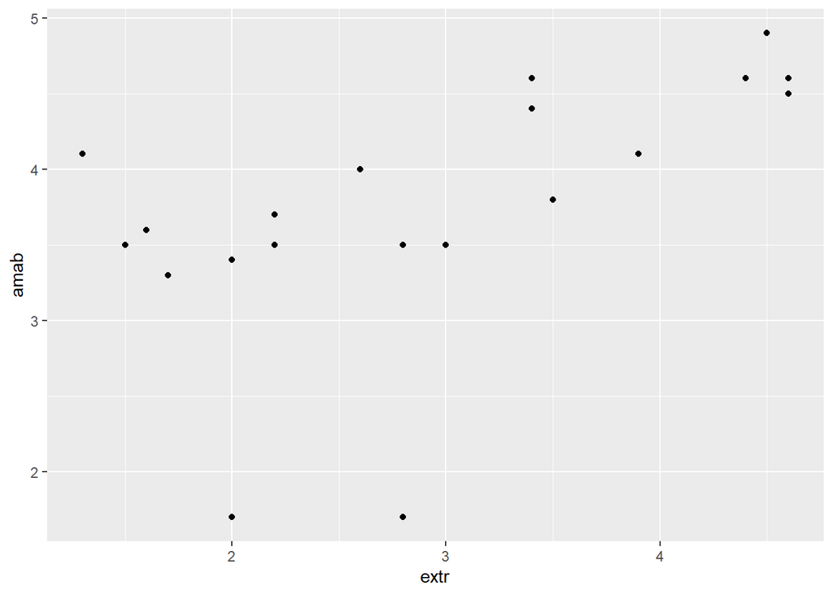

```r
ggplot(data = big_five20) +
    geom_point(aes(x = extr, y = amab))
```

Obs: para uma melhor visualização do gráfico, neste caso, usamos o dataframe `big_five20`, que contém apenas os 20 primeiros casos do dataframe `big_five`.

## Histograma

Um histograma representa a distribuição dos valores em uma variável. No eixo x estão os valores que aparecem na variável sob consideração (no caso, fizemos uma gráfico para cada um dos cinco grandes fatores de personalidade); no eixo y está a frequência com que cada valor de x aparece na amostra. Como o eixo y é sempre a frequencia, no caso do histograma `(geom_histogram`), precisamos definir apenas a variável que entrará no eixo x.

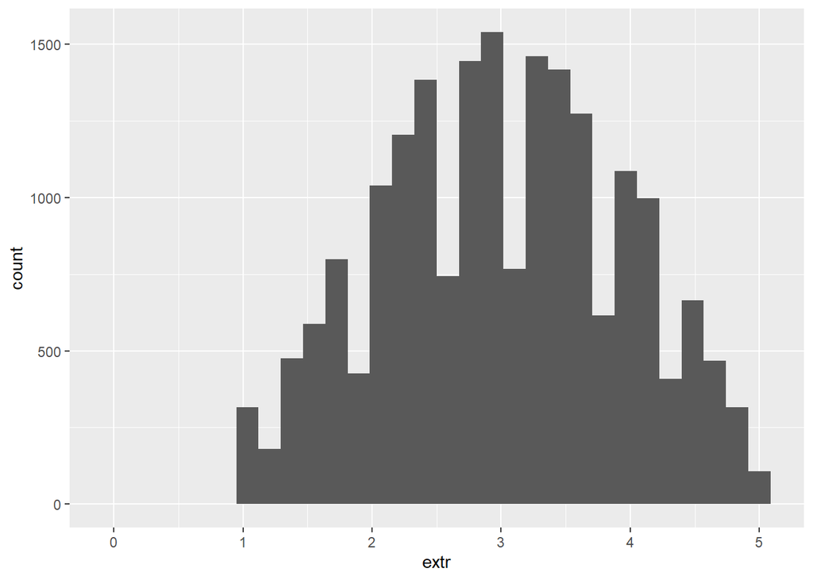

```r
ggplot(data = big_five, aes(x = extr)) +
  geom_histogram()
```

No histograma da variável extroversão, acima, observa-se que há poucos escores baixos (próximos de 1 no eixo x) e altos (próximos de 5 no eixo x) e muitas pessoas com escores ao redor de 3. Note que a distribuição se aproxima de uma distribuição normal. Pode-se aplicar scripts semelhantes para a obtenção de histogramas dos outros quatro fatores.

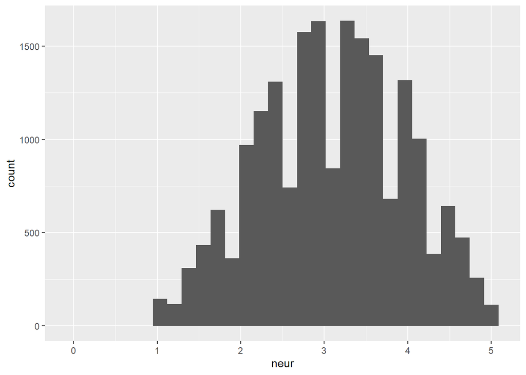

```r
ggplot(data = big_five, aes(x = neur)) +
  geom_histogram()
```

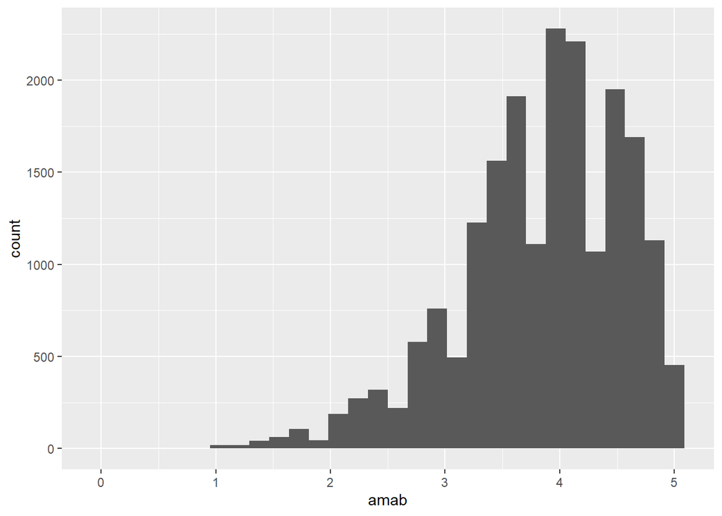

```r
ggplot(data = big_five, aes(x = amab)) +
  geom_histogram()
```

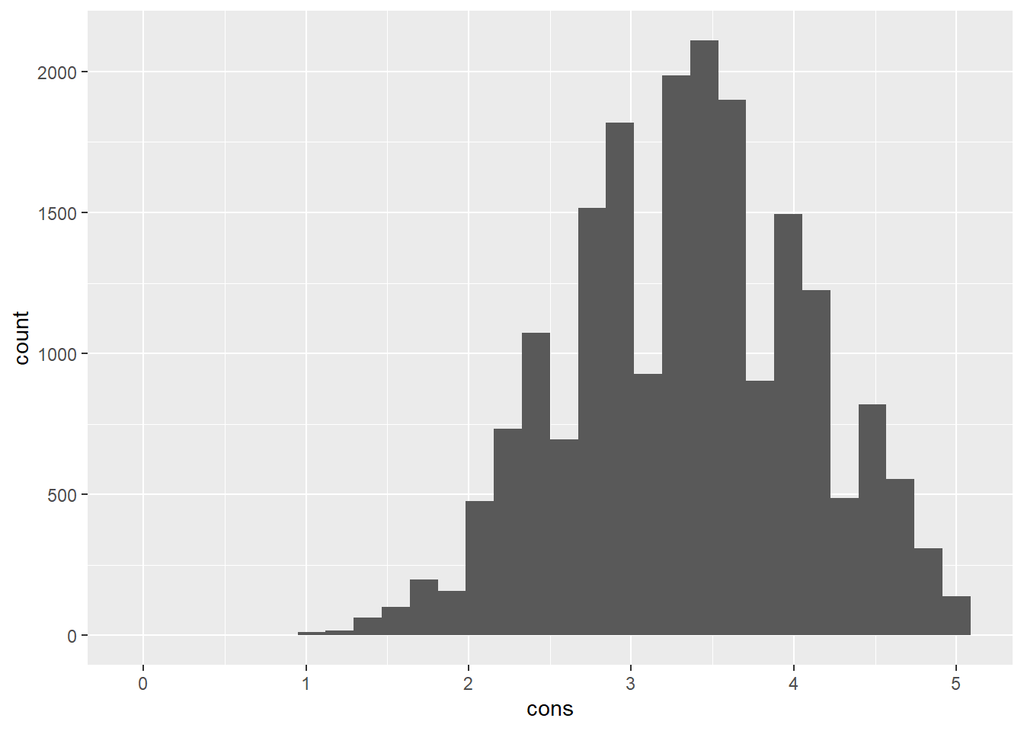

```r
ggplot(data = big_five, aes(x = cons)) +
  geom_histogram()
```

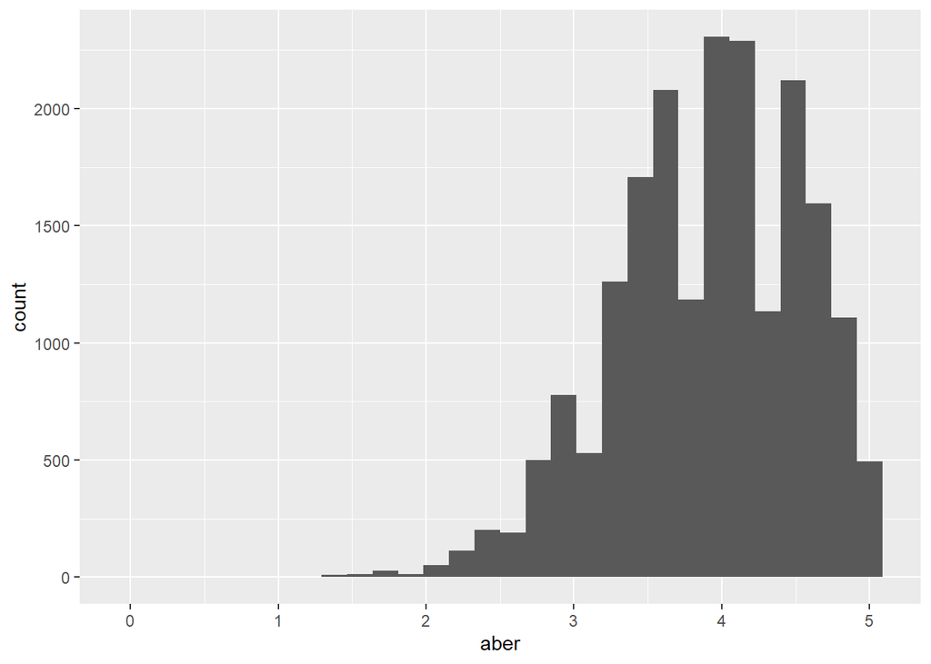

```r
ggplot(data = big_five, aes(x = aber)) +
  geom_histogram()
```

## Gráfico de barras

O gráfico de barras (`geom_bar`) é um gráfico com barras retangulares e comprimento proporcional aos valores que ele apresenta. Nos exemplos abaixo, as barras representam a quantidade de pessoas (`..count..`) por gênero (primeiro gráfico) ou por raça (segundo gráfico)

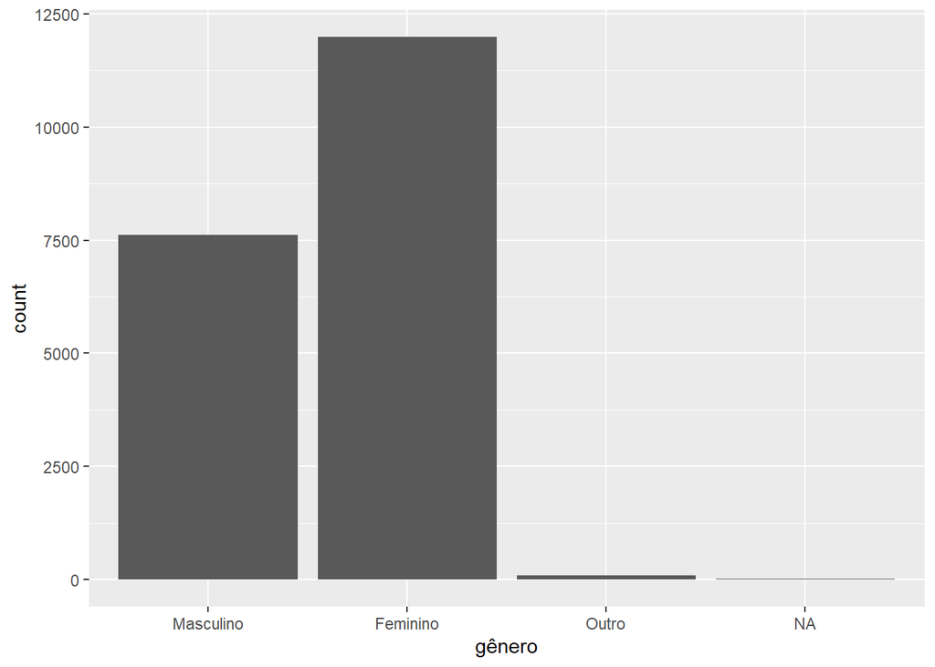

```r
ggplot(data = big_five, aes(x = gênero, y = ..count..)) +
  geom_bar()
```

[figure not shown]

```r
ggplot(data = big_five, aes(x = raça, y = ..count..)) +
  geom_bar()
```

## Boxplot

O boxplot, também chamado de diagrama de caixa é um gráfico que representa a variação de dados por meio de quartis. A haste inferior à caixa representa o primeiro quartil; a caixa representa os quartis 2 e 3, que estão separados pelo traço central correspondente à mediana; e a haste superior à caixa, representa a distribuição dos valores no quarto quartil. Assim, é preciso definir as variáveis que vão em x e y, sendo que y sempre deve ser uma variável contínua.

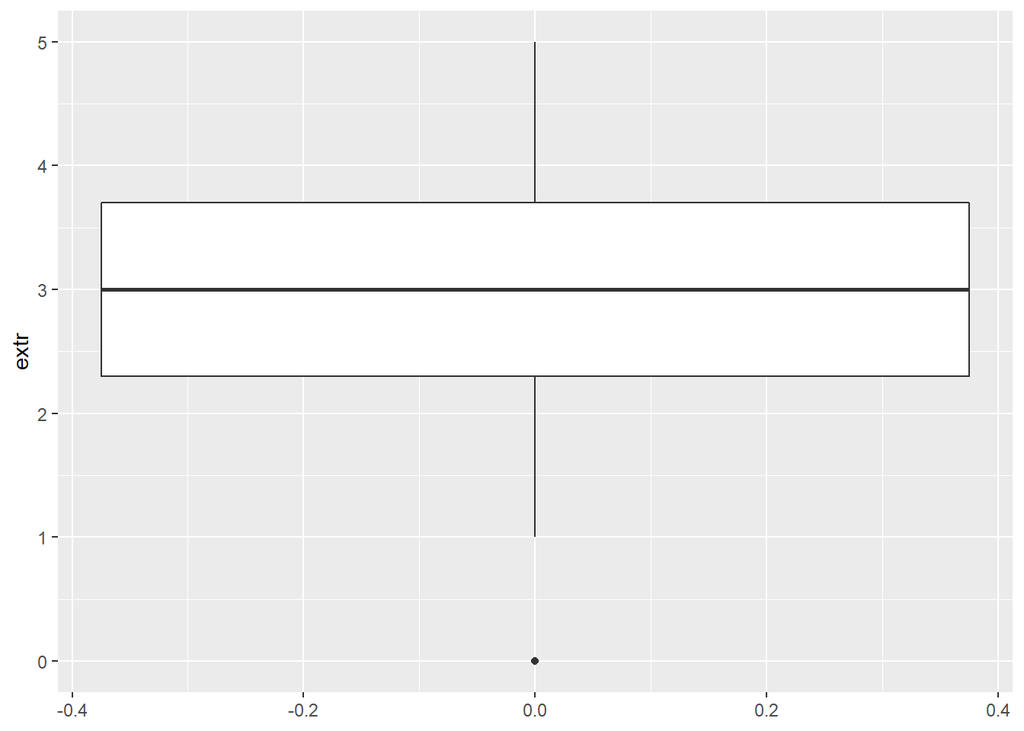

```r
ggplot(data = big_five, aes(y = extr)) +
  geom_boxplot()
```

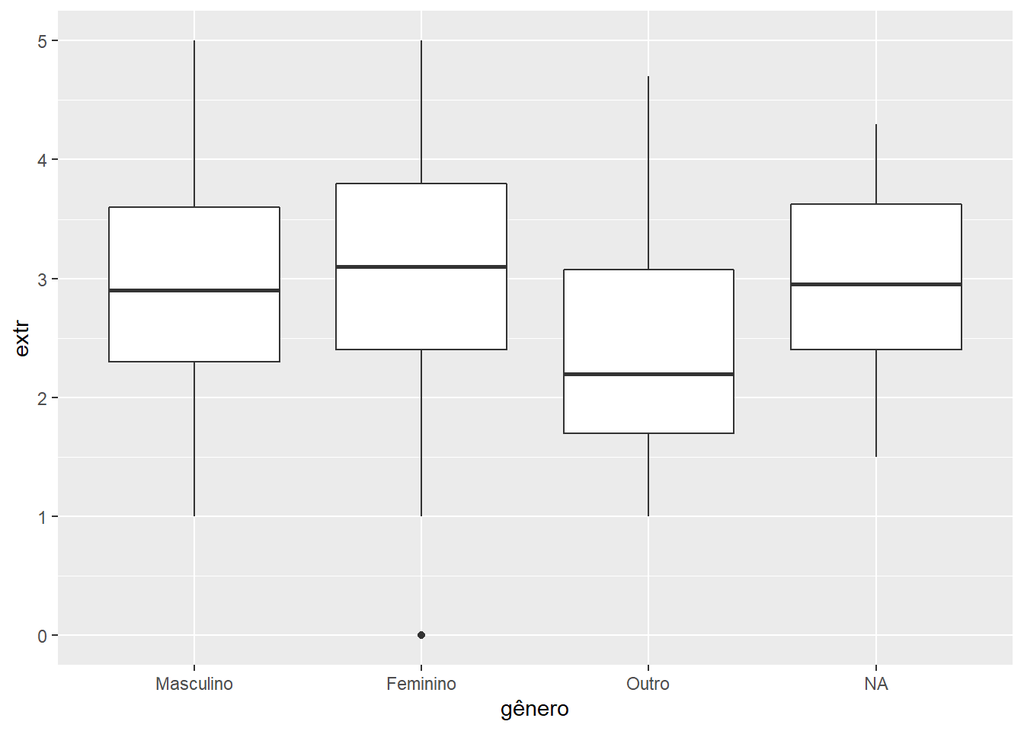

```r
ggplot(data = big_five, aes(x = gênero, y = extr)) +
  geom_boxplot()
```

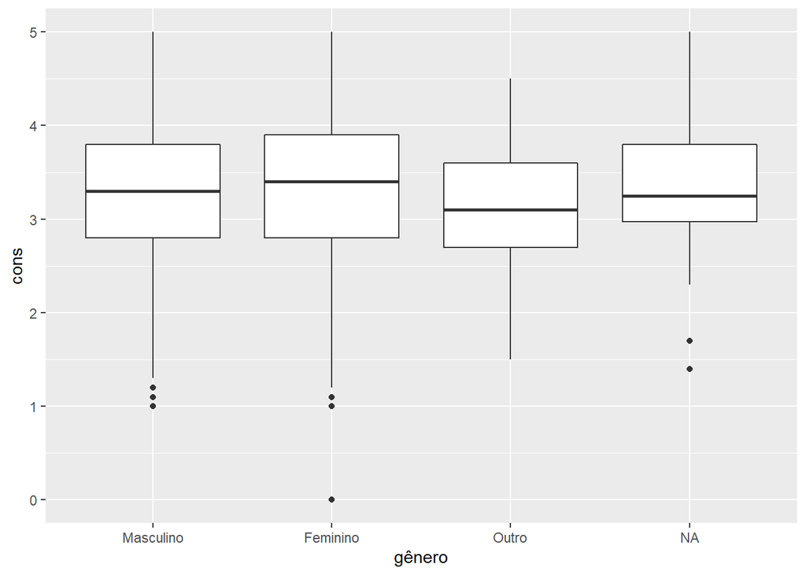

```r
ggplot(data = big_five, aes(x = gênero, y = cons)) +
  geom_boxplot()
```

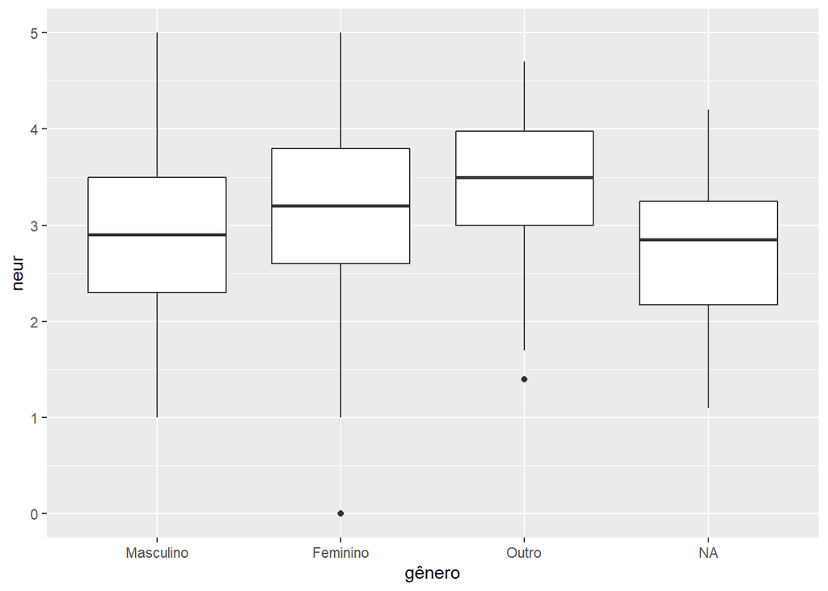

```r
ggplot(data = big_five, aes(x = gênero, y = neur)) +
  geom_boxplot()
```

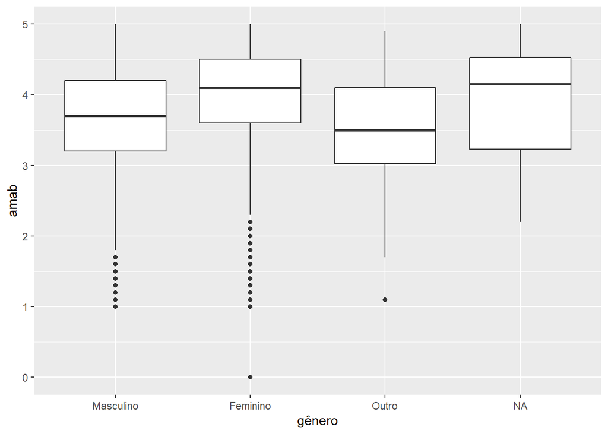

```r
ggplot(data = big_five, aes(x = gênero, y = amab)) +
  geom_boxplot()
```

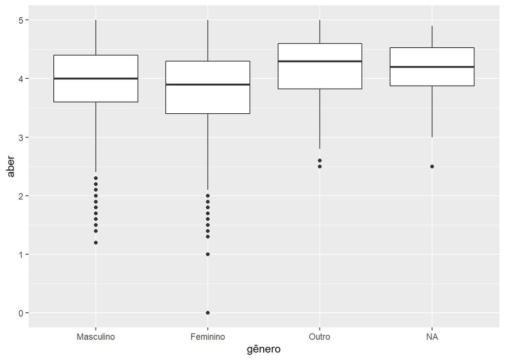

```r
ggplot(data = big_five, aes(x = gênero, y = aber)) +
  geom_boxplot()
```

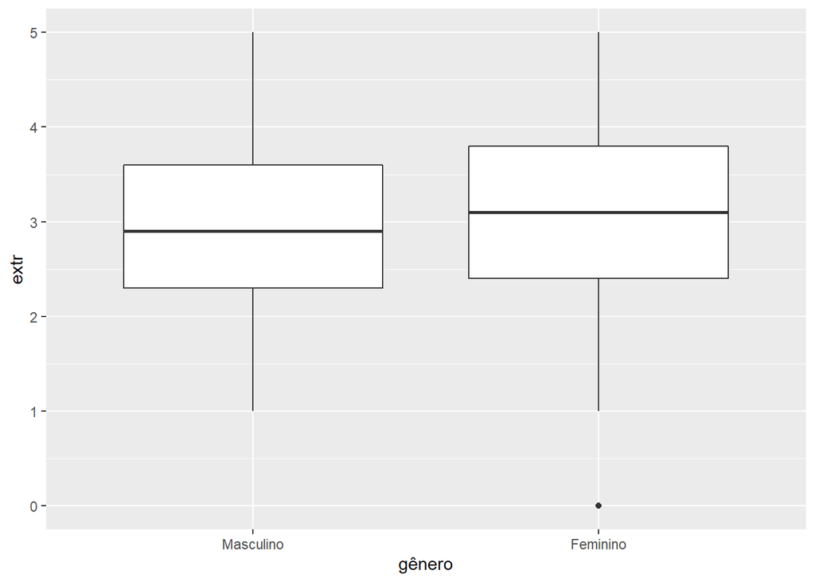

```r
# se quisermos eliminar as categorias "Outro" e "NA", podemos usar...
big_five %>%
  filter(gênero %in% c("Masculino", "Feminino")) %>%
  ggplot(aes(x = gênero, y = extr)) +
  geom_boxplot()
```

## Gráfico de linhas

Se assemelha a um gráfico de pontos, em que os pontos não estão exatamente dispersos em um plano, mas organizados em uma sequência, o que permite que eles sejam ligados por um segmento de reta, facilitando a visualização das variações entre os pontos. No exemplo abaixo, a linha liga a quantidade de pessoas por gênero.

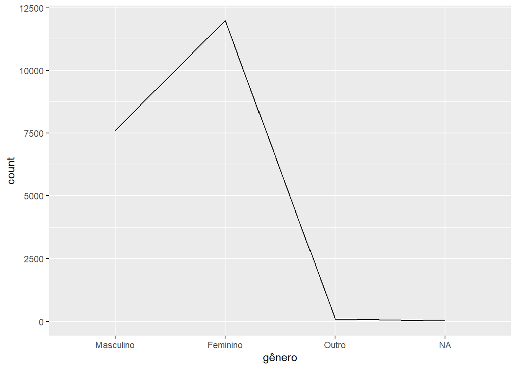

```r
ggplot(data = big_five) +
  geom_line(aes(x = gênero, group = 1), stat = "count")
```

## Modificação de argumentos dentro do geom (color, shape, size)

Uma coisa importante nos gráficos é que eles sejam visualmente atrativos. Para isso, podemos alterar diversos argumentos que os compõem, como cores, formas (shapes) e tamanhos (sizes).

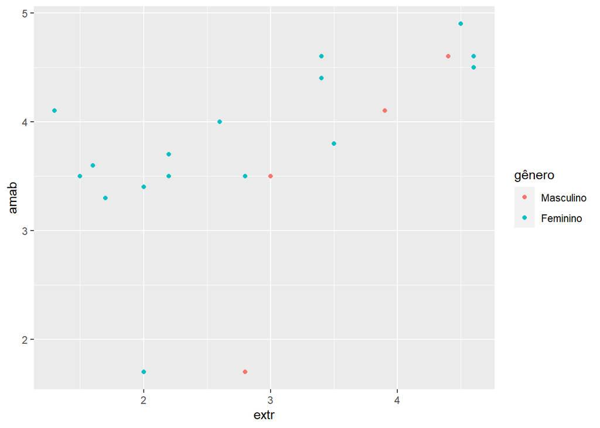

```r
ggplot(data = big_five20) +
  geom_point(aes(x = extr, y = amab, color = gênero))
```

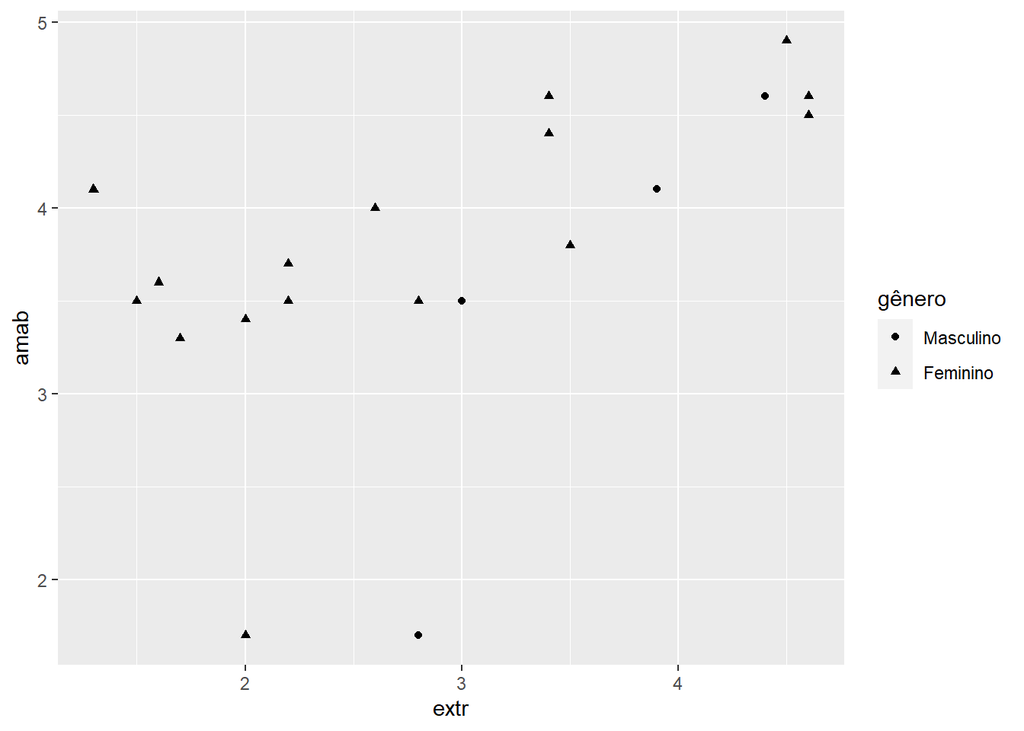

```r
ggplot(data = big_five20) +
  geom_point(aes(x = extr, y = amab, shape = gênero))
```

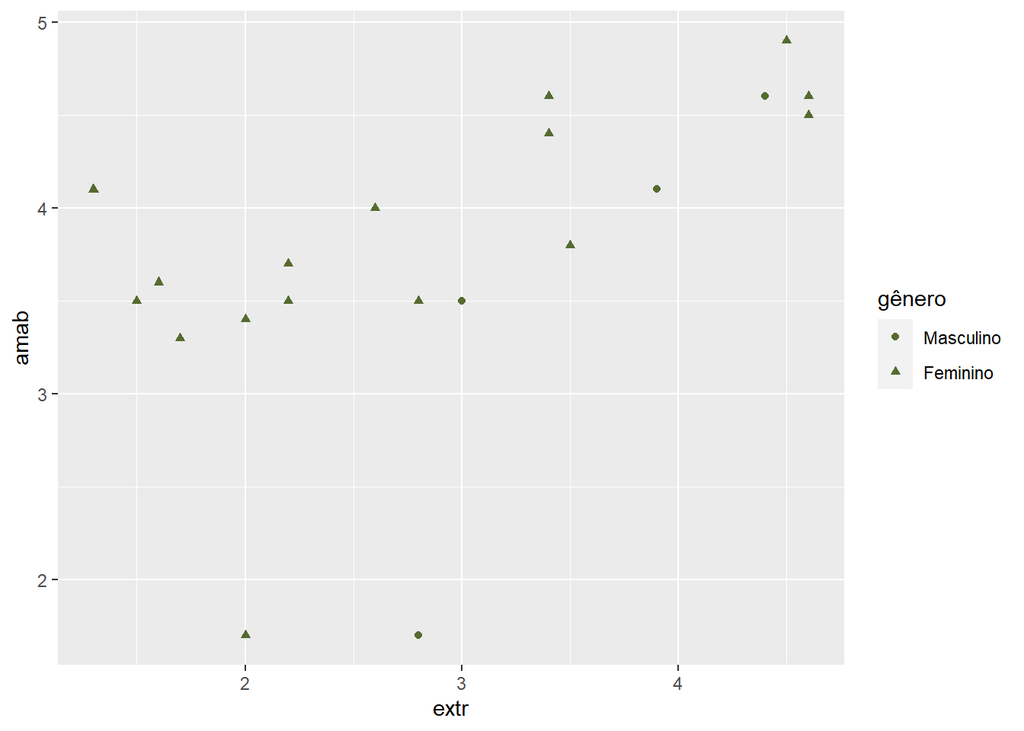

```r
# retirando color de dentro de aes
ggplot(data = big_five20) +
  geom_point(aes(x = extr, y = amab, shape = gênero),
             color = "darkolivegreen")
```

As cores podem ser inseridas pelo seu nome ou pelo seu código. [Clique aqui](http://www.stat.columbia.edu/~tzheng/files/Rcolor.pdf) para baixar um arquivo com os nomes das cores do R… e [aqui](https://coolors.co/) para acessar um site gerador de paletas de cores, por código. Os códigos devem ser inseridos após uma hashtag.

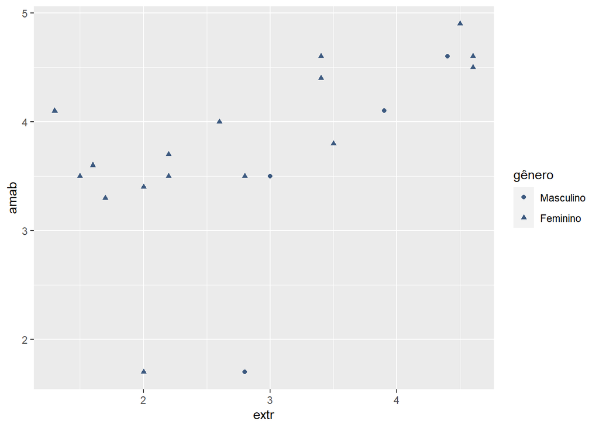

```r
ggplot(data = big_five20) +
  geom_point(aes(x = extr, y = amab, shape = gênero),
             color = "#3d5a80")
```

```r
# Site gerador de paletas: https://coolors.co/
```

Também é possível modificar o formato (shape) dos pontos. [Este site](http://www.sthda.com/english/wiki/ggplot2-point-shapes) tem uma lista dos shapes que podem ser utilizados.

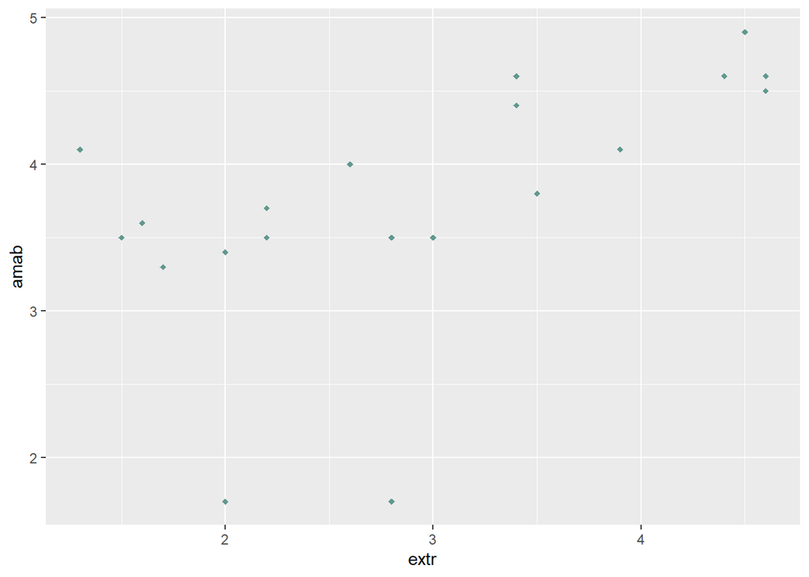

```r
ggplot(data = big_five20) +
  geom_point(aes(x = extr, y = amab),
             color = "#61988E", shape = 18)
```

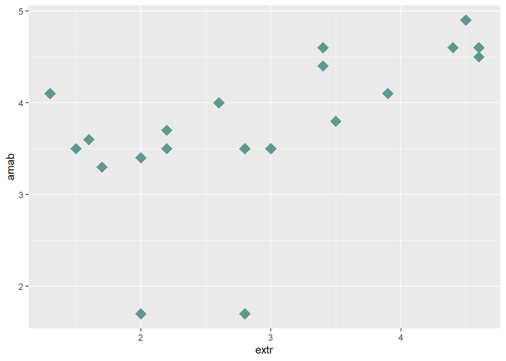

```r
# Shapes possíveis: http://www.sthda.com/english/wiki/ggplot2-point-shapes

ggplot(data = big_five20) +
  geom_point(aes(x = extr, y = amab),
             color = "#61988E", shape = 18, size = 5)
```

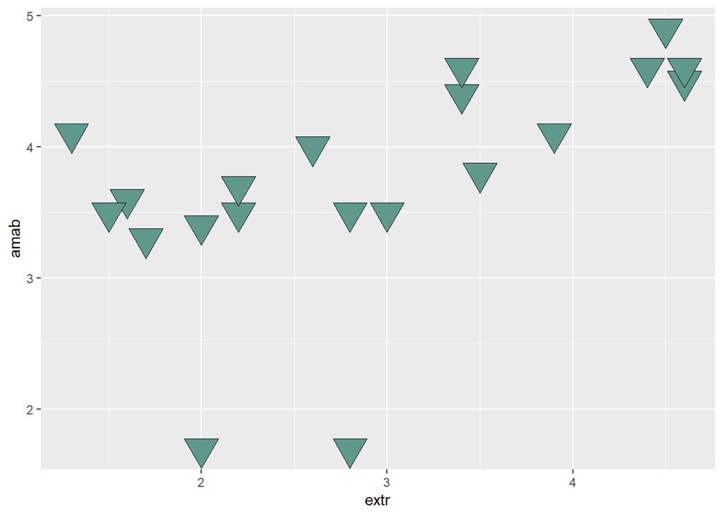

```r
# é possível ajustar a borda (color) e o preenchimento dos pontos (fill)
# nesse site, os shapes de 21 a 25 permitem ajuste de color e fill
ggplot(data = big_five20) +
  geom_point(aes(x = extr, y = amab),
             fill = "#61988E", color = "black", shape = 25, size = 8)
```

## Adicionando um segundo geom

Como foi dito anteriormente, o ggplot segue o principio de camadas sobrepostas. Portanto, é possível adicionar várias camadas, como outro geom, por exemplo.

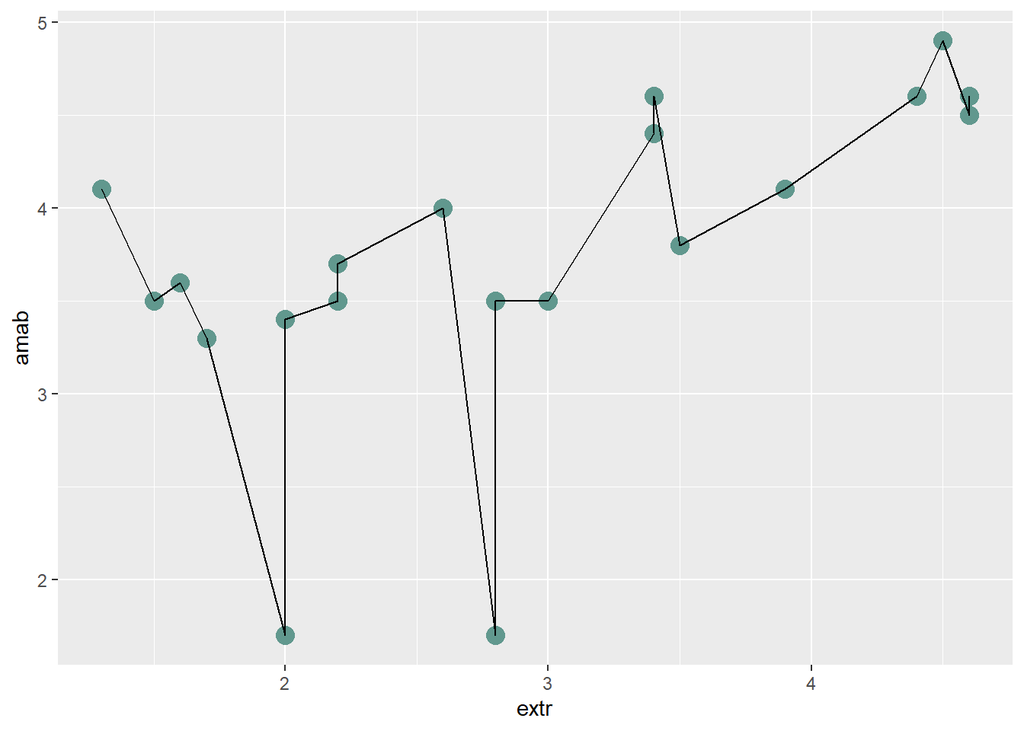

```r
#ggplot(data = big_five20) +
#  geom_point(aes(x = extr, y = amab),
#             color = "#61988E", shape = 16, size = 2) +
#  geom_line(aes(x = extr, y = amab), stat = "smooth",
#            method = "lm")

ggplot(data = big_five20, aes(x = extr, y = amab)) +
  geom_point(color = "#61988E", shape = 16, size = 4) +
  geom_line()
```

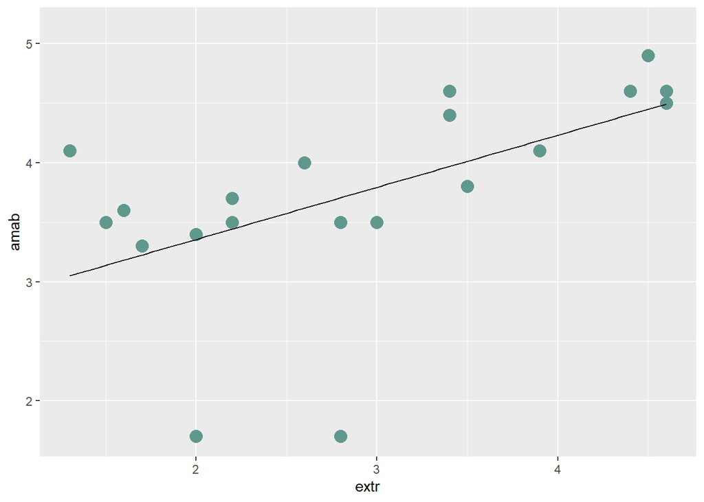

```r
ggplot(data = big_five20, aes(x = extr, y = amab)) +
  geom_point(color = "#61988E", shape = 16, size = 4) +
  geom_line(stat = "smooth", method = "lm")
```

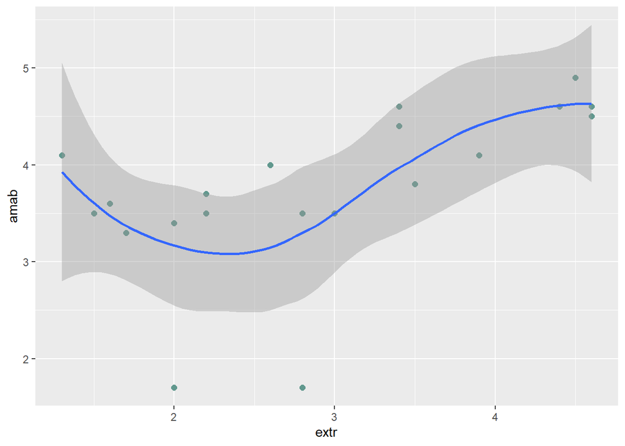

```r
# alterando o tipo de curva de interpolação dos pontos

ggplot(data = big_five20, aes(x = extr, y = amab)) +
  geom_point(color = "#61988E", shape = 16, size = 2) +
  geom_smooth()
```

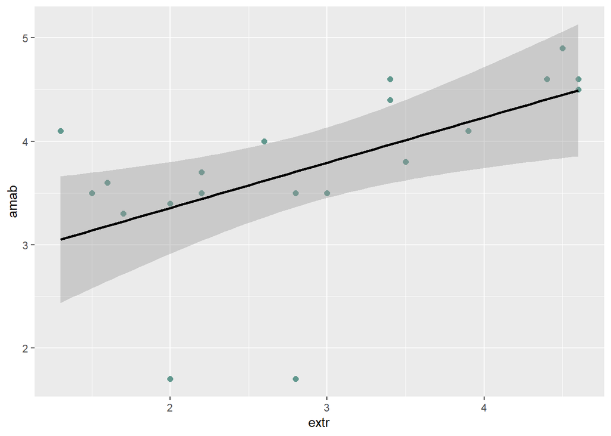

```r
ggplot(data = big_five20, aes(x = extr, y = amab)) +
  geom_point(color = "#61988E", shape = 16, size = 2) +
  geom_smooth(method = "lm", se = TRUE, color = "black", size = 1)
```

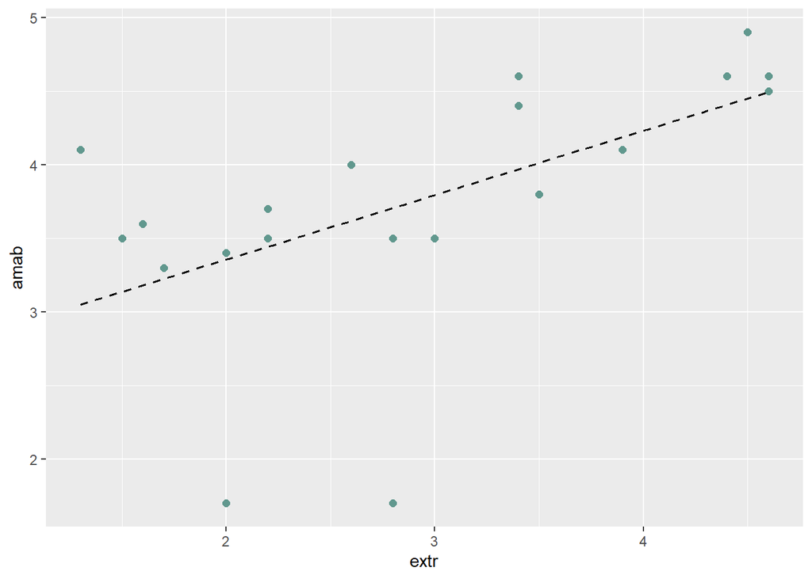

```r
# Mudando o tipo de linha
ggplot(data = big_five20, aes(x = extr, y = amab)) +
  geom_point(color = "#61988E", shape = 16, size = 2) +
  geom_smooth(method = "lm", se = F, color = "black", size = 0.7,
              linetype = "dashed")
```

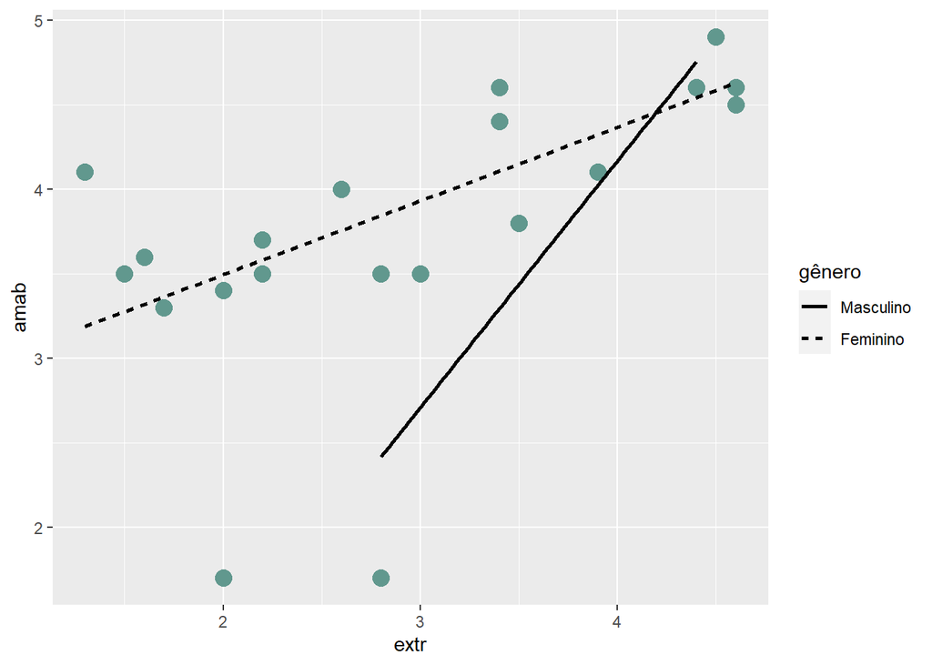

```r
## Especificando aes específicas para um dos geoms
ggplot(data = big_five20, aes(x = extr, y = amab)) +
  geom_point(color = "#61988E", shape = 16, size = 4) +
  geom_smooth(method = "lm", se = F, color = "black", size = 1,
              aes(linetype = gênero))
```

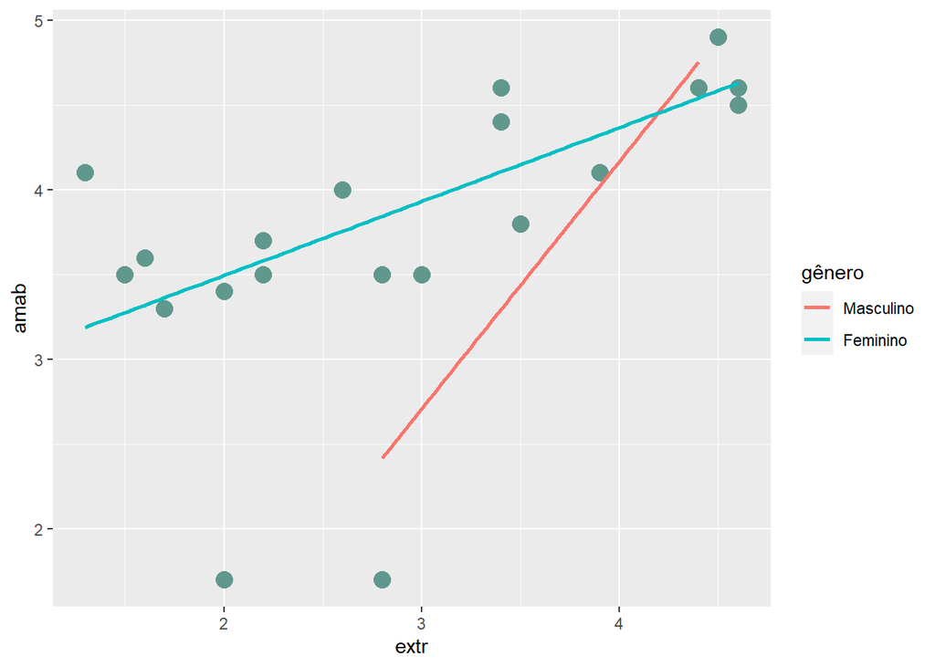

```r
## Especificando aes específicas para um dos geoms
ggplot(data = big_five20, aes(x = extr, y = amab)) +
  geom_point(color = "#61988E", shape = 16, size = 4) +
  geom_smooth(method = "lm", se = F, size = 1,
              aes(color = gênero))
```

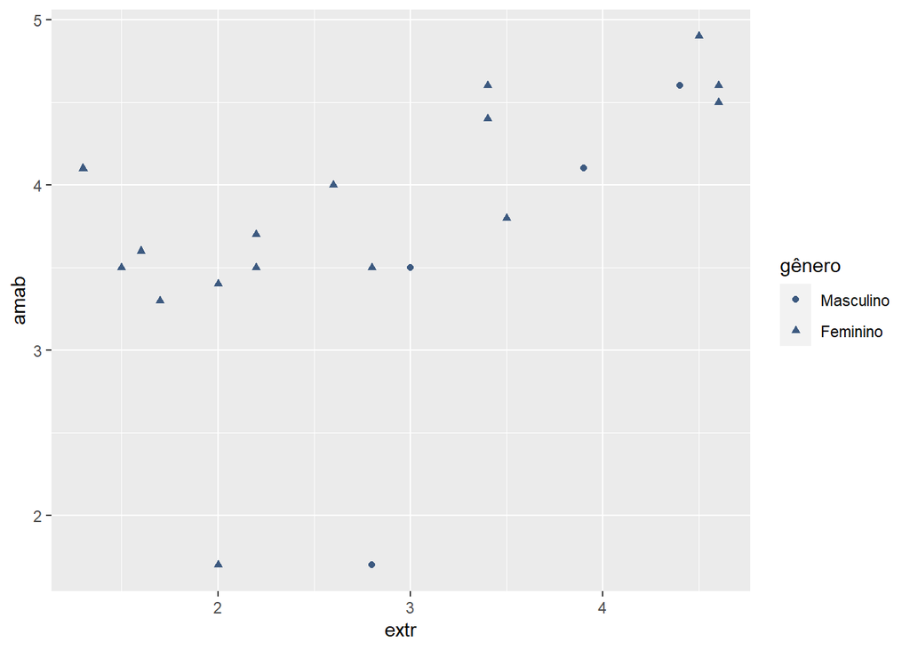

```r
ggplot(data = big_five20) +
  geom_point(aes(x = extr, y = amab, shape = gênero),
             color = "#3d5a80")
```

## dplyr e ggplot

Uma opção interessante para a elaboração de gráficos é combinar funções do dplyr com as do ggplot. Por exemplo, ao invés de criar um dataframe com 20 sujeitos, como estávamos fazendo até aqui, podemos selecionar a quantidade de sujeitos desejada por meio da função slice.

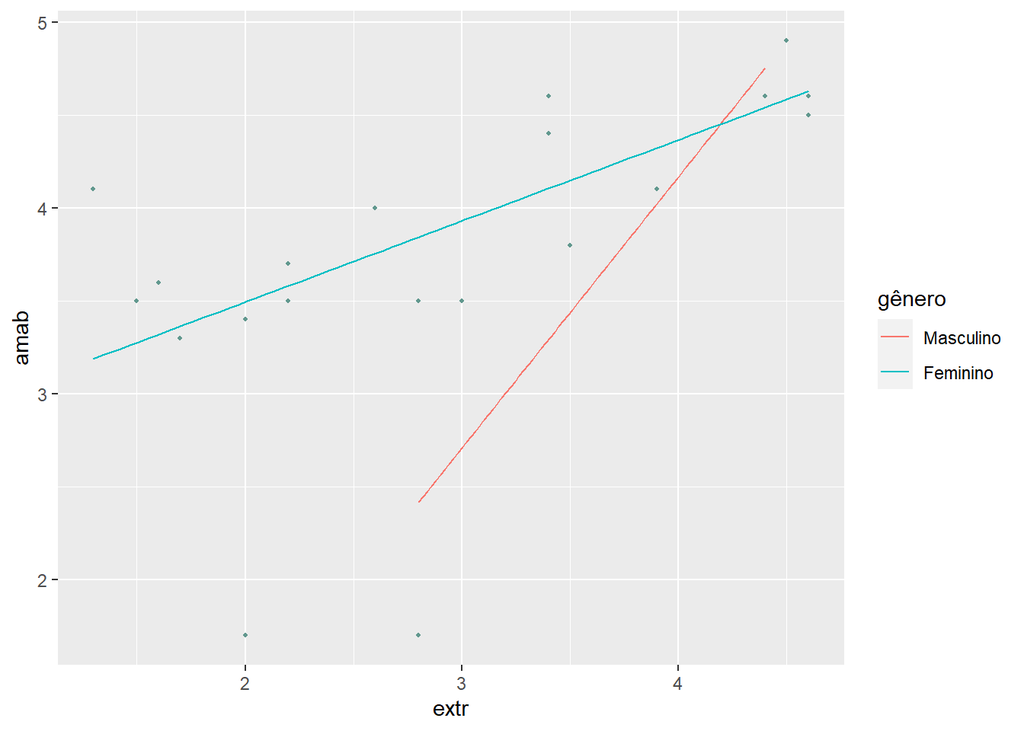

```r
# repetindo o último gráfico, mas combinando dplyr com ggplot
big_five %>% slice(1:20) %>%
ggplot(aes(x = extr, y = amab)) +
  geom_point(color = "#61988E", shape = 16, size = 0.7) +
  geom_smooth(method = "lm", se = F, size = 0.5,
              aes(color = gênero))
```

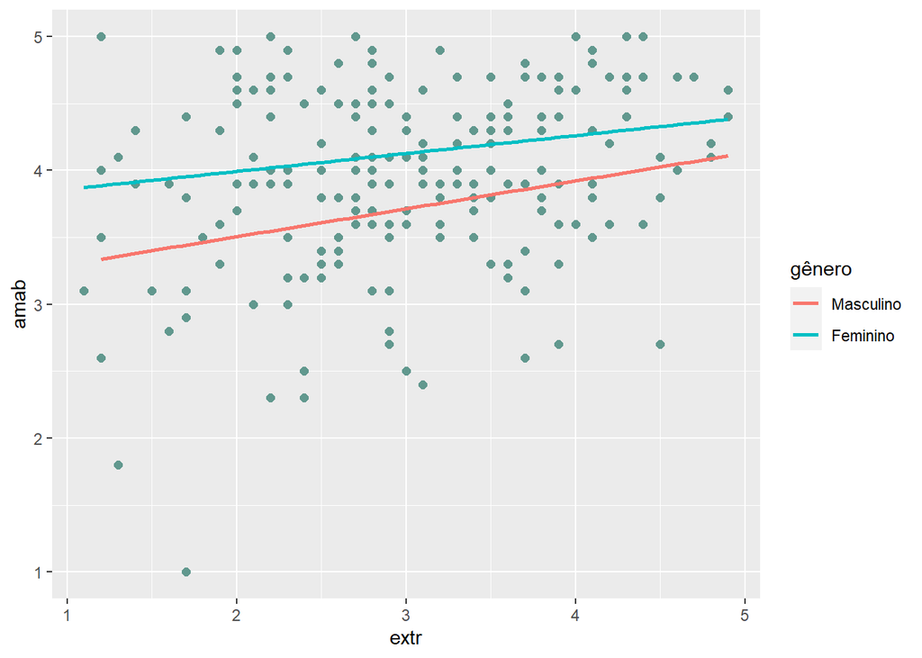

```r
# ou, se quisermos fazer o mesmo gráfico com 1% da amostra
big_five %>% slice_sample(prop = .01) %>%
  ggplot(aes(x = extr, y = amab)) +
  geom_point(color = "#61988E", shape = 16, size = 2) +
  geom_smooth(method = "lm", se = F, size = 1,na.rm = TRUE,
              aes(color = gênero))
```

## Usando funções estatísticas

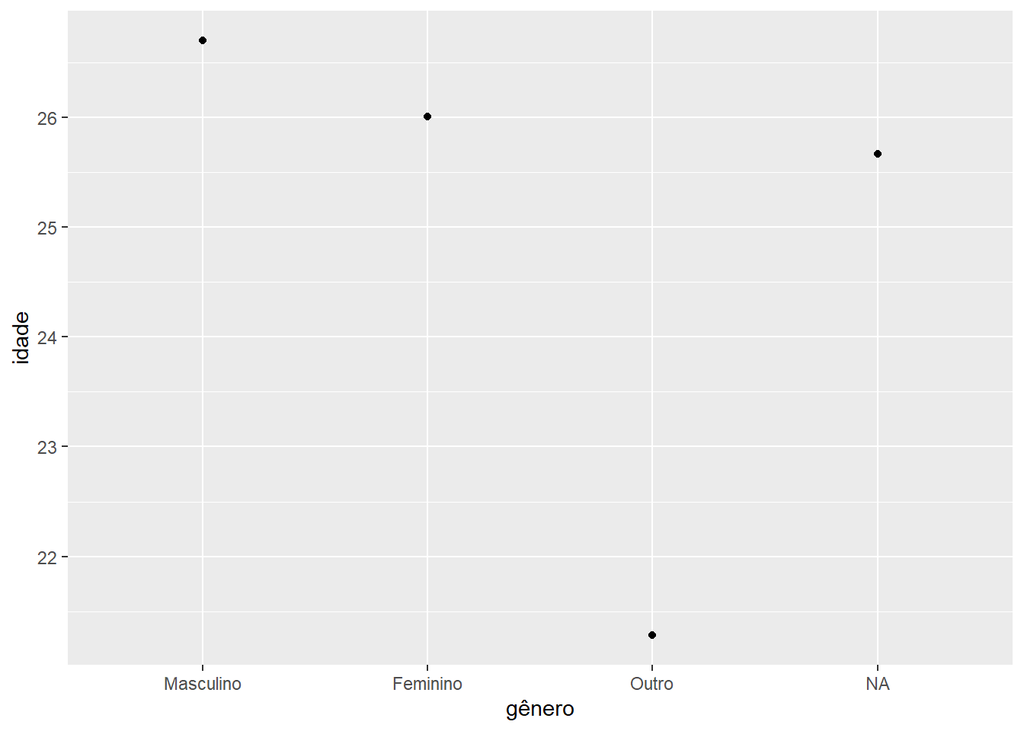

```r
## Usando o geom para representar um "summary"
### (stat = summary) x stat_summary()

big_five %>% filter(idade <= 80) %>% # tem idades erradas no banco
ggplot() +
  geom_point(aes(x = gênero, y = idade), stat = "summary", fun = "mean")
```

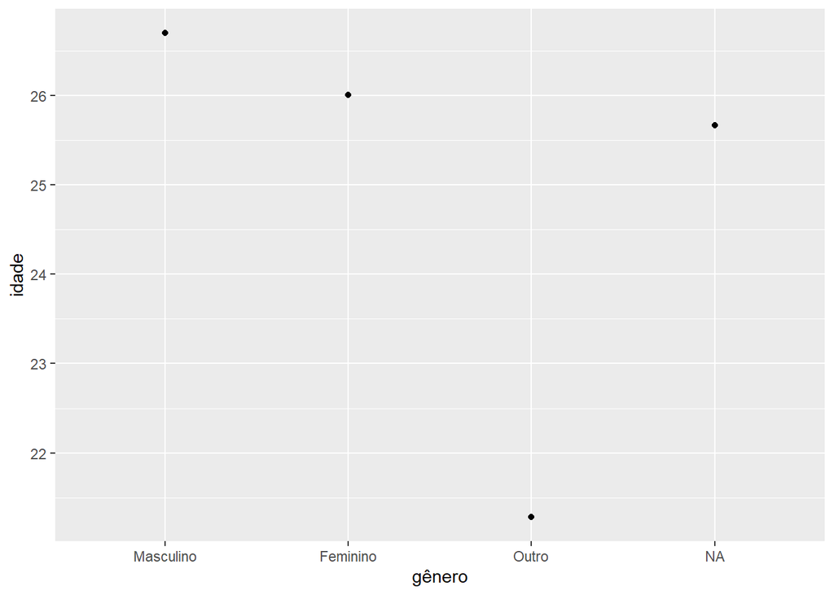

```r
# mesmo gráfico que o anterior, mas usando a função stat_summary
big_five %>% filter(idade <= 80) %>%
ggplot(aes(x = gênero, y = idade)) +
  stat_summary(geom = "point", fun = "mean")
```

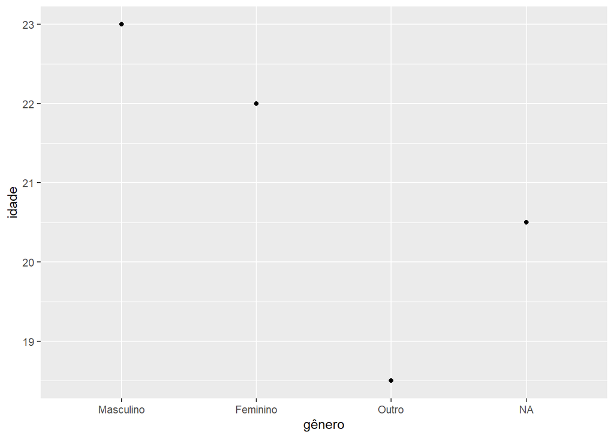

```r
# usando a mediana no lugar da média.
big_five %>% filter(idade <= 80) %>%
ggplot(aes(x = gênero, y = idade)) +
  stat_summary(geom = "point", fun = "median")
```

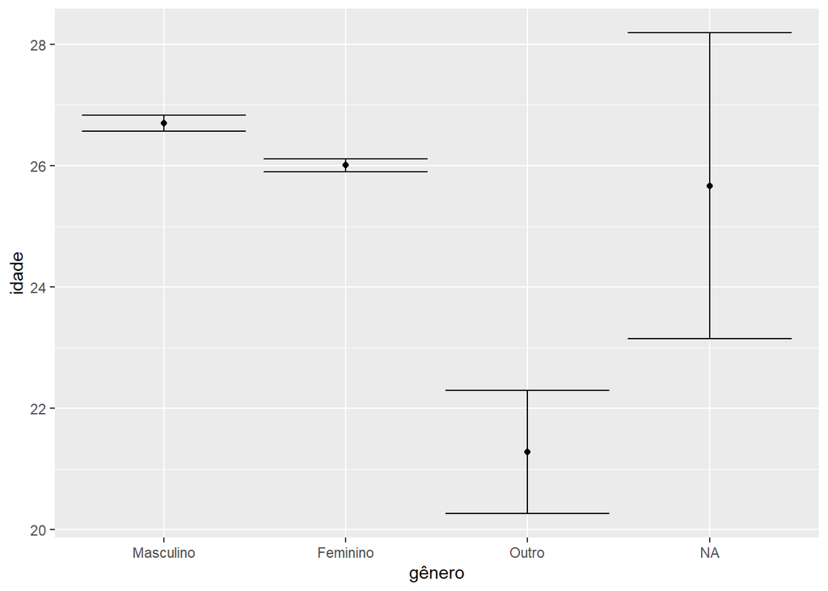

```r
## Incluindo barras de erros (usando também o summary)

big_five %>% filter(idade <= 80) %>%
ggplot(aes(x = gênero, y = idade)) +
  geom_point(stat = "summary", fun = "mean") +
  geom_errorbar(stat = "summary", fun.data = "mean_se")
```

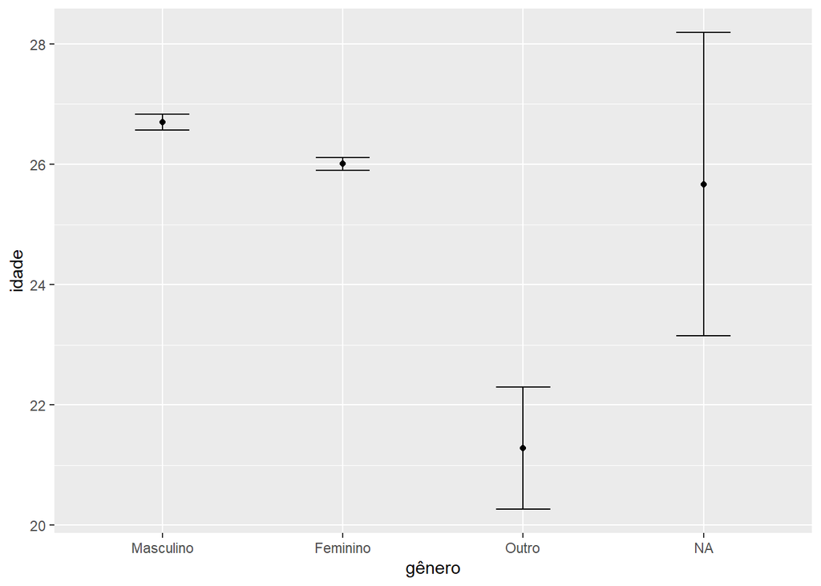

```r
# usando width para melhorar a visualiazação

big_five %>% filter(idade <= 80) %>%
ggplot(aes(x = gênero, y = idade)) +
  geom_point(stat = "summary", fun = "mean") +
  geom_errorbar(stat = "summary", fun.data = "mean_se", width = 0.3)
```

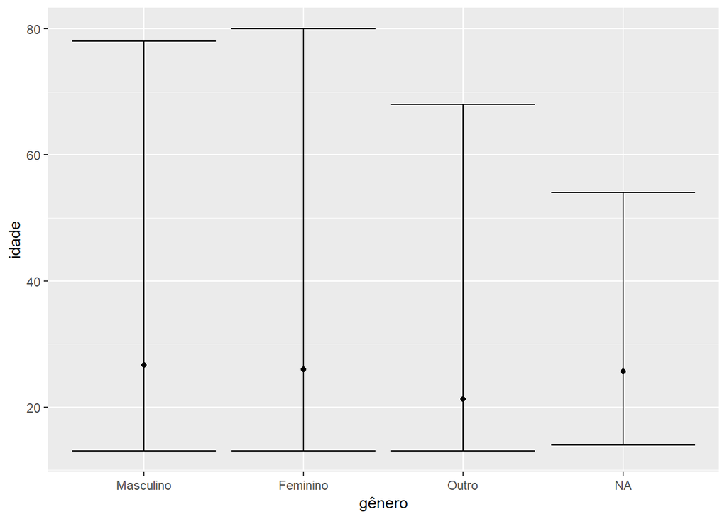

```r
# trocando erro da média (mean_se) pelo mínimo e máximo.

big_five %>% filter(idade <= 80) %>%
ggplot(aes(x = gênero, y = idade)) +
  geom_point(stat = "summary", fun = "mean") +
  geom_errorbar(stat = "summary", fun.min = "min", fun.max = "max")
```

# Exercícios (Final)

Para realizar esse exercício, baixe o arquivo [olympics](https://github.com/jmhbueno/IntroR_aula/blob/3cac933adad5c2e4b5b07972b408157b72bd7c58/olympics.rds) e salve-o no seu diretório de trabalho. Em seguida importe-o para dentro do R usando o comando `readRDS()`.

1. Baixe o arquivo [countries&continents.csv](https://docs.google.com/spreadsheets/d/1iqZcTBXF5TO5dlXTY9inRvNCB53ORlN6NfhRg3iLXoA/edit?usp=sharing) e importe-o para dentro do R como um dataframe chamado `country_cont`. Esse dataframe contém duas colunas que relacionam os **países** aos seus respectivos **continentes**. A tarefa é combinar os dois dataframes (`olympics` e `country_cont`) de modo que o novo aquivo contenha todas as informações que já estavam em `olympics` mais a coluna referente aos continentes.

```r
country_cont <- read.csv("countries&continents.csv", encoding = "UTF-8")
olympics <- left_join(olympics,country_cont,by = c(countries = "X.U.FEFF.country"))

nrow(olympics)
```

```
## [1] 156
```

```r
glimpse(olympics)
```

```
## Rows: 156
## Columns: 18
## $ countries             <chr> "Afghanistan", "Algeria", "Argentina", "Armenia"~
## $ ioc_code              <chr> "AFG", "ALG", "ARG", "ARM", "ANZ", "AUS", "AUT",~
## $ summer_participations <int> 15, 14, 25, 7, 2, 27, 28, 7, 17, 10, 13, 7, 27, ~
## $ summer_gold           <int> 0, 5, 21, 2, 3, 164, 20, 7, 8, 2, 0, 13, 44, 1, ~
## $ summer_silver         <int> 0, 4, 26, 8, 4, 173, 35, 14, 2, 2, 0, 30, 56, 0,~
## $ summer_bronze         <int> 2, 8, 30, 8, 5, 210, 41, 28, 6, 0, 1, 42, 57, 1,~
## $ summer_total          <int> 2, 17, 77, 18, 12, 547, 96, 49, 16, 4, 1, 85, 15~
## $ winter_participations <int> 0, 3, 20, 8, 0, 20, 24, 7, 0, 0, 0, 8, 22, 8, 0,~
## $ winter_gold           <int> 0, 0, 0, 0, 0, 6, 71, 0, 0, 0, 0, 8, 2, 0, 0, 0,~
## $ winter_silver         <int> 0, 0, 0, 0, 0, 7, 88, 0, 0, 0, 0, 7, 2, 0, 0, 0,~
## $ winter_bronze         <int> 0, 0, 0, 0, 0, 6, 91, 0, 0, 0, 0, 5, 4, 0, 0, 0,~
## $ winter_total          <int> 0, 0, 0, 0, 0, 19, 250, 0, 0, 0, 0, 20, 8, 0, 0,~
## $ total_participation   <int> 15, 17, 45, 15, 2, 47, 52, 14, 17, 10, 13, 15, 4~
## $ total_gold            <int> 0, 5, 21, 2, 3, 170, 91, 7, 8, 2, 0, 21, 46, 1, ~
## $ total_silver          <int> 0, 4, 26, 8, 4, 180, 123, 14, 2, 2, 0, 37, 58, 0~
## $ total_bronze          <int> 2, 8, 30, 8, 5, 216, 132, 28, 6, 0, 1, 47, 61, 1~
## $ total_total           <int> 2, 17, 77, 18, 12, 566, 346, 49, 16, 4, 1, 105, ~
## $ continent             <chr> "Asia", "Africa", "South America", "Asia", NA, "~
```

2. Altere a posição das colunas para o continente fique na terceira coluna, após as colunas `country` e `ioc_code`. Mantenha as demais colunas na ordem em que estão.

```r
olympics <- olympics %>% select(countries, ioc_code, continent, everything())
names(olympics)
```

```
##  [1] "countries"             "ioc_code"              "continent"
##  [4] "summer_participations" "summer_gold"           "summer_silver"
##  [7] "summer_bronze"         "summer_total"          "winter_participations"
## [10] "winter_gold"           "winter_silver"         "winter_bronze"
## [13] "winter_total"          "total_participation"   "total_gold"
## [16] "total_silver"          "total_bronze"          "total_total"
```

3. Monte um dataframe chamado “medals_table” com seis colunas contendo os nomes dos 10 países que mais ganharam medalhas de ouro, de prata e de bronze nos jogos olímpicos de verão e suas respectivas quantidades.

```r
data.frame(
olympics %>% arrange(desc(summer_gold)) %>% select(countries,summer_gold) %>% slice(1:10),
olympics %>% arrange(desc(summer_silver)) %>% select(countries,summer_silver) %>% slice(1:10),
olympics %>% arrange(desc(summer_bronze)) %>% select(countries,summer_bronze) %>% slice(1:10))
```

```
##        countries summer_gold   countries.1 summer_silver   countries.2
## 1  United States        1060 United States           831 United States
## 2   Soviet Union         395  Soviet Union           319 Great Britain
## 3  Great Britain         284 Great Britain           318  Soviet Union
## 4          China         262        France           251        France
## 5         France         223       Germany           207       Germany
## 6          Italy         217         China           199         Italy
## 7        Germany         201         Italy           188     Australia
## 8        Hungary         181        Sweden           176        Sweden
## 9          Japan         169     Australia           173         Japan
## 10     Australia         164       Hungary           154       Hungary
##    summer_bronze
## 1            738
## 2            314
## 3            296
## 4            277
## 5            247
## 6            213
## 7            210
## 8            179
## 9            178
## 10           176
```

4. Identificar quais os países que ficaram sem indicação de continente e inserir o respectivo continente. Deixar como NA os casos em que os atletas disputaram sob bandeira do comitê olímpico internacional ou algo similar.

```r
olympics %>% filter(is.na(continent)) %>% select(countries,continent)
```

```
##                            countries continent
## 1                        Australasia      <NA>
## 2                            Bohemia      <NA>
## 3                British West Indies      <NA>
## 4                     Czechoslovakia      <NA>
## 5             United Team of Germany      <NA>
## 6                       East Germany      <NA>
## 7                       West Germany      <NA>
## 8                      Great Britain      <NA>
## 9                             Kosovo      <NA>
## 10              Netherlands Antilles      <NA>
## 11                    Russian Empire      <NA>
## 12                      Soviet Union      <NA>
## 13                      Unified Team      <NA>
## 14      Olympic Athletes from Russia      <NA>
## 15                              ROC       <NA>
## 16             Serbia and Montenegro      <NA>
## 17                    Chinese Taipei      <NA>
## 18                    Virgin Islands      <NA>
## 19                        Yugoslavia      <NA>
## 20      Independent Olympic Athletes      <NA>
## 21 Independent Olympic Participants       <NA>
## 22                       Mixed Team       <NA>
```

```r
# olympics1 <- olympics

olympics$continent[olympics$countries == "Australasia"] <- "Oceania"
olympics$continent[olympics$countries == "Bohemia"] <- "Europe"
olympics$continent[olympics$countries == "British West Indies"] <- "Asia"
olympics$continent[olympics$countries == "Czechoslovakia"] <- "Europe"
olympics$continent[olympics$countries == "United Team of Germany"] <- "Europe"
olympics$continent[olympics$countries == "East Germany"] <- "Europe"
olympics$continent[olympics$countries == "West Germany"] <- "Europe"
olympics$continent[olympics$countries == "Great Britain"] <- "Europe"
olympics$continent[olympics$countries == "Kosovo"] <- "Europe"
olympics$continent[olympics$countries == "Netherlands Antilles"] <- "South America"
olympics$continent[olympics$countries == "Russian Empire"] <- "Asia"
olympics$continent[olympics$countries == "Soviet Union"] <- "Asia"
olympics$continent[olympics$countries == "Serbia and Montenegro"] <- "Europe"
olympics$continent[olympics$countries == "Chinese Taipei"] <- "Asia"
olympics$continent[olympics$countries == "Virgin Islands"] <- "North America"
olympics$continent[olympics$countries == "Yugoslavia"] <- "Europe"
olympics$continent[olympics$countries == "Olympic Athletes from Russia"] <- "Asia"
```

5. Selecione os países da América do Sul que constam no dataframe e organize por número de participações em jogos olímpicos de verão

```r
names(olympics)
```

```
##  [1] "countries"             "ioc_code"              "continent"
##  [4] "summer_participations" "summer_gold"           "summer_silver"
##  [7] "summer_bronze"         "summer_total"          "winter_participations"
## [10] "winter_gold"           "winter_silver"         "winter_bronze"
## [13] "winter_total"          "total_participation"   "total_gold"
## [16] "total_silver"          "total_bronze"          "total_total"
```

```r
olympics %>% filter(continent == "South America") %>% select(countries, summer_participations) %>% arrange(desc(summer_participations))
```

```
##               countries summer_participations
## 1             Argentina                    25
## 2                 Chile                    24
## 3                Brazil                    23
## 4               Uruguay                    22
## 5              Colombia                    20
## 6                  Peru                    19
## 7             Venezuela                    19
## 8                Guyana                    18
## 9               Ecuador                    15
## 10 Netherlands Antilles                    13
## 11             Paraguay                    13
## 12             Suriname                    13
```

6. Construa um gráfico de barras que informe o número de participações por continente

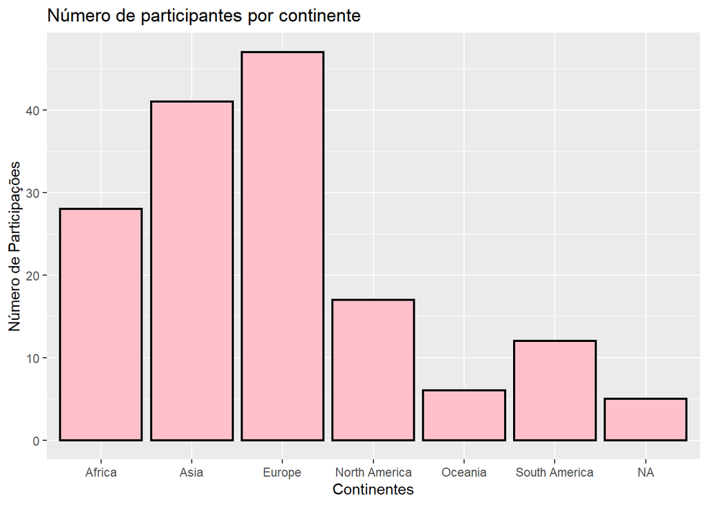

```r
ggplot(data = olympics, aes(x = continent, y = ..count..)) +
  geom_bar(color = "black", fill = "pink", size = .8) +
  labs(x = "Continentes",
       y = "Número de Participações",
       title = "Número de participantes por continente")
```